# Grays Harbor Recreational Crab Harvest Estimate

Gear-Resolved CPUE Model (cross-check) - 2024-25 Season (2024-09-16 to 2025-09-15)

Washington Department of Fish and Wildlife

2026-10-19

> **How to read this report.** This is the results report for one seasonal harvest estimate from the gear-resolved CPUE model. Code is hidden by default; use the **Code** buttons (or *Code > Show All Code* at the top right) to reveal any step. Each section states what it does, shows the notable tables and figures, and, for the diagnostic sections, notes what a healthy run should look like. The headline number is the port total in the Results section; always read it together with the convergence and PE-vs-BSS sections, which say how much to trust it. This model is the independent cross-check on the pooled CPUE model; the two should agree on the boat and the port total.

## 1. Setup, configuration, and inputs

Loads packages, sources the helper functions in `03_R_functions/`, applies the run configuration from `run_config.R` (the single file of user toggles), builds the pot-closure sub-seasons, defines the PE / BSS / census estimators, and reads the season effort counts, crabber interviews, commercial tally, and ingress/egress surveys. Nothing here is a result; it is the machinery every later section uses.

```r
###############################################################################
# Crab Creel Estimation - Westport / Grays Harbor  |  Gear-Resolved CPUE Model
# Framework v6.0 (2026-09-12)  |  the season(s) run_config.R selects
#
# Estimates total recreational Dungeness crab harvest at Westport / Grays Harbor
# with a per-gear-type CPUE process (shared AR(1) dynamics), so gear-type catch can
# carry posterior uncertainty. Three population components (shore, private boat, and
# commercial/charter census) across two gear-regime sub-seasons: the pot closure
# (Sep 16 - Nov 30 on 2024-25, no pots, non-pot gear only) and all-gear (Dec 1 - Sep 15), with
# per-population periods from gear_period_bss (since A32: shore all-gear weekly, boat all-gear
# monthly, both pot-closure fits biweekly).
#
# STATE AT v5.6 (v6.0 since 2026-09-12 carries it forward): both shore and boat run on the gear-DEPLOYMENT effort unit
# (h = number_of_gear, L = tau), via the shared 03_R_functions/bss_effort_spec.R.
# Helper functions live in 03_R_functions/ (sourced wholesale in the setup chunk),
# and every user-selectable toggle lives in run_config.R (the single file you edit);
# this .Rmd's params block holds only model-internal tuning. NOTE: as driven G = 1,
# so the per-gear CPUE machinery is inert and gear-type catch is PE-apportioned
# (backlog item GR-7, "Option A").
#
# KEY FEATURES: weighted fractional gear-type classification; pi_gear as data
# (period x day_type, Laplace-smoothed); per-gear process error and overdispersion;
# B1 weekend + B2 holiday effort effects; B1_C weekend CPUE effect (estimate_B1_C);
# gear-deployment effort scale (R_G_boat / tau); commercial CENSUS over the tally days plus
# a vessel-stratified charter EXPANSION with a finite-population correction (2026-09-11;
# this line said "day-type-stratified commercial / charter census expansion" until
# 2026-09-12, which is the retired estimator). Framework v6.0 on the Method v2.0
# configuration: dynamic per-stratum crabbing fraction f, derived shore turnover,
# calibration boat turnover with a shared tau_bar. The zero-inflated catch block has been in
# this track's Stan model since 2026-09-13 (the D6 port) and ships ON for the shore fits since
# 2026-10-02 (A32; catch_zi_tracks = c("pooled", "gear_resolved")). Every chain starts with init_r = run_config$bss_init_r (0.5, B51).
#
# FULL CHANGE LOG (framework v5.x, the F/P fix-markers, and the GR backlog):
#   07_documentation/BSS-GH-gear-type-CPUE-model-development-history.md
# METHOD REFERENCE:
#   07_documentation/BSS-GH-gear-type-CPUE-model-documentation.md
###############################################################################

# ===========================================================================
# 0. SETUP - Load packages and configure environment
# ===========================================================================

# 2026-09-28 (B46): one package list and loader (03_R_functions/bss_packages.R): renv.lock's
# versions when renv is active, a stop naming the package when one cannot be had.
if (!requireNamespace("here", quietly = TRUE)) stop("Package 'here' is missing: run renv::restore() first.", call. = FALSE)
source(here::here("03_R_functions", "bss_packages.R")); bss_load_packages()
rstan_options(auto_write = TRUE)
purrr::walk(list.files(here("03_R_functions"), full.names = TRUE), source)

# Create dated output directory. Unique per-run subfolder so same-day runs never
# overwrite each other. run_config$run_tag (set in run_config.R, or by
# run_rg_sweep.R) names the folder, e.g. gear-type-CPUE-model-run5; blank falls back
# to a HHMMSS timestamp. The `knit:` block above stashes that timestamp in
# options(crab_run_tag=) so a standalone RStudio knit keeps its HTML and this
# driver's CSVs in the SAME folder.
run_date <- format(Sys.Date(), "%Y%m%d")
# 2026-09-28 (B46): see bss_output_dir.R (no reuse of a filled folder, no mislabelled season).
output_dir <- bss_output_dir("gear-type-CPUE-model-", if (exists("run_config")) run_config else NULL)


# --- Timing ---
# timer_start() / timer_stop() and their timing state now live in
# 03_R_functions/bss_timers.R (auto-sourced). Read collected timings with
# bss_timer_log(). Extracted; behavior unchanged.

run_start_time <- Sys.time()

# ===========================================================================
# 0.1 PARAMETERS - All user-configurable settings in one place
# ===========================================================================

params <- list(
  # NOTE: every user-selectable toggle (season window, structural dates, catch
  # groups, day-typing, effort unit, incomplete-trip filter, I/E settings,
  # holidays, and the model-behavior levers estimate_B1_C / ar_adaptive /
  # loo_effort_unit_comparison / use_boat_ie) now lives in run_config.R, the single
  # source of truth, and is applied as an override below. This list holds ONLY this
  # model's internal tuning: the Stan model file, per-fit sampler settings, the
  # convergence-gate thresholds, the AR-selector thresholds, and a few gear-model
  # constants. These rarely change and legitimately differ from the pooled model.

  # --- Stan model file ---
  bss_model_file    = "crab_bss_gear_resolved.stan",

  # --- Shared reader behavior (merged fetch_crab_data, 2026-08-01) ---
  # FALSE reproduces the former fetch_crab_data_v2: keep private_boat interviews
  # regardless of gear_time_total (the pooled reader drops boats with no positive
  # gear-time). Behavior-neutral for this track vs the pre-merge _v2 reader.
  boat_require_gear_time = FALSE,

  # --- Default BSS period (overridden per fit by gear_period_bss: per population since A32) ---
  period_bss        = "month",

  # --- BSS sampler settings ---
  bss_max_interviews = NULL,  # v5.1: use full dataset (was 1000)

  bss_iter_default          = 2000,
  bss_warmup_default        = 1000,
  bss_max_treedepth_default = 10,
  bss_adapt_delta_default   = 0.9,

  # Per-fit overrides. The shore all-gear fit has 4 gear types across 43 weekly
  # periods since A32 (10 monthly before) with 1,600+ interviews (the most complex posterior geometry): more
  # iterations, higher adapt_delta, and a deeper treedepth to avoid trajectory
  # truncation (93.9% saturation at max_treedepth=10). Pot-closure fits are data-sparse
  # and benefit from tighter adaptation. Boat all-gear was added 2026-09-02; see below.
  bss_iter_shore_allgear    = 4000,
  bss_warmup_shore_allgear  = 2000,
  bss_treedepth_shore_allgear = 14,
  bss_delta_shore_allgear     = 0.95,
```

```r
  bss_iter_ringnet          = 4000,
  bss_warmup_ringnet        = 2000,
  bss_treedepth_ringnet     = 12,
  bss_delta_ringnet         = 0.95,

  # --- Boat all-gear (2026-09-02). THIS FIT HAD NO PER-FIT OVERRIDE AND COULD NOT SAMPLE. ---
  # Until now shore-all-gear and both pot-closure fits had explicit settings and private_boat
  # all-gear fell through to the track defaults (2,000/1,000, adapt_delta 0.90, treedepth 10).
  # On the same data and the same component the POOLED track runs 5,000/2,500 at adapt_delta
  # 0.99 / treedepth 13 and gets 39 divergences; this track got 554, tau_bar n_eff 49, R-hat
  # 1.0813, and the convergence gate REJECTED the fit, so the component fell back to PE and
  # the gear-resolved port total read 51,385 instead of about 70,900 - a 27% understatement
  # of the cross-check that validates the pooled headline.
  #
  # The 2026-08-30 Stage 5 batch demonstrated the fix (stage S3): with these settings the same
  # fit returns 2 divergences, tau_bar n_eff 19,292, R-hat 0.9997, and passes the gate, and the
  # two tracks then agree on tau_bar to 0.03%. That demonstration lived in an EXPERIMENT-ONLY
  # override (bss_sampler_override), so production never got it, and the 2026-09-01 validation
  # batch reproduced the failure exactly (554 divergences, n_eff 49, bit-identical to the
  # 2026-08-29 run). Moving the settings here is the permanent fix.
  #
  # Draw count alone would NOT have worked: n_eff 49 on 4,000 post-warmup draws is 1.2%
  # efficiency, so reaching the gate's floor of 400 by draws would need about 32,000. Raising
  # draws 2.5x raised n_eff 394x, which is the signature of adaptation, not of sample size.
  bss_iter_boat_allgear       = 5000,
  bss_warmup_boat_allgear     = 2500,
  bss_treedepth_boat_allgear  = 13,
  bss_delta_boat_allgear      = 0.99,

  # bss_min_interviews MOVED to run_config.R (improvement 6, 2026-08-25). It lived here,
  # in params_model, which is merged ON TOP of run_config -- so a value set in run_config
  # was silently overridden. Both the pre-filter floor (bss_min_interviews) and the new
  # post-filter floor (bss_min_interviews_fitted) are now single-sourced from run_config.R.

  # --- Minimum effective-N per gear type for independent modeling ---
  # Gear types with fewer than this many effective interviews (sum of fractional
  # weights) are collapsed. Raised from 3 to 15 because fractional weights from
  # multi-gear interviews can push phantom gear types above a low threshold.
  bss_min_gear_effective_n = 15,

  # --- R_G fixed value for boat fits (Issue 5) ---
  R_G_fixed_boat = 1.3,

  # (ie_min_obs_boat moved to run_config.R only, 2026-09-28, B46: a key in both lists is
  # decided silently by this one, so editing run_config's value changed nothing.)

  # --- Project centroid (Westport), used for the civil-twilight computation ---
  centroid_lat = 46.904,
  centroid_lon = -124.105,
  local_tz     = "America/Los_Angeles",

  # (D37, 2026-09-29: the v5.2 count-based max_divergences key was removed; the
  #  scale-aware gate below superseded it and nothing read it.)

  # --- B1.8 scale-aware convergence gate (ported from pooled) -----------------
  # A fit passes only if R-hat/n_eff pass AND the divergence fraction is below
  # max_divergence_fraction AND the divergences do not move the reported totals by
  # more than max_divergence_total_impact_sd (in posterior-SD units).
  max_divergence_total_impact_sd = 0.10,
  max_divergence_fraction        = 0.05,

  # --- AR temporal-resolution thresholds (selector: 03_R_functions/bss_ar_resolution.R) ---
  # The per-model AR cap map now lives in run_config.R (ar_max_resolution$gear_resolved);
  # this model's cap is selected from it just after the merge below (P5, 2026-07-12).
  # It is used only when ar_adaptive = TRUE (see run_config); production gear-resolved
  # is ar_adaptive = FALSE (fixed period_bss), so the cap is dormant. The map is
  # conservative because the gear-resolved latent AR is P_n x (G*S): with 4 gear types
  # a daily AR is ~4x the pooled latent dimension at the same P_n.
  ar_daily_min_coverage  = 0.25,
  ar_daily_min_obs       = 20,
  ar_weekly_min_per_week = 1.5
)

# --- Run-level config from run_config.R (single source of truth) --------------
# run_config.R owns every user-selectable toggle (season window, structural dates,
# catch groups, day-typing, effort unit, filters, I/E settings, holidays, the AR
# resolution map, and the model-behavior toggles). When launched via run_estimation.R
# the orchestrator has already defined `run_config`; when this .Rmd is knit standalone
# the guard below sources run_config.R so the same toggles are used either way.
if (!exists("run_config")) source(here::here("run_config.R"))
# P5 (2026-07-12): run_config is the BASE parameter set; this model's internal tuning
# (defined above) is layered on top. The two key sets are disjoint, so the merge order
# carries intent only (run_config is the base, the model updates it with its specifics).
params <- modifyList(run_config, params)
# 2026-08-30: the ONE sanctioned way for run_config to reach a sampler setting, applied
# AFTER the merge because params_model wins it (03_R_functions/bss_sampler_override.R).
# Unset in production, so this is a no-op on a normal run; it errors loudly on a
# non-sampler key rather than silently dropping it.
params <- bss_apply_sampler_override(params, model_label = "gear_resolved")
# Select this model's AR-resolution cap from the shared per-model map in run_config.
params$ar_max_resolution <- run_config$ar_max_resolution$gear_resolved

# Crabbing holidays now live in an editable workbook (04_input_files/crabbing_holidays.xlsx),
# read here via 03_R_functions/read_crabbing_holidays.R and filtered to season_filter, so the
# season update is a spreadsheet edit rather than a code edit. Populate params$crabbing_holiday_dates
# ONCE here; every downstream consumer (classify_day_type, prep_days_crab, estimate_comm_charter)
# reads it from params unchanged. Kept as a bare object too so inline references still resolve.
params$crabbing_holiday_dates <- read_crabbing_holidays(params)
crabbing_holiday_dates <- params$crabbing_holiday_dates
```

```r
# --- Derived: catch groups vector used throughout ---
# Dungeness only. The Red Rock catch group and its estimate_red_rock switch were removed
# 2026-09-28 (B44): never shipped on, and never validated (turning it on summed the two
# species in the monthly tables). The loops over catch_groups stay, over one group.
catch_groups <- "Dungeness_Kept"

# --- Derived: sub-season date ranges (03_R_functions/build_subseasons.R) --------
# Split by the pot-closure window (params$pot_closure_start / pot_closure_end, added
# 2026-07-13). Each sub-season carries its own BSS period type (biweekly for the pot
# closure: fewer months, sparse data; monthly for all-gear), and since A32 gear_period_bss's
# per-population form overrides it per fit (shore all-gear weekly) and the gear types excluded
# by regulation. During the closure Pot is excluded: pots are illegal Sep 16 - Nov 30,
# and stray "Pot" mentions in that window are recording errors (crabbers naming gear
# they own, not what they deployed); fitting a Pot CPUE process with <6 fractional
# interviews causes catastrophic convergence failure (divergences, overflow in
# C_sum_gear). For the current config (closure at the season start) this returns the
# historical two sub-seasons with unchanged internal names ("ring_net_only" is the pot-
# closure key, kept for output-filename continuity; display_name is "Pot closure"), so
# keys and filenames do not change. The name "ring-net only" was a misnomer: non-pot
# gear other than ring nets is also legal in the closure. Model logic keys off
# ss$gear_regime ("pot_closure" | "all_gear"), never ss$name.
subseasons <- build_subseasons(params)
for (ss in subseasons) {
  message(sprintf("Sub-season: %-28s %s to %s (%d days, periods=%s)\n",
              paste0(ss$display_name, " [", ss$name, "]"),
              ss$start, ss$end, as.integer(ss$end - ss$start + 1), ss$period_bss))
}
```

```r
message(sprintf("Catch groups: %s\n", paste(catch_groups, collapse = ", ")))
```

```r
# Sub-season aggregation is now GENERAL (2026-07-13): the PE port summary, the catch-by-
# mode table, and the final harvest summary sum over whatever sub-seasons build_subseasons
# produced (via pe_pop_sum / pe_port_total below), rather than the hardcoded historical
# pair. A mid-season pot closure (which adds all_gear_pre / all_gear_post keys) is
# therefore handled end-to-end. That general path has NOT yet been validated against a
# fitted run, so emit a loud note when the sub-season set departs from the historical
# pair; verify the port total against the per-component PE table before citing such a run.
ss_name_set <- vapply(subseasons, function(z) z$name, character(1))
if (!setequal(ss_name_set, c("ring_net_only", "all_gear"))) {
  message(sprintf(paste0(
    "\n*** NOTE: non-historical sub-season set {%s}. The report aggregation sums over all ",
    "sub-seasons per population, but this configuration has not been validated against a ",
    "fitted run; verify the port total against the per-component PE table before citing. ***\n"),
    paste(ss_name_set, collapse = ", ")))
}

# --- Generalized PE aggregation over the sub-season set (build_subseasons) -----------
# Sum a PE field over all sub-seasons of a population so the port total, the by-mode
# table, and the final harvest summary follow build_subseasons instead of a fixed 5-row
# layout. These close over the run globals `pe_all` (populated by the PE loop) and
# `subseasons`; they are only called after the PE loop, so pe_all exists by call time.
# pe_all keys are "<population>_<subseason-name>"; a missing key or field contributes 0.
pe_field   <- function(key, field) pe_all[[key]][[field]] %||% 0
pe_pop_sum <- function(pop, field)
  sum(vapply(subseasons, function(ss) pe_field(paste0(pop, "_", ss$name), field), numeric(1)), na.rm = TRUE)
pe_port_total <- function(field)  # na.rm matches the baseline sum([1:5], na.rm=TRUE):
  sum(pe_pop_sum("shore", field), pe_pop_sum("private_boat", field),
      pe_field("comm_charter", field), na.rm = TRUE)

# Pot-closure boundary markers for date-axis plots (see the pooled driver for the
# rationale). Dotted line at the closure start, dashed line at the day pots open
# (closure end + 1), so every season plot brackets the pot-closure window. Returns a
# list of ggplot layers added with `+`; labels = FALSE draws the lines only.
pot_closure_markers <- function(params, labels = TRUE) {
  pc_start  <- as.Date(params$pot_closure_start %||% params$est_date_start)
  pots_open <- as.Date(params$pot_open_date     %||% (as.Date(params$pot_closure_end) + 1))
  layers <- list(
    geom_vline(xintercept = pc_start,  linetype = "dotted", color = "darkgreen", linewidth = 0.5),
    geom_vline(xintercept = pots_open, linetype = "dashed", color = "red",       linewidth = 0.5))
  if (labels) layers <- c(layers, list(
    annotate("text", x = pc_start + 3,  y = Inf, label = "Pot closure start",
             hjust = 0, vjust = 1.5, size = 3, color = "darkgreen"),
    annotate("text", x = pots_open + 3, y = Inf, label = "Pots open",
             hjust = 0, vjust = 1.5, size = 3, color = "red")))
  layers
}


# ===========================================================================
# 1. DATA INGESTION - Read CSVs and classify interviews by population
#
# Populations:
#   shore        = Dock + Jetty + Beach crabbers
#   private_boat = Private boats (launched from BL, interviewed at dock or BL)
#   comm_charter = Commercial crab vessels + charter boats (Marina)
# ===========================================================================


# fetch_crab_data() (the shared reader, formerly fetch_crab_data_v2) lives in
# 03_R_functions/fetch_crab_data.R (auto-sourced). This driver sets
# boat_require_gear_time = FALSE in params to reproduce the former _v2 behavior.


# ===========================================================================
# 2. PREP DAYS - Build calendar for a given date range
#
# v5.1: Added day_type_idx (integer: 1=weekday, 2=weekend, 3=holiday)
#        Day length cap raised to 17h (was 16h) for summer at 46.9°N
# ===========================================================================

# prep_days_crab() now lives in 03_R_functions/prep_days_crab.R (shared,
# auto-sourced). Signature is now (date_begin, date_end, params, L_eff_model);
# it derives weekends/holidays/period_pe/sections from params. Behavior unchanged.


# ===========================================================================
# 3. SUMMARIZE DATA - Filter to a given population x sub-season
# ===========================================================================

# prep_population_summary() now lives in
# 03_R_functions/prep_population_summary.R (shared, auto-sourced). catch_groups is
# derived from params inside. Behavior unchanged.


# ===========================================================================
# 4. PE METHOD - Point estimate using stratified expansion
# ===========================================================================

# run_pe_gear() now lives in 03_R_functions/run_pe_gear.R (auto-sourced).
# catch_groups is derived from params. Extracted verbatim (renamed); behavior unchanged.


# ===========================================================================
# 5. BSS PREP - Build the Stan data list for crab_bss_gear_resolved.stan
#
# v5.2 CHANGES (from v5.1):
#   - Incomplete trip filter (filter_incomplete_trips parameter)
#   - n_weighted_gear array for Dirichlet pi_gear uncertainty in Stan
# v5.1 CHANGES:
#   - Weighted gear assignment: gear_weights matrix replaces gear_type_IntC
#   - Empirical pi_gear_data[P_n, 3, G_gear] with Laplace smoothing
#   - Per-sub-season period type (biweekly for pot closure, monthly for all-gear)
#   - estimate_R_G flag and R_G_fixed for boat fits
#   - Cauchy prior scales tightened to 2 (was 5)
#   - Word-boundary regex for robust gear-type detection
#   - bss_max_interviews removed (full dataset used)
# ===========================================================================

# prep_bss_crab_gear() now lives in 03_R_functions/prep_bss_crab_gear.R
# (auto-sourced). Extracted verbatim (renamed); behavior unchanged.


# ===========================================================================
# 6. COMMERCIAL/CHARTER CENSUS ESTIMATION
# ===========================================================================

# estimate_comm_charter() now lives in 03_R_functions/estimate_comm_charter.R
# (shared, auto-sourced). crabbing_holiday_dates read from params. Behavior unchanged.


# ===========================================================================
# 7. RUN EVERYTHING
# ===========================================================================

# ---- 7.0 LOAD DATA ----
timer_start("1_load_data")
message("\n", strrep("=",60), "\n LOADING DATA\n", strrep("=",60), "\n")
```

```r
dwg <- fetch_crab_data(params)
```

```
## Reading data...
##   Grays Harbor interviews by population:
##     comm_charter: 185
##     private_boat: 422
##     shore: 3752
##   Private-boat contacts for the crabbing fraction (Westport Boat Launch + Ocean Shores Boat Launch): 300 boats on 107 days, 143 crabbing (share 0.477); trip type on 300, of which 100 crab-only, 43 combo, 107 other fishery, 50 non-fishing
##   Fishing-time filters (unit-aware; shore unit 'gear-deployments'; boat_require_gear_time FALSE is inert under deployments):
##     comm_charter   170 rows | dropped: time threshold 0, unfished zero-catch 5 [deployment unit]
##     private_boat   202 rows | dropped: time threshold 0, unfished zero-catch 22 [deployment unit]
##     shore         3741 rows | dropped: time threshold 0, unfished zero-catch 10 [deployment unit]
##   Interview ids: 1 id(s) were shared by 2 rows (distinct interviews under one survey_id + interview_num); each row now carries its own id, so its own catch.
##     S6070_29 x2 (2024-25)
##   Float 17-21 (shore_f17_fill = 'ratio'): 175 of 365 Float 20 counts carry an observed Float 17-21 count; 190 unpaired filled by ratio (all-pairs ratio 0.213; month ratios 0.14-0.28), 1,890 gear.
##   Charter roster (Westport): 40 trips on 38 days; 22 interviewed, 16 missed, 2 canceled
##
##   Shore effort obs: 365 (197 days)
##   Boat effort obs: 240 (186 days)
##   Commercial tally days: 70
##
## Season/window check: est window 2024-09-16 to 2025-09-15; season_filter = 2024-25
##   2024-25    data 2024-09-17 to 2025-09-13 | in window: 787 effort counts, 4076 interviews | outside 0
```

```r
# --- Ingress/egress data + L_effective model (shared with the pooled driver) ---
# fetch_ie_data() and estimate_L_effective() live in 03_R_functions/bss_day_length.R.
# L_eff_model is NULL when I/E data are absent or fewer than 3 shore days exist;
# prep_days_crab() then falls back to civil twilight and warns.
ie_data <- fetch_ie_data(params)
```

```
##
##   Reading I/E data...
##   I/E survey days: 40 shore (WDF20), 2 boat (WBL)
##   Date range: 2023-08-17 to 2026-08-28
##   Shore L_effective: mean=5.5 hrs (range 2.7-7.7)
##   Crab-fraction I/E classification: 0 WBL rows, 0 total / 0 crab boats (f_hat = NA)
```

```r
# Review item 1 (2026-09-08): the crabbing-fraction classification rows come from the
# sampler contacts (dwg$boat_contacts, every private boat approached) and/or the egress
# columns of the I/E workbook, per params$crab_fraction_source. See crab_fraction.R.
params$crab_fraction_rows <- crab_fraction_source_rows(dwg, ie_data, params)
```

```
##   Crab-fraction classification rows (source = both): interviews 107 days, 300 boats, share 0.477
##     combo share of crabbing boats (typed contacts): 43 combo of 143 crabbing; by month: 2024-09 1.00 (n=3), 2024-10 0.43 (n=14), 2024-11 0.00 (n=5), 2024-12 0.00 (n=30), 2025-01 0.00 (n=23), 2025-02 0.00 (n=5), 2025-03 0.56 (n=9), 2025-04 0.38 (n=16), 2025-05 0.50 (n=8), 2025-06 0.50 (n=6), 2025-…
##     by month: 2024-09 0.10 (n=30), 2024-10 0.35 (n=40), 2024-11 0.56 (n=9), 2024-12 0.97 (n=31), 2025-01 0.88 (n=26), 2025-02 1.00 (n=5), 2025-03 0.69 (n=13), 2025-04 0.62 (n=26), 2025-05 0.47 (n=17), 2025-06 0.46 (n=13), 2025-07 0.47 (n=17), 2025-08 0.27 (n=44), 2025-09 0.14 (n=29)
```

```r
# Review item 2 (2026-09-08): shore turnover at the count hours, derived every run from the
# I/E time column and adopted only under tau_shore_prior_mu = "derived". Mirrors the pooled
# driver; see 03_R_functions/bss_day_length.R (estimate_shore_turnover).
shore_turnover <- estimate_shore_turnover(attr(ie_data, "ie_intervals"), dwg$shore_effort, params)
```

```
##   Shore turnover derived from 40 I/E day(s) (ALL seasons pooled; the default); 6 of the 40 days in the workbook fall INSIDE the estimation window (2024-09-16 to 2025-09-15).
##   *** NOTE: only 15% of the I/E days behind this turnover are inside the window it is applied to. The shore component scales linearly in it; read sigma_IE in the fitted output, which is the in-window check. ***
##   Shore turnover: 1% of count hours fall outside the I/E survey window and are dropped from the weighting.
##   Shore turnover from the I/E time column: 40 days; arrivals / presence at the season's count hours = 2.477 (ratio of sums; geometric mean of daily ratios 2.632; between-day log-SD 0.34; bootstrap log-SE 0.044). Peak-based value (the pre-2026-09-08 prior): 1.669.
##     presence at the count hours averages 0.66 of the daily peak; weekday 2.47 / weekend 2.48
##     IN-WINDOW SUBSET: 6 of 40 day(s), ratio of sums 2.225 against 2.477 pooled. The pooled value is what ships; tau_shore_derive_window_only = TRUE uses the subset.
```

```r
write_shore_turnover(shore_turnover, output_dir)
params <- bss_resolve_tau_shore_prior(params, shore_turnover)
```

```
##   tau_shore prior centre RESOLVED from the I/E time column: 2.477 (40 days); shore shared-turnover floor waived.
##   tau_shore prior log-SD RESOLVED: 0.100 (bootstrap log-SE 0.044, floor 0.10).
```

```r
# --- 2026-09-09: the sampler shifts and the shift-coverage diagnostic. The crabbing
# fraction is read from boats contacted DURING a shift (about 9:45 to 15:50); this writes
# how much of the day's boat returns the shift covers (from the boat I/E return profile)
# and whether the trip-type mix drifts with the hour inside the shift. Diagnostic only;
# guarded so a missing shifts file cannot break a run (03_R_functions/sampler_shifts.R).
sampler_shifts <- tryCatch(fetch_sampler_shifts(params),
                           error = function(e) { cat("  Sampler shifts skipped:", conditionMessage(e), "\n"); NULL })
```

```
##   Sampler shifts: 286 surveys on 200 days in the window (1 flagged and held out of the hours); check-in median 09:46, check-out median 15:50
```

```r
shift_coverage <- tryCatch(diagnose_shift_coverage(sampler_shifts, ie_data, dwg$boat_contacts_detail, params, output_dir = output_dir),
                           error = function(e) { cat("  Shift coverage diagnostic skipped:", conditionMessage(e), "\n"); NULL })
```

```
##   Shift coverage: 199 shift days; in port 09:44 to 15:52 (medians), 6.1 h; the boat return profile (all boat-I/E sites pooled (WBL has 5 days, floor 10)) puts 75% of a day's returns inside the shift (9% before the first check-in, 15% after the last check-out)
##     contact hour by trip type (median [q25, q75]): combo 12:59 [11:49, 14:30] n=43; crab_only 13:02 [11:32, 14:25] n=100; non_fishing 11:41 [10:36, 12:43] n=50; other_fishery 13:18 [11:43, 14:09] n=107
##     crabbing share of typed contacts by hour bin: 08-10 0.54 (n=28), 10-12 0.42 (n=90), 12-14 0.43 (n=101), 14-16 0.58 (n=79), 16-18 0.50 (n=2)
```

```r
# --- Phase 0/1b: OSP Westport boat-count ingest + overlap calibration (diagnostic) ---
# Mirrors the pooled driver. fetch_osp_boat_counts() + diagnose_osp_trailer_overlap()
# live in 03_R_functions/ (auto-sourced); the diagnostic writes its CSVs + plot to
# output_dir. Guarded so a missing file cannot break a run. The gear-resolved boat fit
# consumes OSP via prep_bss_crab_gear() when use_osp_boat_counts = TRUE (Phase 1b).
osp_boat <- tryCatch(fetch_osp_boat_counts(params),
                     error = function(e) { bss_warn("OSP", paste("OSP ingest skipped:", conditionMessage(e))); NULL })
```

```
##
##   Reading OSP Westport boat-launch counts...
##   OSP boat-count days in window: 148 (8 observed zeros); range 2024-09-18 to 2025-09-15
##   NS handling: absent dates are NON-SAMPLED (latent, imputed by the AR); observed zeros are kept as data.
##   OSP sampling: the crab-only share is out of 3620 SAMPLED boats (of 8132 returning); n from schedule (minimum rate) on 123 day(s).
##   NOTE: days on the schedule take the manual's MINIMUM rate; OSP may have sampled above it, so on
##         those days n is a lower bound and the crab-only share an upper bound. Deliver the day's rate
##         (osp_sample_rate_col) or the number sampled (osp_crab_checked_col) to remove this.
##   OSP crab-only classification: 123 day(s), 472 crab-only of 3620 sampled boats (raw share 0.130). This is a LOWER BOUND on the crabbing fraction f: OSP labels combo trips by the non-crab fishery.
```

```r
# improvement 8: OSP crab-ONLY counts (a LOWER bound on the crabbing fraction f, because
# OSP labels combo trips by the non-crab fishery). Lifted so the PE and the BSS read the
# same rows from one file read. Empty until the crab-only column exists.
params$osp_crab_rows <- attr(osp_boat, "osp_crab_rows")
# B48 (2026-09-28): the per-day crab-only rows as the model reads them (the boats SAMPLED, the
# rate behind that n and where it came from), so the f floor can be audited day by day.
if (!is.null(params$osp_crab_rows) && nrow(params$osp_crab_rows) > 0)
  tryCatch(utils::write.csv(dplyr::mutate(params$osp_crab_rows, crab_only_share = osp_crab_only / osp_total),
                            file.path(output_dir, "osp_crab_only_daily.csv"), row.names = FALSE),
           error = function(e) cat("  osp_crab_only_daily.csv not written:", conditionMessage(e), "\n"))

osp_overlap <- tryCatch(diagnose_osp_trailer_overlap(osp_boat, params, output_dir = output_dir),
                        error = function(e) { bss_warn("OSP", paste("OSP overlap diagnostic skipped:", conditionMessage(e))); NULL })
```

```
##   OSP daily total vs trailer (trailer_mean_per_visit): n=61, r=0.965, trailer = 0.330 * OSP through origin (within-day turnover ~ 3.0); on OSP-zero days the trailer is also zero 5/5. Near-proportional, so the two series can enter the boat effort model as one latent process with a fixed scale rati…
```

```r
# Review item 3 + 5 (2026-09-08): resolve tau_boat_prior_mu = "calibration" from THIS
# window's overlap; the resolved number replaces the key so the PE (run_pe_gear), the
# daily-combined series, the shared-turnover prior and the tau projection agree. Mirrors
# the pooled driver. See 03_R_functions/bss_turnover_prior.R.
params <- bss_resolve_tau_boat_prior(params, osp_overlap)
```

```
##   tau_boat prior centre RESOLVED from the OSP/trailer overlap: 3.030 (trailer_mean_per_visit, n = 61 paired days; prior log-SD 0.50). The PE expands on the same value.
```

```r
# B55 (2026-09-29): the L_effective regression only when a day length is used (see the
# pooled driver and bss_needs_day_length()); under gear-deployments nothing reads it.
L_eff_model <- NULL
if(isTRUE(params$use_ie_day_length) && bss_needs_day_length(params) && nrow(ie_data) > 0) {
  L_eff_model <- estimate_L_effective(ie_data, params)
  if(!is.null(L_eff_model) && !is.null(L_eff_model$detail)) {
    write.csv(L_eff_model$detail,
              file.path(output_dir, "L_effective_ie_detail.csv"), row.names = FALSE)
  }
}
# --- improvement 4: opener effort covariates (gear-resolved track) -----------------
# The gear driver does not carry the pooled report's spillover section, so when the
# screen is in "auto" mode it runs the same diagnostic here (it is cheap, works on the
# in-memory dwg, and changes no estimate). Everything is guarded: a missing opener
# calendar disables the feature, never the run.
params$opener_flags <- tryCatch(opener_flag_series(params),
                                error = function(e) { message("  Opener calendar unavailable: ",
                                                              conditionMessage(e)); NULL })
opener_spill <- NULL
if (identical(tolower(params$opener_covariate_mode %||% "off"), "auto")) {
  opener_spill <- tryCatch(diagnose_fishery_spillover(dwg, params),
                           error = function(e) { message("  Opener screen diagnostic skipped: ",
                                                         conditionMessage(e)); NULL })
}
opener_sel <- tryCatch(opener_select(opener_spill, params),
                       error = function(e) list(shore = character(0), private_boat = character(0),
                                                table = NULL, mode = "off", note = "screen failed"))
params$opener_selected <- list(shore = opener_sel$shore, private_boat = opener_sel$private_boat)
params$razor_dig_active <- identical(tolower(params$razor_dig_mode %||% "no"), "yes")
params$opener_f_dates <- tryCatch({
  fl <- params$opener_flags; ff <- params$opener_f_flag %||% "ma2_halibut_open"
  if (!is.null(fl) && ff %in% names(fl)) fl$event_date[as.logical(fl[[ff]])] else as.Date(character(0))
}, error = function(e) as.Date(character(0)))
message(sprintf("Opener effort covariates: mode=%s | shore: %s | private boat: %s",
                opener_sel$mode,
                if (length(opener_sel$shore)) paste(opener_sel$shore, collapse = ", ") else "(none)",
                if (length(opener_sel$private_boat)) paste(opener_sel$private_boat, collapse = ", ") else "(none)"))
```

```r
if (length(opener_sel$private_boat) > 0 && isTRUE(params$use_crab_fraction) &&
    !(params$crab_fraction_strata %||% "none") %in% c("opener", "month_opener"))
  message(paste0("  *** WARNING: a BOAT opener covariate is active while crab_fraction_strata = '",
                 params$crab_fraction_strata %||% "none",
                 "'. Fitting the opener-day ALL-boat surge more faithfully and then multiplying it ",
                 "by a constant f converts boats we know are not crabbing into crab effort. Use ",
                 "crab_fraction_strata = 'opener' or 'month_opener'. ***"))

# --- 2026-09-25: marine hazard effort covariates (NWS SCA-or-higher, USCG bar restriction) --
# Same mechanism as the pooled driver (03_R_functions/bss_marine_hazard_covariates.R): the
# selected covariates become extra columns of the K_open block, so the gear Stan model is
# unchanged. The method of record since 2026-09-27 is "manual" with nws_sca_any on the boat,
# confined by the prep to the all-gear fit (marine_hazard_gear_regimes; A30). "off" reads
# nothing; any other mode stops on a missing or non-covering archive.
marine_hazard <- marine_hazard_prepare(dwg, params, output_dir = output_dir)
```

```
##   NWS marine hazards: 3796 event(s) with codes SC.Y/RB.Y/SW.Y/SI.Y/GL.W/SR.W/SE.W/HF.W; flags on 140 of 365 days (any zone; 52 in the winter months 12/1/2, 88 in the rest)
##   Bar restrictions: option on the form from 2023-11-18; 200 observed day(s) in the window (86 restricted), 165 imputed
##     bar_restriction: 165 unsampled day(s) imputed from logit(P) = -2.25 +1.29*bar SCA +1.38*coastal SCA +0.50*winter, fitted on 716 observed days (235 restricted)
## Marine hazard effort covariates: mode=manual
##   definition: SC.Y/RB.Y/SW.Y/SI.Y/GL.W/SR.W/SE.W/HF.W in effect at any moment between 04:00 and 16:00 America/Los_Angeles; zones bar = PZZ110, coastal = PZZ156
##   shore: (none)
##   private boat: nws_sca_any
##   applied to the sub-season gear regime(s): all_gear
##   Marine hazard covariates forced (manual); no significance screen applied.
##   NOTE: a BOAT marine hazard covariate is active. Boat effort is ALL private boats; if crabbing boats
##         respond to an advisory or a bar restriction differently from finfish boats, the crabbing
##         fraction f differs on those days and the monthly f cannot see it. Read the boat total with that
##         in mind (CHANGE_REGISTER D30).
```

```r
params <- marine_hazard$params

timer_stop("1_load_data")
```

```
##   [TIMER] 1_load_data: 0.1 min
```

## 2. Input diagnostics: effort, CPUE, and day length

Diagnostic views of the raw inputs before any modeling: sampled effort over the season by day type, interview CPUE, effort by month, and the I/E-derived effective day length. **Healthy:** effort and CPUE track the expected seasonal shape (a summer peak), with no single day dominating the series.

```r
# ---- 7.1 DIAGNOSTIC PLOTS ----
timer_start("2_diagnostic_plots")
message("\n", strrep("=",60), "\n DIAGNOSTIC PLOTS\n", strrep("=",60), "\n")
```

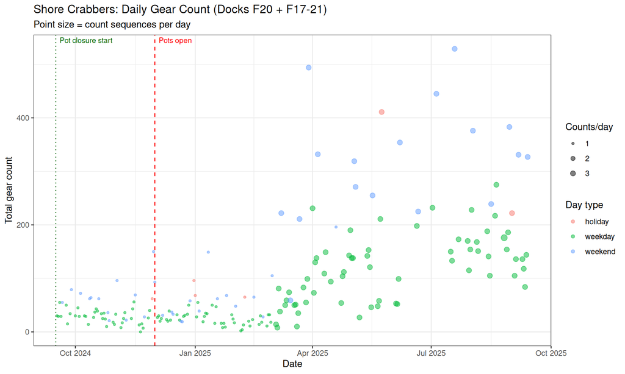

```r
days_full <- prep_days_crab(params$est_date_start, params$est_date_end,
                            params, L_eff_model)

# Plot 1: Shore gear count timeseries
p_shore_effort <- dwg$shore_effort |>
  group_by(event_date) |>
  summarise(total_gear = sum(count_quantity), n_counts = n(), .groups = "drop") |>
  left_join(days_full |> select(event_date, day_type), by = "event_date") |>
  ggplot(aes(x = event_date, y = total_gear, color = day_type, size = n_counts)) +
  geom_point(alpha = 0.5) +
  pot_closure_markers(params, labels = TRUE) +
  scale_size_continuous(range = c(1,3), breaks = 1:3, name = "Counts/day") +
  labs(title = "Shore Crabbers: Daily Gear Count (Docks F20 + F17-21)",
       subtitle = "Point size = count sequences per day",
       x = "Date", y = "Total gear count", color = "Day type") +
  theme_bw()
ggsave(file.path(output_dir, "plot_shore_effort_timeseries.png"), p_shore_effort, width = 10, height = 6)
print(p_shore_effort)
```

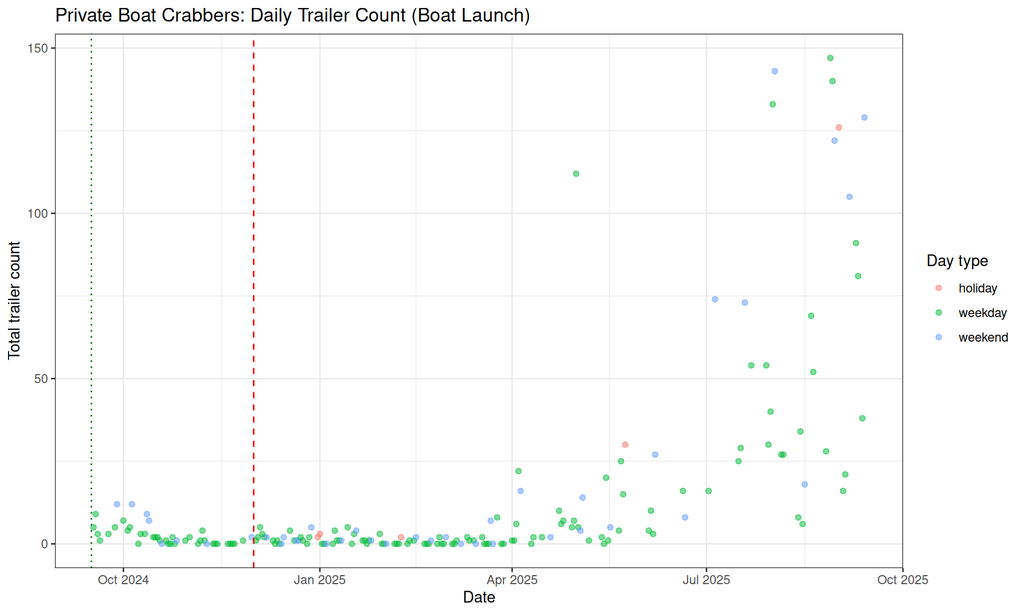

```r
# Plot 2: Boat trailer count timeseries
p_boat_effort <- dwg$boat_effort |>
  group_by(event_date) |>
  summarise(total_trailers = sum(count_quantity), n_counts = n(), .groups = "drop") |>
  left_join(days_full |> select(event_date, day_type), by = "event_date") |>
  ggplot(aes(x = event_date, y = total_trailers, color = day_type)) +
  geom_point(alpha = 0.5) +
  pot_closure_markers(params, labels = FALSE) +
  labs(title = "Private Boat Crabbers: Daily Trailer Count (Boat Launch)",
       x = "Date", y = "Total trailer count", color = "Day type") +
  theme_bw()
ggsave(file.path(output_dir, "plot_boat_effort_timeseries.png"), p_boat_effort, width = 10, height = 6)
print(p_boat_effort)
```

```r
# Plot 3: CPUE timeseries by population
cpue_data <- dwg$interview |>
  filter(fishing_time_total > 0, dungeness_kept >= 0) |>
  mutate(cpue = dungeness_kept / fishing_time_total) |>
  group_by(event_date, population) |>
  summarise(mean_cpue = mean(cpue), n_int = n(), .groups = "drop") |>
  left_join(days_full |> select(event_date, day_type), by = "event_date") |>
  filter(population %in% c("shore", "private_boat"))

p_cpue <- cpue_data |>
  ggplot(aes(x = event_date, y = mean_cpue, color = day_type)) +
  geom_point(alpha = 0.4, size = 1.5) +
  geom_smooth(method = "loess", span = 0.3, se = TRUE, color = "grey30") +
  pot_closure_markers(params, labels = FALSE) +
  facet_wrap(~population, ncol = 1, scales = "free_y",
             labeller = labeller(population = c(shore = "Shore Crabbers", private_boat = "Private Boat Crabbers"))) +
  labs(title = "Dungeness CPUE by Population",
       x = "Date", y = "Mean CPUE (crab/crabber-hr)", color = "Day type") +
  theme_bw()
ggsave(file.path(output_dir, "plot_cpue_timeseries.png"), p_cpue, width = 10, height = 8)
```

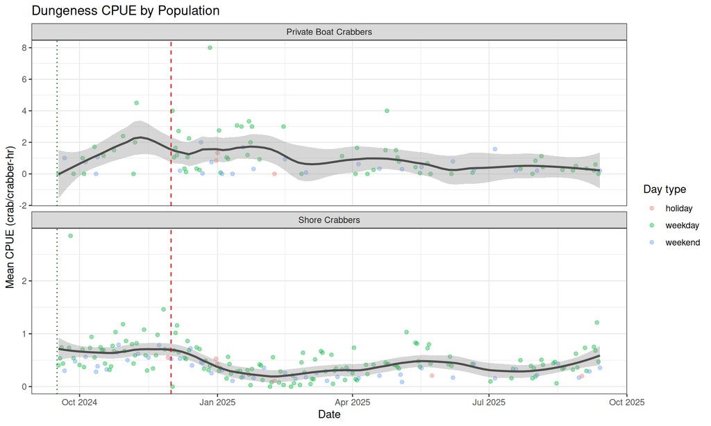

```r
print(p_cpue)
```

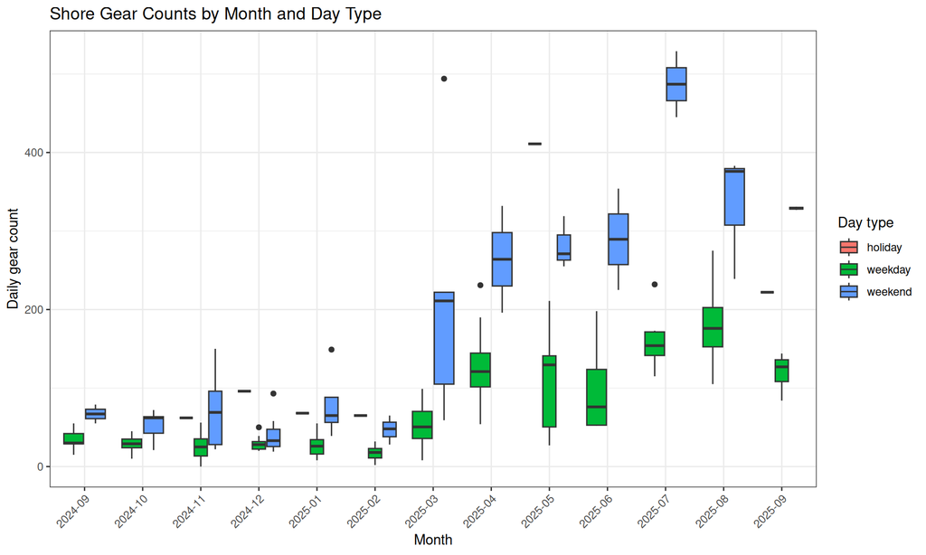

```r
# Plot 4: Gear counts by month and day type (boxplot)
p_effort_month <- dwg$shore_effort |>
  group_by(event_date) |>
  summarise(total_gear = sum(count_quantity), .groups = "drop") |>
  left_join(days_full |> select(event_date, day_type, month, year), by = "event_date") |>
  mutate(month_label = factor(format(event_date, "%Y-%m"))) |>
  ggplot(aes(x = month_label, y = total_gear, fill = day_type)) +
  geom_boxplot() +
  labs(title = "Shore Gear Counts by Month and Day Type",
       x = "Month", y = "Daily gear count", fill = "Day type") +
  theme_bw() +
  theme(axis.text.x = element_text(angle = 45, hjust = 1))
ggsave(file.path(output_dir, "plot_effort_by_month.png"), p_effort_month, width = 12, height = 6)
print(p_effort_month)
```

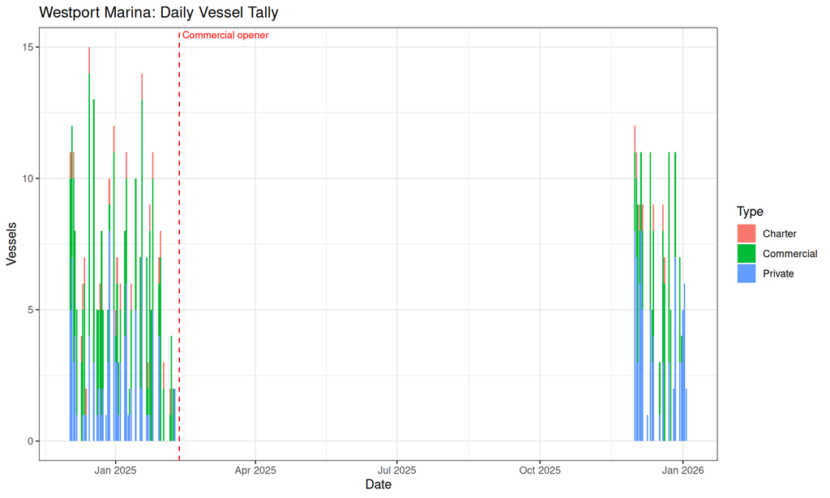

```r
# Plot 5: Commercial/charter vessel tally
if(nrow(dwg$comm_tally) > 0) {
  p_comm <- dwg$comm_tally |>
    pivot_longer(cols = c(commercial_tally, charter_tally, private_tally),
                 names_to = "vessel_type", values_to = "count") |>
    mutate(vessel_type = str_remove(vessel_type, "_tally") |> str_to_title()) |>
    ggplot(aes(x = date, y = count, fill = vessel_type)) +
    geom_col(position = "stack") +
    geom_vline(xintercept = as.Date(params$commercial_opener), linetype = "dashed", color = "red") +
    annotate("text", x = as.Date(params$commercial_opener) + 2, y = Inf,
             label = "Commercial opener", hjust = 0, vjust = 1.5, size = 3, color = "red") +
    labs(title = "Westport Marina: Daily Vessel Tally",
         x = "Date", y = "Vessels", fill = "Type") +
    theme_bw()
  ggsave(file.path(output_dir, "plot_commercial_tally.png"), p_comm, width = 10, height = 5)
  print(p_comm)
}
```

```r
message("  Diagnostic plots saved.\n")
```

```r
timer_stop("2_diagnostic_plots")
```

```
##   [TIMER] 2_diagnostic_plots: 0.1 min
```

## 3. Point Estimator (PE)

The design-based estimator: it averages sampled days within each stat-week by day-type stratum and expands to the season, independently of the BSS. It is the model-free cross-check the gate can fall back to. This block also runs the commercial/charter census and the PE port totals.

```r
# ---- 7.2 PE ESTIMATES ----
timer_start("3_PE_estimates")
message("\n", strrep("=",60), "\n PE ESTIMATES\n", strrep("=",60), "\n")
```

```r
pe_all <- list()
for(pop in c("shore","private_boat")) {
  for(ss in subseasons) {
    label <- paste0(pop, "_", ss$name)
    days_ss <- prep_days_crab(ss$start, ss$end, params, L_eff_model)
    summ_ss <- prep_population_summary(dwg, pop, ss$start, ss$end, params)
    pe_all[[label]] <- run_pe_gear(summ_ss, days_ss, params, label, population = pop)
  }
}
```

```
##
##   shore [2024-09-16 to 2024-11-30]: 52 effort obs, 871 interviews, crab/gear=0.76, R_G_empirical=1.32
##   PE shore_ring_net_only strata: 1 of 24 cells unsampled (1 of 76 days, 1.3%), 10 cells with ONE sampled day (19 days); fill 'local_day_type', variance 'impute_aware'.
##     imputed effort 154 of 7,328 (2.1%); SE 650 (8.9%) against 244 (3.3%) on the sampled-only arithmetic.
##   PE check [shore_ring_net_only / Dungeness_Kept]: implied CPUE 1.2454 vs interview ratio-of-sums 1.2462 (1.00x) [gear-deployments]
##   PE shore_ring_net_only: Effort=7,328 gear-deployments, Dung=9,126
##
##   shore [2024-12-01 to 2025-09-15]: 313 effort obs, 2860 interviews, crab/gear=0.79, R_G_empirical=1.27
##   PE shore_all_gear strata: 20 of 91 cells unsampled (44 of 289 days, 15.2%), 35 cells with ONE sampled day (80 days); fill 'local_day_type', variance 'impute_aware'.
##     imputed effort 8,935 of 39,165 (22.8%); SE 1,753 (4.5%) against 471 (1.2%) on the sampled-only arithmetic.
##   PE check [shore_all_gear / Dungeness_Kept]: implied CPUE 0.8416 vs interview ratio-of-sums 0.8696 (0.97x) [gear-deployments]
##   PE shore_all_gear: Effort=39,165 gear-deployments, Dung=32,960
##
##   private_boat [2024-09-16 to 2024-11-30]: 44 effort obs, 22 interviews, crab/gear=0.75, R_G_empirical=1.34
##   PE gear ratio arm 'match_bss' [gear-resolved boat]: 22 -> 18 interviews (matches the BSS R_G_boat frame)
##   PE boat scale: gear_per_group=2.89, tau=3.03, mean f=0.301 (deployments, crab-directed)
##   PE private_boat_ring_net_only strata: 6 of 24 cells unsampled (11 of 76 days, 14.5%), 7 cells with ONE sampled day (14 days); fill 'local_day_type', variance 'impute_aware'.
##     imputed effort 59 of 457 (12.8%); SE 98 (21.5%) against 29 (6.3%) on the sampled-only arithmetic.
##   PE check [private_boat_ring_net_only / Dungeness_Kept]: implied CPUE 2.6080 vs interview ratio-of-sums 2.1154 (1.23x) [gear-deployments]
##   PE private_boat_ring_net_only: Effort=457 gear-deployments, Dung=1,192
##
##   private_boat [2024-12-01 to 2025-09-15]: 196 effort obs, 158 interviews, crab/gear=0.80, R_G_empirical=1.26
##   PE gear ratio arm 'match_bss' [gear-resolved boat]: 158 -> 130 interviews (matches the BSS R_G_boat frame)
##   PE boat scale: gear_per_group=3.56, tau=3.03, mean f=0.584 (deployments, crab-directed)
##   PE private_boat_all_gear strata: 22 of 91 cells unsampled (47 of 289 days, 16.3%), 32 cells with ONE sampled day (75 days); fill 'local_day_type', variance 'impute_aware'.
##     imputed effort 3,469 of 13,951 (24.9%); SE 1,602 (11.5%) against 573 (4.1%) on the sampled-only arithmetic.
##   PE check [private_boat_all_gear / Dungeness_Kept]: implied CPUE 2.6480 vs interview ratio-of-sums 3.2765 (0.81x) [gear-deployments]
##   PE private_boat_all_gear: Effort=13,951 gear-deployments, Dung=36,941
```

```r
# 2026-08-27: the empty-effort-stratum audit as a FILE, so both tracks report it the same
# way regardless of chunk options. See write_pe_empty_stratum_report() in
# 03_R_functions/save_run_diagnostics.R.
pe_empty_report <- write_pe_empty_stratum_report(pe_all, output_dir, params)


# ---- 7.3 PE PLOTS ----
message("\n  Generating PE plots...\n")
```

```r
pe_daily_all <- list()
for(pop in c("shore","private_boat")) {
  for(ss in subseasons) {
    label <- paste0(pop, "_", ss$name)
    days_ss <- prep_days_crab(ss$start, ss$end, params, L_eff_model)
    summ_ss <- prep_population_summary(dwg, pop, ss$start, ss$end, params)

    # P1: this daily PE series must use the SAME effort basis as run_pe_gear(), or the
    # daily plots contradict the totals. It previously applied the shore
    # crabber-hours formula (crabbers x day_length) to the boat as well.
    is_shore_d <- (pop == "shore")
    spec_d <- bss_effort_spec(is_shore_d, days_ss, params)
    if(is_shore_d) {
      mult_d <- if(spec_d$effort_scale_gear == 1L) 1.0 else summ_ss$crabbers_per_gear
      Lcol_d <- if(spec_d$unit == "gear-deployments") (params$tau_shore_prior_mu %||% bss_tau_fallback("shore", params)) else NA
    } else {
      ng_d   <- suppressWarnings(as.numeric(summ_ss$interview$number_of_gear))
      ng_d   <- ng_d[!is.na(ng_d) & ng_d > 0]
      mult_d <- if(length(ng_d) > 0) mean(ng_d) else (params$gear_per_group_default %||% 4.0)
      Lcol_d <- params$tau_boat_prior_mu %||% bss_tau_fallback("private_boat", params)
    }

    de <- summ_ss$effort_index |>
      filter(count_sequence <= params$bss_max_count_seq) |>
      group_by(event_date, section_num) |>
      summarise(mean_count = mean(count_quantity), .groups = "drop") |>
      mutate(est_units = mean_count * mult_d) |>
      left_join(days_ss |> select(event_date, day_type, day_length), by = "event_date") |>
      mutate(L_d = if(is.na(Lcol_d)) day_length else Lcol_d,
             est_daily_effort = est_units * L_d,
             est_daily_effort_units = est_daily_effort,   # unit is `effort_unit` below
             effort_unit = spec_d$unit,
             population = pop, subseason = ss$name)
    pe_daily_all[[label]] <- de
  }
}
```

```
##
##   shore [2024-09-16 to 2024-11-30]: 52 effort obs, 871 interviews, crab/gear=0.76, R_G_empirical=1.32
##
##   shore [2024-12-01 to 2025-09-15]: 313 effort obs, 2860 interviews, crab/gear=0.79, R_G_empirical=1.27
##
##   private_boat [2024-09-16 to 2024-11-30]: 44 effort obs, 22 interviews, crab/gear=0.75, R_G_empirical=1.34
##
##   private_boat [2024-12-01 to 2025-09-15]: 196 effort obs, 158 interviews, crab/gear=0.80, R_G_empirical=1.26
```

```r
pe_daily_df <- bind_rows(pe_daily_all)

p_pe_effort <- pe_daily_df |>
  mutate(pop_label = case_when(
    population == "shore" ~ "Shore Crabbers",
    population == "private_boat" ~ "Private Boat Crabbers")) |>
  ggplot(aes(x = event_date, y = est_daily_effort_units, color = day_type)) +
  geom_point(alpha = 0.4) +
  geom_smooth(method = "loess", span = 0.3, se = TRUE, color = "grey30") +
  pot_closure_markers(params, labels = FALSE) +
  facet_wrap(~pop_label, ncol = 1, scales = "free_y") +
  labs(title = "PE: Estimated Daily Effort (gear-deployments) by Population",
       x = "Date", y = "Estimated effort (gear-deployments)", color = "Day type") +
  theme_bw()
ggsave(file.path(output_dir, "plot_pe_daily_effort.png"), p_pe_effort, width = 10, height = 8)
```

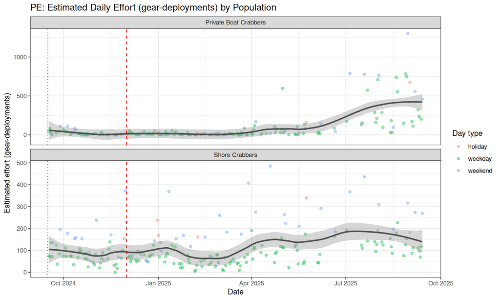

```r
print(p_pe_effort)
```

```r
timer_stop("3_PE_estimates")
```

```
##   [TIMER] 3_PE_estimates: 0.1 min
```

```r
# ---- 7.4 COMMERCIAL/CHARTER ----
timer_start("4_commercial_charter")
pe_all$comm_charter <- estimate_comm_charter(dwg, params)
```

```
##
## --- Commercial/Charter Estimation (commercial census + charter expansion) ---
##   Tally days: 47, Interviews: 161 (commercial 141, charter 20)
##   Mean Dungeness per vessel-trip: commercial 39.1, charter 64.3
##   Charter frame: the trip roster, unioned with the tally. 31 sailed roster trip(s); 8 trip(s) on 8 day(s) with no tally (a tally-only frame carries 0 there); 6 tally day(s) where the frames disagree.
##     date         tally  roster  used  note
##     2024-12-07       0       1     1  tally day; frames disagree
##     2024-12-10       1       0     1  tally day; frames disagree
##     2024-12-12       1       0     1  tally day; frames disagree
##     2024-12-19       -       1     1  no tally; roster trips
##     2024-12-29       -       1     1  no tally; roster trips
##     2025-01-05       -       1     1  no tally; roster trips
##     2025-01-11       1       2     2  tally day; frames disagree
##     2025-01-12       -       1     1  no tally; roster trips
##     2025-01-15       -       1     1  no tally; roster trips
##     2025-01-19       -       1     1  no tally; roster trips
##     2025-01-25       1       2     2  tally day; frames disagree
##     2025-01-26       -       1     1  no tally; roster trips
##     2025-01-30       1       0     1  tally day; frames disagree
##     2025-02-02       -       1     1  no tally; roster trips
##
##   Commercial vessels by day type (census_expansion = 'none'; unsampled days = no operation, so Total = Sampled):
##     Day Type    Sampled  Calendar  Expanded-to  Vessels/day  Vessels
##     weekday        33        48          33           3.6       118
##     weekend        14        22          14           3.3        46
##
##   Charter expansion (roster frame, stratified by vessel; the vessels are NOT fully sampled): 34 trip(s), 20 interviewed (59%), 1,286 crab observed -> 2,133 crab; SE 73 (3.4%)
##     Ultimate                 trips   25.0  interviewed  17    70.2 crab/trip  est    1756  SE    72  [vessel mean]
##     Outta Line               trips    6.0  interviewed   3    30.7 crab/trip  est     184  SE    12  [vessel mean]
##     (not on the roster)      trips    3.0  interviewed   0    64.3 crab/trip  est     193  SE     0  [pooled charter mean (not on the roster)]
##
##   COMMERCIAL (census, exact on the tally days): 6,405 crab, 164 vessel-trips; 23 unsampled calendar day(s) = no operation. Per-vessel mean over 141 interviews: SE 123 (1.9%), reported, not carried.
##   CHARTER (expansion): 2,133 crab. Expansion SE 73 (3.4%), carried into the port interval.
##
##   Est Dungeness (commercial census + charter expansion): 8,538 | total SE 143; 73 carried under census_uncertainty = 'charter'
```

```r
# 2026-09-29: the frame conditions also go to the run-warnings log (the closing section).
for (.w in pe_all$comm_charter$frame_warnings %||% character(0))
  bss_warn("census", .w, severity = if (grepl("^(NO CENSUS FRAME|CENSUS OUTSIDE)", .w)) "warning" else "note")
# Review item 4 (2026-09-08): observed / imputed per-day flags and the imputation variance
# behind Dungeness_Kept_se (see estimate_comm_charter.R); same files as the pooled track.
if (!is.null(pe_all$comm_charter$daily_full))
  write.csv(pe_all$comm_charter$daily_full, file.path(output_dir, "census_daily.csv"), row.names = FALSE)
if (!is.null(pe_all$comm_charter$variance_detail))
  write.csv(pe_all$comm_charter$variance_detail, file.path(output_dir, "census_variance.csv"), row.names = FALSE)

# --- 2026-09-13: THE CENSUS FRAME WARNINGS, IN THE REPORT --------------------------------
# Matt, on whether estimate_comm_charter() should stop rather than warn on a missing census
# frame: "a warning is fine - included in the html report." A bare warning() does not
# satisfy that: knitr defers warnings to the end of a chunk, an html_document can be told to
# hide them, and a batch runner rendering with quiet = TRUE never shows them at all, which
# is how a run whose census component is 0 because the frame is MISSING can look like a run
# whose census component is genuinely small. The conditions come back from the function as
# DATA, are printed here unconditionally, and are written to census_frame_warnings.csv so a
# verdict block can read them from the output folder without re-running anything. Identical
# block in the pooled driver; the two tracks must not differ in what they disclose.
.fw <- pe_all$comm_charter$frame_warnings %||% character(0)
if (length(.fw)) {
  cat("\n", strrep("!", 78), "\n", sep = "")
  cat(sprintf(" CENSUS FRAME: %d condition(s) that change how the commercial/charter number\n",
              length(.fw)))
  cat(" should be read. None of these stops the run; every one of them is a fact about\n")
  cat(" the FRAME, not about the catch.\n")
  cat(strrep("!", 78), "\n", sep = "")
  for (i in seq_along(.fw)) cat(sprintf(" %d. %s\n", i, .fw[i]))
  cat(strrep("!", 78), "\n\n", sep = "")
} else {
  cat("  Census frame: no frame conditions to report.\n")
}
```

```
##
## !!!!!!!!!!!!!!!!!!!!!!!!!!!!!!!!!!!!!!!!!!!!!!!!!!!!!!!!!!!!!!!!!!!!!!!!!!!!!!
##  CENSUS FRAME: 3 condition(s) that change how the commercial/charter number
##  should be read. None of these stops the run; every one of them is a fact about
##  the FRAME, not about the catch.
## !!!!!!!!!!!!!!!!!!!!!!!!!!!!!!!!!!!!!!!!!!!!!!!!!!!!!!!!!!!!!!!!!!!!!!!!!!!!!!
##  1. ROSTER-ONLY DAYS: 8 charter trip(s) on 8 day(s) with no vessel tally. They are in the frame because charter_frame = 'roster' unions the roster with the tally; a tally-only frame would carry 0 crab on those days.
##  2. FRAMES DISAGREE on 6 tally day(s): the vessel tally and the charter roster give different trip counts. The larger of the two is used. See roster_reconciliation in census_roster_reconciliation.csv.
##  3. UNSAMPLED DAYS TREATED AS NO OPERATION: 23 calendar day(s) in the census window have no tally row, and census_expansion = 'none' records them as days on which no vessel operated rather than imputing them. That is what the tally means; it is stated here because the alternative (census_expansio…
## !!!!!!!!!!!!!!!!!!!!!!!!!!!!!!!!!!!!!!!!!!!!!!!!!!!!!!!!!!!!!!!!!!!!!!!!!!!!!!
```

```r
utils::write.csv(data.frame(n = seq_along(.fw), warning = if (length(.fw)) .fw else character(0),
                            stringsAsFactors = FALSE),
                 file.path(output_dir, "census_frame_warnings.csv"), row.names = FALSE)

timer_stop("4_commercial_charter")
```

```
##   [TIMER] 4_commercial_charter: 0.0 min
```

```r
# ---- 7.5 PE PORT TOTALS ----
message("\n", strrep("=",60), "\n PE PORT TOTALS\n", strrep("=",60), "\n")
```

```r
# component_keys / component_names now follow the sub-season set (build_subseasons):
# one row per population x sub-season, then comm_charter, then a PORT TOTAL computed from
# the semantic sums (pe_port_total), not by a fixed row index. component_keys is still
# consumed by the pe_summary build below.
pe_pops    <- c("shore", "private_boat")
pop_disp   <- c(shore = "Shore", private_boat = "Private Boat")
ss_names   <- vapply(subseasons, function(ss) ss$name,         character(1))
ss_disp    <- vapply(subseasons, function(ss) ss$display_name, character(1))
component_keys  <- c(unlist(lapply(pe_pops, function(p) paste0(p, "_", ss_names))), "comm_charter")
component_names <- c(unlist(lapply(pe_pops, function(p) sprintf("%s (%s)", pop_disp[[p]], ss_disp))),
                     "Commercial/Charter")

pe_summary <- tibble(
  Component  = c(component_names, "PORT TOTAL"),
  Effort = c(vapply(component_keys, function(k) pe_field(k, "effort_total"),  numeric(1)), pe_port_total("effort_total")),   # gear deployments (census: vessel-trips); was Effort_hrs
  Dungeness  = c(vapply(component_keys, function(k) pe_field(k, "Dungeness_Kept"), numeric(1)), pe_port_total("Dungeness_Kept"))
)

report_table(pe_summary |> mutate(across(where(is.numeric), ~round(.))), caption = "PE port totals by component")
```

PE port totals by component

| Component | Effort | Dungeness |
| --- | --- | --- |
| Shore (Pot closure) | 7,328 | 9,126 |
| Shore (All gear) | 39,165 | 32,960 |
| Private Boat (Pot closure) | 457 | 1,192 |
| Private Boat (All gear) | 13,951 | 36,941 |
| Commercial/Charter | 198 | 8,538 |
| PORT TOTAL | 61,099 | 88,758 |

```r
write.csv(pe_summary, file.path(output_dir, "pe_port_summary.csv"), row.names=FALSE)
```

## 4. Bayesian state-space model fits

Each population by sub-season is fit independently with a Bayesian state-space model: a latent AR(1) effort and CPUE process at a per-fit temporal resolution (capped per population so a thin series is not over-resolved), a negative-binomial observation model, and gear-deployment effort. Fitting is the slow step. **Healthy:** each fit with enough data samples without a wall of divergences; the convergence gate below is the formal check.

```r
# ---- 7.6 BSS MODEL RUNS ----
timer_start("5_BSS_model_runs")
message("\n", strrep("=",60), "\n BSS MODEL RUNS\n", strrep("=",60), "\n")
```

```r
bss_catch_groups <- catch_groups
message(sprintf("Running BSS for: %s\n", paste(bss_catch_groups, collapse=", ")))
```

```r
bss_all <- list()
ar_resolutions <- list()   # AR resolution actually used, per fit (for the gate report)
ar_escalation_log <- list()  # improvement 7: one row per fit attempt (ar_escalation_log.csv)
.kept_attempt <- list()      # fit label -> the attempt index whose stanfit was retained
for(cg in bss_catch_groups) {
  for(pop in c("shore","private_boat")) {
    for(ss in subseasons) {
      label <- paste0(pop, "_", ss$name, "_", cg)
      message(sprintf("\n--- BSS: %s ---\n", label))

      days_ss <- prep_days_crab(ss$start, ss$end, params, L_eff_model)
      summ_ss <- prep_population_summary(dwg, pop, ss$start, ss$end, params)

      n_int <- nrow(summ_ss$interview)
      n_eff <- nrow(summ_ss$effort_index)

      if(n_eff < 5 || n_int < params$bss_min_interviews) {
        message(sprintf("  Insufficient data for BSS (%d effort, %d interviews < %d min), using PE only.\n",
                    n_eff, n_int, params$bss_min_interviews))
        bss_all[[label]] <- list(C_sum=NA, E_sum=NA, pe_fallback=TRUE,
                                 population=pop, subseason=ss$name, catch_group=cg)
        next
      }

      # ================================================================================
      # improvement 7: AR RESOLUTION ESCALATION LADDER (mirrors the pooled driver)
      # ar_escalate = FALSE (default) -> one attempt at the sub-season's fixed period_bss
      # (or, with ar_adaptive = TRUE, at the data-driven capped resolution). Identical to
      # previous runs. ar_escalate = TRUE -> start at the finest rung and refit one rung
      # coarser on each convergence-gate failure, stopping at the first rung that passes.
      # Every attempt is a real multi-hour fit and is logged to ar_escalation_log.csv.
      # ================================================================================
      eff_d_ladder <- summ_ss$effort_index |>
        filter(count_sequence <= params$bss_max_count_seq) |>
        left_join(days_ss |> select(event_date, day_index), by = "event_date") |>
        filter(!is.na(day_index))
      # 2026-09-14 (D3): the AR period is resolved PER POPULATION, not per sub-season.
      # period_bss belongs to the sub-season and a sub-season holds BOTH populations, so
      # until now the shore all-gear fit and the boat all-gear fit were locked to the same
      # period with no way to separate them. The first D3 ladder moved both and its port
      # total was 90% boat movement; see 03_R_functions/bss_gear_period.R for the numbers.
      # bss_gear_period() returns NULL under the flat form; the per-population form ships
      # since A32, so this line sets the shore all-gear fit to weekly.
      .period_ss <- bss_gear_period(params, pop, ss$gear_regime) %||% ss$period_bss
      if (!identical(.period_ss, ss$period_bss))
        message(sprintf("  AR period from gear_period_bss[[%s]][[%s]]: %s (the sub-season's own is %s)",
                        pop, ss$gear_regime, .period_ss, ss$period_bss))
      ar_ladder <- bss_ar_ladder(days_ss, eff_d_ladder, pop, params,
                                 fixed_resolution = if (isTRUE(params$ar_adaptive)) NULL else .period_ss,
                                 gear_regime = ss$gear_regime)
      # 2026-09-04: resolved PER FIT; see the matching block in the pooled driver.
      .esc_on <- .bss_resolve_ar_escalate(params, pop, ss$gear_regime)
      .incumbent_passed <- FALSE; .incumbent_pi_rel <- Inf
      if (.esc_on)
        message(sprintf("  AR escalation ladder [%s/%s]: %s", pop, ss$gear_regime,
                        paste(ar_ladder, collapse = " -> ")))

      # improvement 6: post-filter interview floor (the guard above counts UNFILTERED
      # interviews, so it reads looser than what the CPUE likelihood sees).
      min_fitted <- params$bss_min_interviews_fitted %||% params$bss_min_interviews

      is_shore <- (pop == "shore")
      is_allgear <- (ss$gear_regime == "all_gear")
      is_ringnet <- (ss$gear_regime == "pot_closure")

      fit <- NULL; bss_data <- NULL; too_thin <- FALSE

      for (attempt in seq_along(ar_ladder)) {

        # 2026-09-04: `.esc_on`, not isTRUE(). See the long note at the same line in
        # BSS-GH-pooled-CPUE-model.Rmd: isTRUE() is FALSE for every scoped form of
        # ar_escalate, which silently refits the SAME resolution on every rung. The gear
        # track has not yet been run with a scoped ar_escalate, so this one was latent.
        force_res <- if (.esc_on) ar_ladder[attempt] else NULL
        bss_data_try <- prep_bss_crab_gear(days_ss, summ_ss, cg, params, pop, .period_ss,
                                  gear_exclude = ss$gear_exclude %||% character(0),
                                  gear_regime = ss$gear_regime,
                                  ie_data = ie_data,
                                  force_resolution = force_res)

        n_fitted <- bss_data_try$.n_interviews_fitted %||% bss_data_try$IntC
        if (n_fitted < min_fitted) {
          message(sprintf(paste0("  Post-filter interviews %d < bss_min_interviews_fitted = %d ",
                                 "(pre-filter count was %d); PE fallback."),
                          n_fitted, min_fitted, n_int))
          bss_all[[label]] <- list(C_sum=NA, E_sum=NA, pe_fallback=TRUE,
                                   population=pop, subseason=ss$name, catch_group=cg)
          too_thin <- TRUE
          break
        }

        # Per-fit sampler tuning: shore all-gear is the most complex posterior
        # (4 gear types, 43 weekly periods since A32); pot-closure fits are data-sparse
        # and benefit from tighter adaptation. All other fits use defaults.
        if(is_shore && is_allgear) {
          fit_iter    <- params$bss_iter_shore_allgear
          fit_warmup  <- params$bss_warmup_shore_allgear
          fit_treedep <- params$bss_treedepth_shore_allgear %||% params$bss_max_treedepth_default
          fit_delta   <- params$bss_delta_shore_allgear %||% params$bss_adapt_delta_default
        } else if(is_ringnet) {
          fit_iter    <- params$bss_iter_ringnet %||% params$bss_iter_default
          fit_warmup  <- params$bss_warmup_ringnet %||% params$bss_warmup_default
          fit_treedep <- params$bss_treedepth_ringnet %||% params$bss_max_treedepth_default
          fit_delta   <- params$bss_delta_ringnet %||% params$bss_adapt_delta_default
        } else if (!is_shore && is_allgear) {
          # private_boat all-gear. Previously the only fit with no per-fit settings, which is
          # why it was the only fit that could not sample (see the params block above).
          fit_iter    <- params$bss_iter_boat_allgear      %||% params$bss_iter_default
          fit_warmup  <- params$bss_warmup_boat_allgear    %||% params$bss_warmup_default
          fit_treedep <- params$bss_treedepth_boat_allgear %||% params$bss_max_treedepth_default
          fit_delta   <- params$bss_delta_boat_allgear     %||% params$bss_adapt_delta_default
        } else {
          fit_iter    <- params$bss_iter_default
          fit_warmup  <- params$bss_warmup_default
          fit_treedep <- params$bss_max_treedepth_default
          fit_delta   <- params$bss_adapt_delta_default
        }
```

```r
        message(sprintf("  Stan [attempt %d/%d, %s AR]: iter=%d, warmup=%d, max_treedepth=%d, adapt_delta=%.2f, init_r=%.2f\n",
                    attempt, length(ar_ladder), bss_data_try$.ar_resolution,
                    fit_iter, fit_warmup, fit_treedep, fit_delta, params$bss_init_r %||% 2))

        timer_start(paste0("BSS_", label, "_att", attempt))
        # 2026-08-26: guarded wrapper, 03_R_functions/bss_stan_fit.R. On the happy path
        # this is rstan::stan() with the same arguments, same seed, same RNG stream, so
        # fits are unchanged. It adds two pre/post checks that would have turned the
        # 2026-08-25 "dim(X) must have a positive length" failure into a one-line error
        # naming the missing Stan data variable: a data-completeness check before the
        # sampler, and an empty-stanfit check after it. log_file keeps the Stan console
        # for this fit in output_dir, so a chain failure stays diagnosable even though
        # this chunk is results='hide'.
        fit_try <- bss_stan_fit(
          file = here("02_stan_models", params$bss_model_file),
          data = bss_data_try,
          label = sprintf("%s att%d", label, attempt),
          log_file = file.path(output_dir,
                               sprintf("stan_console_%s_att%d.log", label, attempt)),
          chains = params$bss_chains, iter = fit_iter, warmup = fit_warmup,
          control = list(adapt_delta = fit_delta, max_treedepth = fit_treedep),
          seed = params$bss_seed,   # was missing: gear-resolved fits were not reproducible
          cores = params$bss_cores,
          # B51 (2026-09-29): the initial-value radius, run_config$bss_init_r (0.5 shipped;
          # rstan's default is 2, the value every render before B51 used). D33.
          init_r = params$bss_init_r %||% 2
        )
        timer_stop(paste0("BSS_", label, "_att", attempt))

        gate_try <- tryCatch(
          bss_compute_gate(list(fit = fit_try, pe_fallback = FALSE), label,
                           catch_par        = "C_expected_sum",
                           effort_par       = "E_sum",
                           max_impact_sd    = params$max_divergence_total_impact_sd %||% 0.10,
                           max_div_fraction = params$max_divergence_fraction %||% 0.05,
                           ar_resolution    = bss_data_try$.ar_resolution),
          error = function(e) NULL)

        # 2026-09-04: keep this rung's ANSWER as well as its sampler diagnostics; see the
        # matching block in the pooled driver and 03_R_functions/bss_ar_rung_summary.R.
        .rung <- bss_ar_rung_summary(fit_try)
        # 2026-09-06: adequacy PER RUNG; see the note at the same point in
        # BSS-GH-pooled-CPUE-model.Rmd and 03_R_functions/bss_rung_adequacy.R.
        .radq <- if (isTRUE(params$ar_rung_adequacy %||% TRUE) && length(ar_ladder) > 1)
                   bss_rung_adequacy(fit_try, bss_data_try) else
                   bss_rung_adequacy(NULL, NULL)
        # 2026-09-29 (D29): every rung's block CV; see the same block in the pooled driver.
        if (isTRUE(params$ar_rung_adequacy %||% TRUE) && length(ar_ladder) > 1)
          tryCatch(write_block_cv_diagnostics(fit_try, bss_data_try, days_ss,
                                              paste0(label, "_", bss_data_try$.ar_resolution %||% attempt),
                                              output_dir, prefix = "ladder_block"),
                   error = function(e) bss_warn("ladder", sprintf("%s attempt %d: the rung's block CV was not written (%s).",
                                                               label, attempt, conditionMessage(e)), severity = "note"))
        ar_escalation_log[[length(ar_escalation_log) + 1]] <- tibble(
          fit                 = label,
          attempt             = attempt,
          n_attempts_planned  = length(ar_ladder),
          ar_resolution       = bss_data_try$.ar_resolution %||% NA_character_,
          P_n                 = bss_data_try$P_n,
          escalation_enabled  = .esc_on,
          divergences         = gate_try$divergences         %||% NA_integer_,
          divergence_fraction = gate_try$divergence_fraction %||% NA_real_,
          impact_C_sd         = gate_try$impact_C_sd         %||% NA_real_,
          pass_convergence    = gate_try$pass_convergence    %||% NA,
          catch_median        = .rung$catch_median,
          catch_lo95          = .rung$catch_lo95,
          catch_hi95          = .rung$catch_hi95,
          pi_width            = .rung$pi_width,
          pi_width_rel        = .rung$pi_width_rel,
          effort_median       = .rung$effort_median,
          p_loo               = .radq$p_loo,
          p_loo_frac          = .radq$p_loo_frac,
          n_pareto_bad        = .radq$n_pareto_bad,
          cov50_gear          = .radq$cov50_gear,
          cov50_catch         = .radq$cov50_catch,
          cov50_trailer       = .radq$cov50_trailer,
          pit_mean_catch      = .radq$pit_mean_catch,
          selected            = FALSE
        )

        # Rung selection; see the fully commented block in the pooled driver. Default
        # "first_pass" reproduces the pre-2026-09-04 behaviour exactly.
        .stop_rule   <- params$ar_escalate_stop   %||% "first_pass"
        .select_rule <- params$ar_escalate_select %||% "first_pass"
        # 2026-09-28 (B46): a gate that ERRORS is a rung not shown to pass, so it escalates
        # (bounded by ar_escalate_max_attempts) instead of stopping the ladder as a pass.
        # The authoritative gate in the totals section recomputes the verdict either way.
        if (is.null(gate_try)) message(sprintf("  WARNING: %s attempt %d: the convergence gate errored; treated as NOT passed.", label, attempt))
        .passed      <- !is.null(gate_try) && isTRUE(gate_try$pass_convergence)
        .keep <- if (is.null(fit)) TRUE
                 else if (identical(.stop_rule, "first_pass")) TRUE
                 else if (!.passed) FALSE
                 else if (!isTRUE(.incumbent_passed)) TRUE
                 else if (identical(.select_rule, "narrowest_pi"))
                   isTRUE(.rung$pi_width_rel < (.incumbent_pi_rel %||% Inf))
                 else FALSE
        if (.keep) {
          bss_data <- bss_data_try; fit <- fit_try
          ar_resolutions[[label]] <- bss_data_try$.ar_resolution
          .kept_attempt[[label]] <- attempt
          .incumbent_passed <- .passed
          .incumbent_pi_rel <- .rung$pi_width_rel
        }
```

```r
        if (identical(.stop_rule, "all_rungs") && .esc_on) {
          if (attempt < length(ar_ladder)) {
            message(sprintf("  [all_rungs] %s AR %s the gate; fitting %s next for the ladder.",
                            bss_data_try$.ar_resolution, if (.passed) "PASSED" else "failed",
                            ar_ladder[attempt + 1]))
            next
          } else break
        }

        if (.passed) break
        if (!.esc_on) break
        if (attempt < length(ar_ladder))
          message(sprintf("  Gate FAILED at %s AR; escalating to %s and refitting.",
                          bss_data_try$.ar_resolution, ar_ladder[attempt + 1]))
        else
          message("  Gate FAILED at the coarsest rung; this component will report the Point Estimator.")
      }

      if (too_thin) next

      # --- Extract and save BSS summary ---
      # C_sum_gear is the predictive season total per gear. With G = 1 it is a
      # single 'All' column and sum(C_sum_gear) == C_sum. The Dirichlet pi_gear
      # machinery described in older comments is not present in the Stan model.
      .gear_pars <- c("C_sum","C_expected_sum","E_sum","C_sum_gear","B1","B2",
                      "r_C_gear_out","sigma_eps_C_gear_out")
      # A36 (2026-10-16): the Sunday increment on the weekend effort effect, when the split is on.
      if (isTRUE(bss_data$sunday_split == 1L)) .gear_pars <- c(.gear_pars, "B1_sun_out")
      # A39 (2026-10-18): the per-day effort effect's SD, when the effect is on.
      if (isTRUE(bss_data$effort_day_effect == 1L)) .gear_pars <- c(.gear_pars, "sigma_uE_out")
      # improvement 4: opener effort covariates (labels in bss_data$.opener_labels).
      if (bss_data$K_open > 0) .gear_pars <- c(.gear_pars, "B_open_out")
      # improvement 8: the OSP crab-only lower bound alongside f itself.
      if (isTRUE(bss_data$osp_crab_lower == 1L)) .gear_pars <- c(.gear_pars, "f_lower_out")
      if (bss_data$apply_crab_fraction == 1L) .gear_pars <- c(.gear_pars, "f_crab_out")
      # review item 1B (2026-09-08): the dynamic-f scale parameters, when the walk is live.
      if (isTRUE(bss_data$crab_fraction_dynamic == 1L) && isTRUE(bss_data$crab_fraction_estimate == 1L)) {
        .gear_pars <- c(.gear_pars, "sigma_f_out", "cfi_kappa_out")
        # 2026-09-09: the combo-trip share walk, when typed contacts or an OSP stream feed it.
        if (isTRUE(bss_data$combo_dynamic == 1L)) .gear_pars <- c(.gear_pars, "combo_c_out", "sigma_c_out", "cfc_kappa_out")
        # D40 (2026-10-04): the volume slope and each stratum's boat-weighted share, which is
        # the share the totals apply when the day-level volume term is on.
        if (isTRUE(bss_data$f_volume == 1L)) .gear_pars <- c(.gear_pars, "beta_fvol_out", "f_crab_bw_out")
      }
      bss_summ <- summary(fit, pars = .gear_pars)$summary
      message("  BSS Summary:\n"); print(bss_summ)
      write.csv(as.data.frame(bss_summ), file.path(output_dir, paste0("bss_summary_",label,".csv")))

      # review item 1B: f by stratum, LABELLED and beside the data that informed it
      # (f_crab_out[k] alone is an index). Same file as the pooled track.
      .fs <- attr(bss_data, "f_strata")
      if (bss_data$apply_crab_fraction == 1L && is.data.frame(.fs)) {
        .fq <- summary(fit, pars = "f_crab_out")$summary
        .fs_out <- cbind(as.data.frame(.fs),
                         f_median = .fq[, "50%"], f_lo95 = .fq[, "2.5%"], f_hi95 = .fq[, "97.5%"],
                         f_n_eff = round(.fq[, "n_eff"]), f_Rhat = round(.fq[, "Rhat"], 4))
        # 2026-09-09: the combo-trip share c per stratum and the implied crab-only share
        # f(1 - c), which is what OSP's crabbing-only column should read.
        if (isTRUE(bss_data$combo_dynamic == 1L)) {
          .cq <- summary(fit, pars = "combo_c_out")$summary; .lq <- summary(fit, pars = "f_lower_out")$summary
          .fs_out <- cbind(.fs_out, c_median = .cq[, "50%"], c_lo95 = .cq[, "2.5%"], c_hi95 = .cq[, "97.5%"],
                           crab_only_share_median = .lq[, "50%"], crab_only_share_lo95 = .lq[, "2.5%"], crab_only_share_hi95 = .lq[, "97.5%"])
        }
        # D40: under the volume term f_median is the share at the stratum's CENTRAL volume;
        # f_bw is the boat-weighted share the totals apply, and crab_only_share_bw = f_bw x (1 - c)
        # is the figure to set beside OSP's own expansion of its crab-only counts.
        if (isTRUE(bss_data$f_volume == 1L) && isTRUE(bss_data$crab_fraction_estimate == 1L) && isTRUE(bss_data$crab_fraction_dynamic == 1L)) {
          .bq <- summary(fit, pars = "f_crab_bw_out")$summary
          .fs_out <- cbind(.fs_out, f_bw_median = .bq[, "50%"], f_bw_lo95 = .bq[, "2.5%"], f_bw_hi95 = .bq[, "97.5%"],
                           volume_centre = exp(as.numeric(bss_data$fvol_centre)))
          if (isTRUE(bss_data$combo_dynamic == 1L)) {
            .bd <- rstan::extract(fit, "f_crab_bw_out")[[1]] * (1 - rstan::extract(fit, "combo_c_out")[[1]])
            .fs_out <- cbind(.fs_out, crab_only_share_bw_median = apply(.bd, 2, stats::median),
                             crab_only_share_bw_lo95 = apply(.bd, 2, stats::quantile, 0.025),
                             crab_only_share_bw_hi95 = apply(.bd, 2, stats::quantile, 0.975))
          }
        }
        write.csv(.fs_out, file.path(output_dir, paste0("crab_fraction_strata_", label, ".csv")), row.names = FALSE)
      }

      # improvement 4: map B_open_out[i] to its opener name (Stan carries only the index).
      .olab <- strsplit(bss_data$.opener_labels %||% "", ",", fixed = TRUE)[[1]]
      .olab <- .olab[nzchar(.olab)]
      if (length(.olab) > 0)
        write.csv(tibble(index = seq_along(.olab), parameter = sprintf("B_open_out[%d]", seq_along(.olab)),
                         opener = .olab),
                  file.path(output_dir, paste0("opener_covariates_", label, ".csv")), row.names = FALSE)

      # 2026-09-28 (B44): the headline and every total are EXPECTED catch, as on the pooled
      # track. C_sum is the predictive total (a Poisson draw per day on top of the expected
      # catch); the gear driver used to sum it for the port total, so the cross-check compared
      # the pooled track's expected catch with this track's predictive catch.
      C_draws <- rstan::extract(fit, "C_sum")$C_sum                          # Stan's Poisson predictive (reconciliation only)
      C_exp_draws <- rstan::extract(fit, "C_expected_sum")$C_expected_sum  # expected (no noise)
      E_draws <- rstan::extract(fit, "E_sum")$E_sum
      # A38 (2026-10-16, D44): the fit's turnover draws, kept beside the totals so the port total can
      # pair this population's components comonotonically in tau_bar (bss_port_tau_coupling.R).
      tau_draws <- tryCatch(as.numeric(rstan::extract(fit, "tau_bar")$tau_bar[, 1]), error = function(e) NULL)
      # B46 (2026-09-28): the predictive total from the fitted observation model (party-level
      # ZINB, bss_predictive_catch.R), as on the pooled track.
      C_pred_draws <- tryCatch(bss_predictive_catch(fit, bss_data, bss_predictive_seed(params$bss_seed, label)),
                               error = function(e) { message("  predictive catch: ", conditionMessage(e)); NULL }) %||% C_draws
```

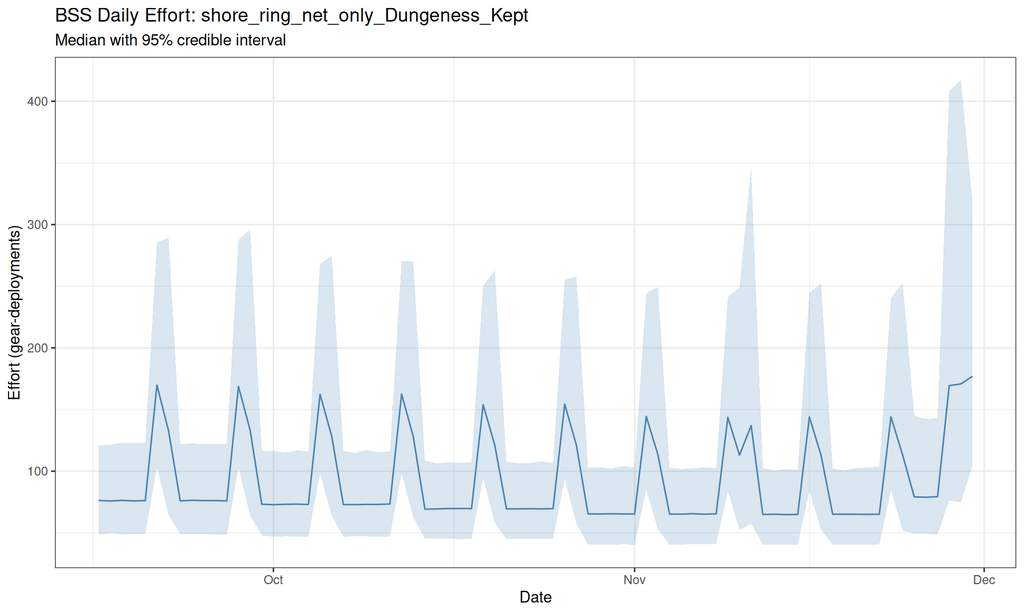

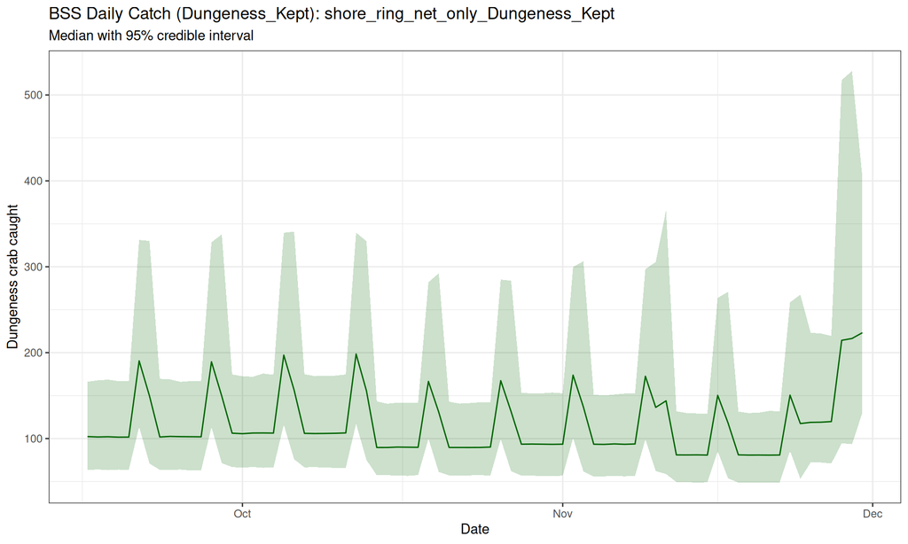

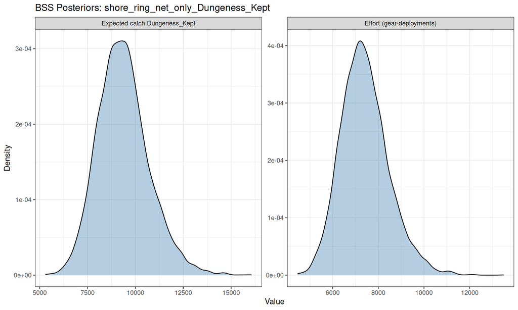

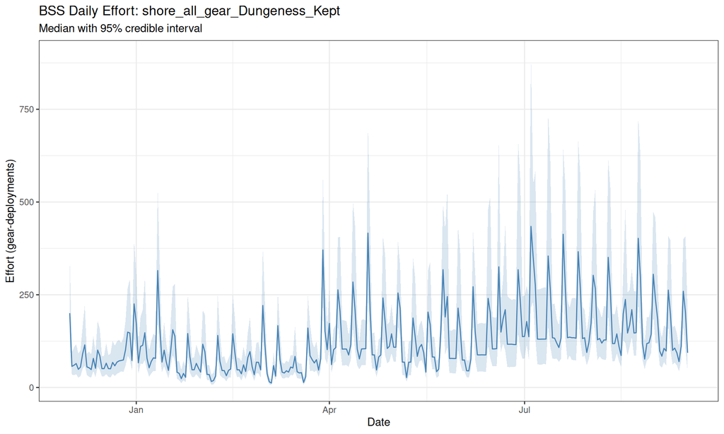

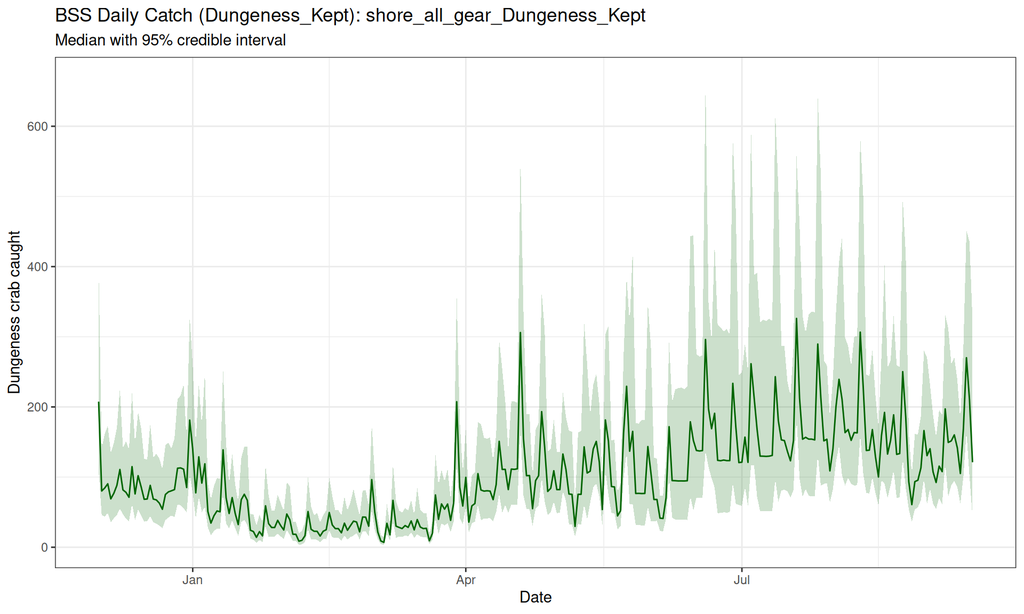

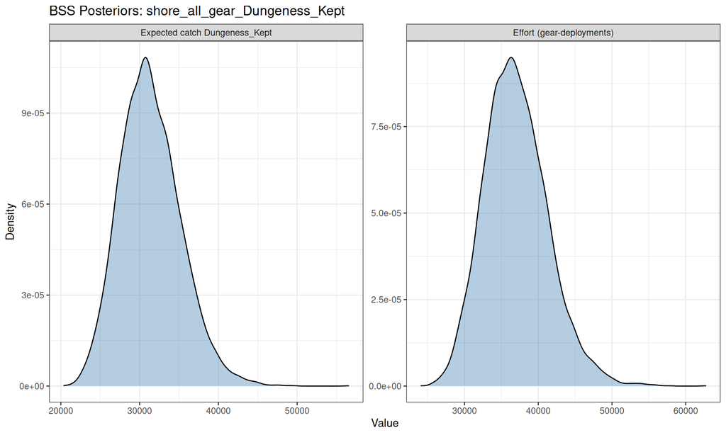

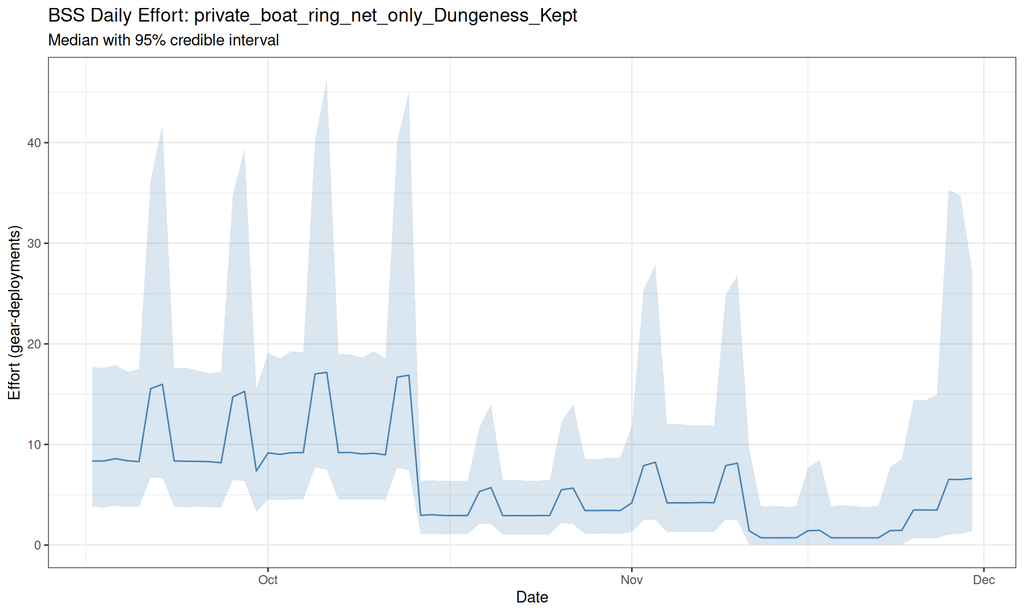

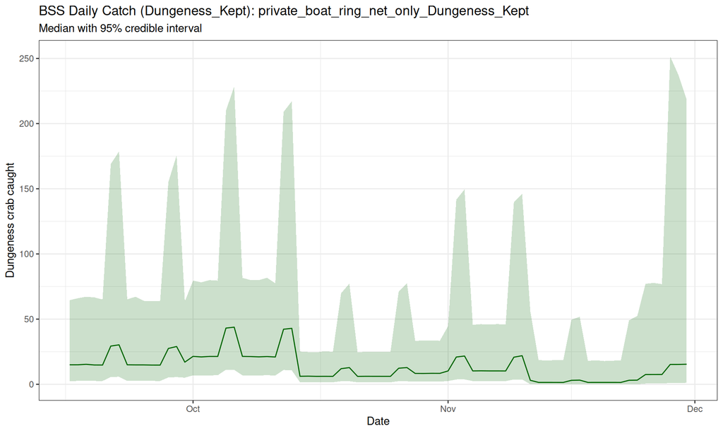

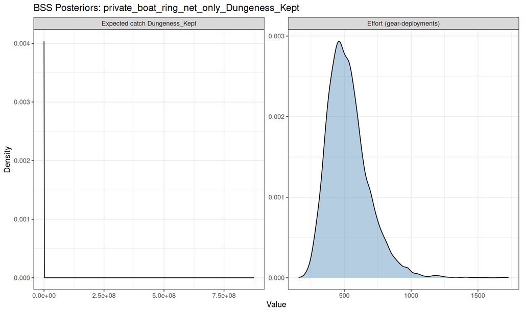

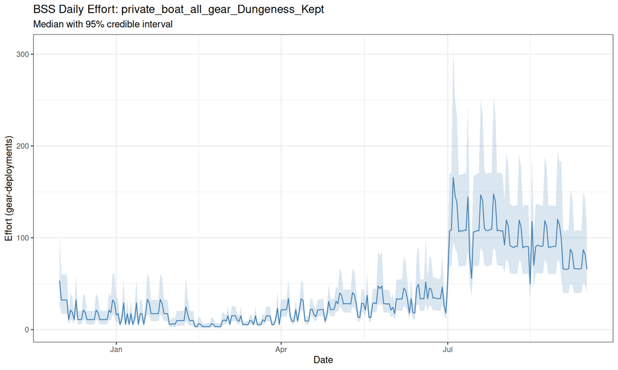

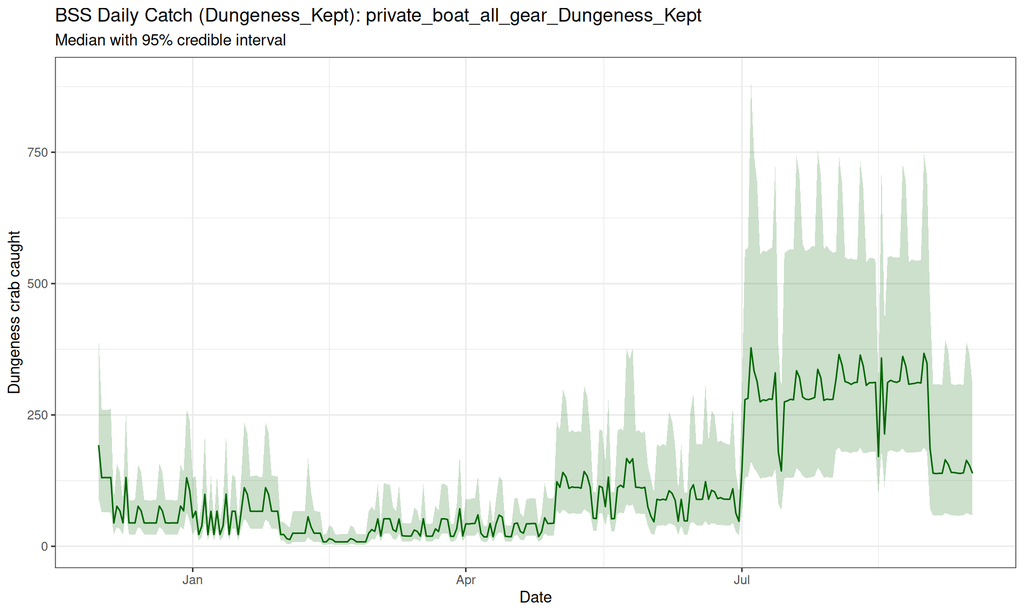

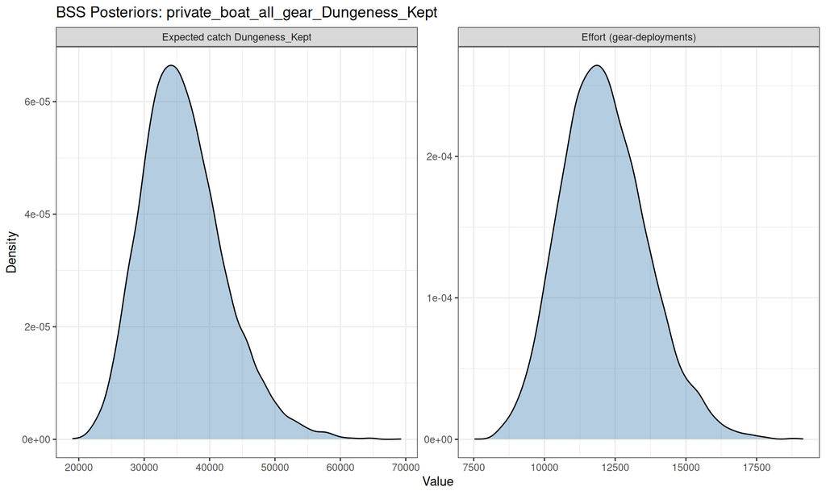

```r
      C_gear_draws <- rstan::extract(fit, "C_sum_gear")$C_sum_gear  # [draws, G_gear]
      gear_labels <- bss_data$.gear_type_labels

      bss_all[[label]] <- list(
        C_sum = quantile(C_draws, c(0.025,0.5,0.975)),
        C_expected_sum = quantile(C_exp_draws, c(0.025,0.5,0.975)),
        E_sum = quantile(E_draws, c(0.025,0.5,0.975)),
        C_draws = C_draws, C_exp_draws = C_exp_draws, C_pred_draws = C_pred_draws, E_draws = E_draws, tau_draws = tau_draws,
        C_gear_draws = C_gear_draws,
        gear_type_labels = gear_labels,
        fit = fit, pe_fallback = FALSE,
        # Carried for the shared diagnostics in 03_R_functions (PPC, effort
        # overdispersion decomposition, O1-O13, PSIS-LOO). Without these the
        # writers silently skip, so they are stored on the fit entry.
        bss_data = bss_data, days_ss = days_ss,
        population = pop, subseason = ss$name, catch_group = cg
      )

      # --- BSS PLOTS for this fit ---

      # Daily effort posteriors (ribbon plot)
      E_bss <- rstan::extract(fit, "E")$E  # [draws, S, D, G]
      E_daily <- tibble(
        event_date = days_ss$event_date,
        median = apply(E_bss[,1,,1], 2, median),
        lo95 = apply(E_bss[,1,,1], 2, quantile, 0.025),
        hi95 = apply(E_bss[,1,,1], 2, quantile, 0.975)
      )

      p_bss_eff <- E_daily |>
        left_join(days_ss |> select(event_date, day_type), by = "event_date") |>
        ggplot(aes(x = event_date)) +
        geom_ribbon(aes(ymin = lo95, ymax = hi95), alpha = 0.2, fill = "steelblue") +
        geom_line(aes(y = median), color = "steelblue") +
        labs(title = sprintf("BSS Daily Effort: %s", label),
             subtitle = "Median with 95% credible interval",
             x = "Date", y = "Effort (gear-deployments)") +
        theme_bw()
      ggsave(file.path(output_dir, paste0("plot_bss_effort_", label, ".png")),
             p_bss_eff, width = 10, height = 6)
      print(p_bss_eff)

      # Daily catch posteriors
      # v5.2: C_total is now the expected value (smooth trajectory, no Poisson noise).
      # Uses C_total for trajectory plots; the season total is C_expected_sum (B44).
      C_total_bss <- rstan::extract(fit, "C_total")$C_total  # [draws, D]
      C_daily <- tibble(
        event_date = days_ss$event_date,
        median = apply(C_total_bss, 2, median),
        lo95 = apply(C_total_bss, 2, quantile, 0.025),
        hi95 = apply(C_total_bss, 2, quantile, 0.975)
      )

      p_bss_catch <- C_daily |>
        ggplot(aes(x = event_date)) +
        geom_ribbon(aes(ymin = lo95, ymax = hi95), alpha = 0.2, fill = "darkgreen") +
        geom_line(aes(y = median), color = "darkgreen") +
        labs(title = sprintf("BSS Daily Catch (%s): %s", cg, label),
             subtitle = "Median with 95% credible interval",
             x = "Date", y = "Dungeness crab caught") +
        theme_bw()
      ggsave(file.path(output_dir, paste0("plot_bss_catch_", label, ".png")),
             p_bss_catch, width = 10, height = 6)
      print(p_bss_catch)

      # Season total posterior densities
      p_bss_post <- tibble(C_expected_sum = C_exp_draws, E_sum = E_draws) |>
        pivot_longer(everything(), names_to = "param", values_to = "value") |>
        ggplot(aes(x = value)) +
        geom_density(fill = "steelblue", alpha = 0.4) +
        facet_wrap(~param, scales = "free", labeller = labeller(
          param = c(C_expected_sum = paste("Expected catch", cg), E_sum = "Effort (gear-deployments)")
        )) +
        labs(title = sprintf("BSS Posteriors: %s", label), x = "Value", y = "Density") +
        theme_bw()
      ggsave(file.path(output_dir, paste0("plot_bss_posteriors_", label, ".png")),
             p_bss_post, width = 12, height = 5)
      print(p_bss_post)

      # Save daily CSVs
      write.csv(E_daily, file.path(output_dir, paste0("bss_daily_effort_", label, ".csv")), row.names=FALSE)
      write.csv(C_daily, file.path(output_dir, paste0("bss_daily_catch_", label, ".csv")), row.names=FALSE)

    }
  }
}
```

```r
timer_stop("5_BSS_model_runs")

# improvement 7: persist the ladder (one row per attempt, with the gate verdict that
# decided whether to escalate).
ar_escalation_df <- if (length(ar_escalation_log)) bind_rows(ar_escalation_log) else NULL
# 2026-09-04: mark the rung whose fit was actually kept. This track wrote `selected` as a
# column of FALSE and never set it, so its ar_escalation_log.csv could not answer the one
# question the file exists to answer. Same rule as the pooled driver: match on the recorded
# attempt index, never on the resolution string.
if (!is.null(ar_escalation_df) && nrow(ar_escalation_df)) {
  for (.lb in unique(ar_escalation_df$fit)) {
    .ka <- .kept_attempt[[.lb]] %||% NA_integer_
    .i <- if (!is.na(.ka)) which(ar_escalation_df$fit == .lb & ar_escalation_df$attempt == .ka) else integer(0)
    if (length(.i)) ar_escalation_df$selected[.i] <- TRUE
  }
}
if (!is.null(ar_escalation_df))
  write.csv(ar_escalation_df, file.path(output_dir, "ar_escalation_log.csv"), row.names = FALSE)
```

## 5. Convergence gate and model selection

The scale-aware gate decides, per fit, whether to report the Bayesian posterior or fall back to the PE. A fit passes only if R-hat is below 1.01, effective sample size is above 400, the divergent fraction is under the backstop, and the divergent draws do not move the reported totals by more than 0.10 posterior standard deviations. **If a component reads PE here, its Bayesian fit did not clear the gate;** that is expected for data-thin components and is not an error.

```r
# ---- 7.6b CONVERGENCE GATE (B1.8, scale-aware; shared in 03_R_functions) ----
# Decide PE-vs-BSS per fit BEFORE any reported total is assembled. bss_compute_gate
# and bss_use_pe_for live in 03_R_functions/bss_convergence_gate.R (shared with the
# pooled track). A fit reports BSS only if it passes the gate; otherwise the
# reported-estimate sections below fall back to PE. Diagnostic sections still key
# off pe_fallback so a fitted-but-gate-failed component keeps its per-fit outputs.
message("\n", strrep("=",60), "\n CONVERGENCE GATE\n", strrep("=",60), "\n")
```

```r
for(label in names(bss_all)) {
  gi <- bss_compute_gate(
    bss_all[[label]], label,
    catch_par        = "C_expected_sum",
    effort_par       = "E_sum",
    max_impact_sd    = params$max_divergence_total_impact_sd %||% 0.10,
    max_div_fraction = params$max_divergence_fraction %||% 0.05,
    ar_resolution    = ar_resolutions[[label]] %||% NA_character_
  )
  bss_all[[label]]$gate_info <- gi
  bss_all[[label]]$use_bss   <- isTRUE(gi$pass_convergence)
}
```

```
##   shore_ring_net_only_Dungeness_Kept: 21/8000 divergent (0.3%); impact C/E = 0.0002/0.0008 SD; level-distortion C/E = 1.2%/1.1%
##   shore_all_gear_Dungeness_Kept: 7/8000 divergent (0.1%); impact C/E = 0.0001/0.0001 SD; level-distortion C/E = 0.8%/2.0%
##   private_boat_ring_net_only_Dungeness_Kept: 3/8000 divergent (0.0%); impact C/E = 0.0000/0.0002 SD; level-distortion C/E = 64.5%/10.4%
```

## 6. Headline result: port total

The season harvest estimate: the sum of all components, reported as expected catch with a 95 percent credible interval. This is the number to cite, read together with the convergence and PE-vs-BSS sections. Components that passed the gate contribute their Bayesian posterior; components that did not contribute their PE point. **Cross-check:** the port total and the boat should land within a few percent of the pooled CPUE model’s run.

```r
# ---- 7.7 COMBINED BSS PORT TOTAL ----
timer_start("6_outputs")
message("\n", strrep("=",60), "\n COMBINED RESULTS\n", strrep("=",60), "\n")
```

```r
# A38 (2026-10-16, closes D44): pair each listed population's components comonotonically in tau_bar
# before anything sums draws across components, so the shared prior centre of their turnover is
# carried as shared (bss_port_tau_coupling.R; port_tau_coupling = "none" leaves the pairing as it
# was, bit for bit). The re-indexed components carry draw_perm, which the monthly block applies.
bss_all <- bss_couple_component_draws(bss_all, params)
```

```
##   Port total pairing (A38, port_tau_coupling = comonotone): shore_ring_net_only_Dungeness_Kept re-indexed to shore_all_gear_Dungeness_Kept's tau_bar quantiles.
```

```r
n_draws_max <- max(sapply(bss_all, function(b) {
  if(bss_use_pe_for(b)) return(0)   # B1.8: a gate-failed fit contributes no BSS draws
  length(b$C_exp_draws)
}))
if(n_draws_max == 0) n_draws_max <- params$bss_chains * (params$bss_iter_default - params$bss_warmup_default)

.cc_draws_by_cg <- list()   # 2026-09-28 (B46): the census draws, kept for the season totals below
for(cg in bss_catch_groups) {
  bss_C_total <- rep(0, n_draws_max)       # expected catch (the headline, as on the pooled track)
  bss_C_pred_total <- rep(0, n_draws_max)  # predictive catch
  bss_E_total <- rep(0, n_draws_max)

  for(pop in c("shore","private_boat")) {
    for(ss in subseasons) {
      label <- paste0(pop, "_", ss$name, "_", cg)
      pe_label <- paste0(pop, "_", ss$name)
      b <- bss_all[[label]]

      if(bss_use_pe_for(b)) {   # B1.8: PE if insufficient data OR failed the gate
        bss_C_total <- bss_C_total + (pe_all[[pe_label]][[cg]] %||% 0)
        bss_C_pred_total <- bss_C_pred_total + (pe_all[[pe_label]][[cg]] %||% 0)
        bss_E_total <- bss_E_total + pe_all[[pe_label]]$effort_total
      } else {
        n <- length(b$C_exp_draws)
        idx <- rep_len(1:n, n_draws_max)
        bss_C_total <- bss_C_total + b$C_exp_draws[idx]
        bss_C_pred_total <- bss_C_pred_total + (b$C_pred_draws %||% b$C_draws)[idx]
        bss_E_total <- bss_E_total + b$E_draws[idx]
      }
    }
  }
  # Review item 4 (2026-09-08/09), split in two on 2026-09-11: the commercial part is a
  # census (a constant), the charter part an expansion. carried_se is what enters the port
  # interval; census_uncertainty selects it ("charter" ships). Draws are clamped at
  # observed_dung (the commercial census plus the charter crab actually observed).
  .cc <- pe_all$comm_charter
  .cc_draws <- rep(.cc[[cg]] %||% 0, n_draws_max)
  if (cg == "Dungeness_Kept" && is.finite(.cc$carried_se %||% NA) && (.cc$carried_se %||% 0) > 0) {
    # 2026-09-26 (B38): a reproducible port total; B46 (2026-09-28): the caller's RNG restored.
    .cc_draws <- bss_with_seed(params$bss_seed %||% 1L, pmax(rnorm(n_draws_max, .cc$Dungeness_Kept, .cc$carried_se), .cc$observed_dung %||% 0))
    message(sprintf(paste0("  Census enters the port interval with SE %s under census_uncertainty = '%s' (total SE %s: charter expansion %s, ",
                           "commercial per-vessel mean %s; census_expansion = '%s', %d unsampled calendar days)."),
                    format(round(.cc$carried_se), big.mark = ","), .cc$census_uncertainty %||% "charter",
                    format(round(.cc$Dungeness_Kept_se %||% 0), big.mark = ","), format(round(.cc$charter_se %||% 0), big.mark = ","),
                    format(round(.cc$commercial_se %||% 0), big.mark = ","), .cc$census_expansion %||% "none", sum(!.cc$daily_full$observed)))
  }
  bss_C_total <- bss_C_total + .cc_draws
  bss_C_pred_total <- bss_C_pred_total + .cc_draws
  bss_E_total <- bss_E_total + pe_all$comm_charter$effort_total
  .cc_draws_by_cg[[cg]] <- .cc_draws

  # 2026-09-28 (B44): the same rows, labels and quantity as the pooled track's
  # port_total_*.csv (Effort, Expected_Catch, Predictive_Catch), so the cross-check reads
  # like for like. Effort is gear-deployments on both tracks.
  final_table <- tibble(
    Catch_Group = cg,
    Estimate = c("Effort", "Expected_Catch", "Predictive_Catch"),
    PE = c(round(pe_port_total("effort_total")),
           round(pe_port_total(cg)),
           NA),
    BSS_median = c(round(median(bss_E_total)), round(median(bss_C_total)), round(median(bss_C_pred_total))),
    BSS_lo95 = c(round(quantile(bss_E_total,0.025)), round(quantile(bss_C_total,0.025)), round(quantile(bss_C_pred_total,0.025))),
    BSS_hi95 = c(round(quantile(bss_E_total,0.975)), round(quantile(bss_C_total,0.975)), round(quantile(bss_C_pred_total,0.975)))
    ,
    # F5: this column is NOT pure BSS. It is the gate-selected combination:
    # BSS draws where the convergence gate passed, PE where it failed or data
    # were insufficient, and the commercial/charter census. As of v5.5 both shore
    # and boat effort are on gear-deployments, so the Effort row is a single unit.
    composition = "BSS where gate passed; PE otherwise; census for comm/charter",
    effort_units_note = "Effort row is gear-deployments for both shore and boat (v5.5+)"
  )

  message(sprintf("\n--- Port Total: %s ---\n", cg))
  write.csv(final_table, file.path(output_dir, paste0("port_total_",cg,".csv")), row.names=FALSE)
  if (cg == "Dungeness_Kept") {
    .port_total_disp  <- final_table
    .tau_port_draws   <- bss_C_total   # combined port catch draws (for the tau diagnostic)
  }
}
```

```r
# Headline table as a clean captioned table (auto-printed at chunk top level).
if (exists(".port_total_disp")) report_table(.port_total_disp,
  caption = "Port total: PE, BSS median, and 95% credible interval (combined effort and catch)")
```

Port total: PE, BSS median, and 95% credible interval (combined effort and catch)

| Catch_Group | Estimate | PE | BSS_median | BSS_lo95 | BSS_hi95 | composition | effort_units_note |
| --- | --- | --- | --- | --- | --- | --- | --- |
| Dungeness_Kept | Effort | 61,099 | 56,989 | 47,773 | 68,299 | BSS where gate passed; PE otherwise; census for comm/charter | Effort row is gear-deployments for both shore and boat (v5.5+) |
| Dungeness_Kept | Expected_Catch | 88,758 | 86,285 | 72,656 | 104,152 | BSS where gate passed; PE otherwise; census for comm/charter | Effort row is gear-deployments for both shore and boat (v5.5+) |
| Dungeness_Kept | Predictive_Catch | - | 86,277 | 72,536 | 104,371 | BSS where gate passed; PE otherwise; census for comm/charter | Effort row is gear-deployments for both shore and boat (v5.5+) |

### 6a. Season totals

Per-season totals, written to `season_totals.csv` every run (and shown here when the run spans more than one season). Since 2026-09-28 (B46) the gear track writes them too, from the same code as the pooled track.

Port interval under the shipped pairing (port_tau_coupling = comonotone): 86,285 [72,656, 104,152], SD 8,748,803; under the independent pairing: 86,306 [73,381, 103,740], SD 8,748,785.

## 6b. Boat `tau_boat` prior sensitivity (optional)

The boat harvest is proportional to the boat deployment turnover `tau_boat` whenever no in-window boat ingress/egress days pin it (as on the 2024-25 development season, with 0 boat I/E days; the count for this run’s fit is used below), so the boat total rests on the `tau_boat` prior (GR-12). With `run_config$diagnose_tau_sensitivity = TRUE` this section projects the boat and port totals across a grid of `tau_boat` prior means **in a single run (no refit)**, and states whether the projection is exact (tau prior-dominated) or an upper bound. For the exact multi-refit check, source `06_diagnostics/run_tau_sweep.R`. **Healthy:** if the boat scales ~linearly with `tau_boat`, the boat is prior-driven and the field priority is boat I/E (egress-classification) coverage; if it barely moves, tau is data-identified and the prior is not the lever.

```r
if (isTRUE(params$diagnose_tau_sensitivity)) {
  # 2026-09-28 (B46): every private-boat ALL-GEAR sub-season, found from the sub-season list
  # (a multi-season span names them all_gear_<season>; the key was hard-coded to the scalar
  # "all_gear"), and the boat I/E day count read from the fit's own Stan data (IE_n; it was
  # read from an n_ie_obs field no fit entry carries, so it was always 0).
  .boat_keys <- paste0("private_boat_", vapply(Filter(function(z) identical(z$gear_regime %||% "all_gear", "all_gear"),
                                                        subseasons), function(z) z$name, character(1)), "_Dungeness_Kept")
  .ran <- FALSE
  for (boat_key in .boat_keys) {
  b_boat   <- bss_all[[boat_key]]
  if (!is.null(b_boat) && !bss_use_pe_for(b_boat) && exists(".tau_port_draws")) {
    .ran <- TRUE
    if (length(.boat_keys) > 1) cat(sprintf("\n**%s**\n\n", boat_key))
    n_draws_max <- length(.tau_port_draws)
    nb          <- length(b_boat$C_exp_draws)
    # Boat's aligned contribution to the port draws (same alignment and the same expected
    # catch as sec 6), so the projection swaps only the boat term.
    boat_draws  <- b_boat$C_exp_draws[rep_len(1:nb, n_draws_max)]
    n_ie_boat   <- as.integer(b_boat$bss_data$IE_n %||% 0L)
    tau_sens <- diagnose_tau_boat_sensitivity(
      boat = b_boat, port_C_draws = .tau_port_draws, boat_C_draws = boat_draws,
      params = params, n_ie_boat = n_ie_boat, output_dir = output_dir)
    if (!is.null(tau_sens$table)) {
      cat(paste(knitr::kable(
        tau_sens$table |> dplyr::select(tau_boat_prior_mu, boat_catch_median,
          boat_lo95, boat_hi95, boat_pct_change, port_total_median, port_pct_change),
        caption = sprintf("Projected boat and port totals across the tau_boat prior grid (%s).", boat_key),
        format.args = list(big.mark = ",")), collapse = "\n"), "\n\n")
      cat("*", tau_sens$note, "*\n\n", sep = "")
    } else {
      cat("_", tau_sens$note, "_\n\n", sep = "")
    }
  }
  }
  if (!.ran)
    cat("_Boat tau sensitivity not applicable (every boat all-gear fit used the PE fallback, or no port draws were stashed)._\n\n")
} else {
  cat("_Set `diagnose_tau_sensitivity = TRUE` in run_config.R to project the boat and port sensitivity to the `tau_boat` prior (single run, no refit). Writes `tau_boat_sensitivity.csv`._\n\n")
}
```

Projected boat and port totals across the tau_boat prior grid (private_boat_all_gear_Dungeness_Kept).

| tau_boat_prior_mu | boat_catch_median | boat_lo95 | boat_hi95 | boat_pct_change | port_total_median | port_pct_change |
| --- | --- | --- | --- | --- | --- | --- |
| 2.0 | 23,333 | 16,794 | 33,123 | -34.0 | 74,209 | -14.0 |
| 2.4 | 28,000 | 20,153 | 39,747 | -20.8 | 78,914 | -8.5 |
| 2.7 | 31,500 | 22,672 | 44,716 | -10.9 | 82,431 | -4.5 |
| 3.0 | 35,000 | 25,191 | 49,684 | -1.0 | 85,931 | -0.4 |
| 3.4 | 39,666 | 28,550 | 56,309 | 12.2 | 90,584 | 5.0 |

*tau_boat prior mean = 3.03 (sigma 0.50). Boat catch is proportional to tau_boat under prior dominance; this run is NOT prior-dominated (the OSP/trailer overlap or boat I/E identifies tau through shared_tau), so treat the projection as an UPPER bound and confirm with run_tau_sweep.R. Across tau_boat in [2.00, 3.40] the port total spans ~19% of its base. L posterior day-mean 3.02 vs prior mean 3.03; posterior/prior log-SD ratio 0.28; boat I/E days = 0.*

## 7. Monthly estimates

The season total broken out by month, with per-month credible intervals, showing the within-season trajectory. **Healthy:** the widest intervals fall on the thinly sampled summer months, where the process model imputes the most.

```r
# ===========================================================================
# 7.8 MONTHLY ESTIMATES WITH UNCERTAINTY
# v5.1: Uses C_total (vector[D]) instead of C[S][D,G]
# ===========================================================================

message("\n", strrep("=",60), "\n MONTHLY ESTIMATES\n", strrep("=",60), "\n")
```

```r
days_full <- prep_days_crab(params$est_date_start, params$est_date_end,
                            params, L_eff_model)

month_lookup <- days_full |>
  mutate(month_label = format(event_date, "%Y-%m")) |>
  select(event_date, month_label)

all_months <- sort(unique(month_lookup$month_label))
monthly_C_draws <- matrix(0, nrow = n_draws_max, ncol = length(all_months),
                          dimnames = list(NULL, all_months))
monthly_E_draws <- matrix(0, nrow = n_draws_max, ncol = length(all_months),
                          dimnames = list(NULL, all_months))

for(cg in bss_catch_groups) {
  for(pop in c("shore","private_boat")) {
    for(ss in subseasons) {
      label <- paste0(pop, "_", ss$name, "_", cg)
      pe_label <- paste0(pop, "_", ss$name)
      b <- bss_all[[label]]

      days_ss <- prep_days_crab(ss$start, ss$end, params, L_eff_model)
      days_ss$month_label <- format(days_ss$event_date, "%Y-%m")

      if(bss_use_pe_for(b)) {   # B1.8: PE if insufficient data OR failed the gate
        # B44 (2026-09-28): the PE's own strata, spread over their calendar days and summed
        # by month (pe_monthly_split.R). The months add up to the component totals exactly
        # and carry each cell's own CPUE; the effort-share split this replaced assumed one
        # CPUE for the whole sub-season and weighted months by their sampled days only.
        monthly_pe <- pe_monthly_split(pe_all[[pe_label]], days_ss, cg)

        for(m in monthly_pe$month_label) {
          if(m %in% all_months) {
            i_m <- monthly_pe$month_label == m
            monthly_C_draws[, m] <- monthly_C_draws[, m] + monthly_pe$month_catch[i_m]
            monthly_E_draws[, m] <- monthly_E_draws[, m] + monthly_pe$month_effort[i_m]
          }
        }

      } else {
        # 2026-09-28 (B44): EXPECTED daily catch (C_total, no Poisson noise), as the pooled
        # track's monthly block uses C_expected, so the monthly figures sum to the port
        # total's quantity. (This used C_gear_pred, the predictive daily catch.)
        C_daily_mat <- rstan::extract(b$fit, "C_total")$C_total  # [draws, D]
        E_bss <- rstan::extract(b$fit, "E")$E  # [draws, S, D, G]
        E_daily_mat <- E_bss[,1,,1]
        n_fit_draws <- nrow(C_daily_mat)

        for(m in unique(days_ss$month_label)) {
          day_idx <- which(days_ss$month_label == m)
          if(length(day_idx) == 0) next

          if(length(day_idx) == 1) {
            month_C <- C_daily_mat[, day_idx]
            month_E <- E_daily_mat[, day_idx]
          } else {
            month_C <- rowSums(C_daily_mat[, day_idx])
            month_E <- rowSums(E_daily_mat[, day_idx])
          }

          idx <- rep_len(b$draw_perm %||% seq_len(n_fit_draws), n_draws_max)   # A38 (2026-10-16): the port total's pairing (bss_port_tau_coupling.R)
          if(m %in% all_months) {
            monthly_C_draws[, m] <- monthly_C_draws[, m] + month_C[idx]
            monthly_E_draws[, m] <- monthly_E_draws[, m] + month_E[idx]
          }
        }
      }
    }
  }
}

# Add commercial/charter to census months
if(!is.null(pe_all$comm_charter$daily_est)) {
  comm_daily <- pe_all$comm_charter$daily_est |>
    mutate(month_label = format(date, "%Y-%m"))

  comm_total <- pe_all$comm_charter$Dungeness_Kept
  total_sampled_dung <- sum(comm_daily$est_dung)
  if(total_sampled_dung > 0) {
    for(m in unique(comm_daily$month_label)) {
      if(m %in% all_months) {
        share <- sum(comm_daily$est_dung[comm_daily$month_label == m]) / total_sampled_dung
        monthly_C_draws[, m] <- monthly_C_draws[, m] + comm_total * share
      }
    }
  }
}

monthly_summary <- tibble(
  Month = all_months,
  BSS_Catch_median = apply(monthly_C_draws, 2, median),
  BSS_Catch_lo95   = apply(monthly_C_draws, 2, quantile, 0.025),
  BSS_Catch_hi95   = apply(monthly_C_draws, 2, quantile, 0.975),
  BSS_Effort_median = apply(monthly_E_draws, 2, median),
  BSS_Effort_lo95   = apply(monthly_E_draws, 2, quantile, 0.025),
  BSS_Effort_hi95   = apply(monthly_E_draws, 2, quantile, 0.975)
) |>
  mutate(across(where(is.numeric), round))

message("\n--- Monthly Dungeness Catch Estimates (all populations combined) ---\n")
```

```r
report_table(monthly_summary |> select(Month, BSS_Catch_median, BSS_Catch_lo95, BSS_Catch_hi95), caption = "Monthly Dungeness catch (all populations combined)")
```

Monthly Dungeness catch (all populations combined)

| Month | BSS_Catch_median | BSS_Catch_lo95 | BSS_Catch_hi95 |
| --- | --- | --- | --- |
| 2024-09 | 2,206 | 1,533 | 3,407 |
| 2024-10 | 4,267 | 3,181 | 6,055 |
| 2024-11 | 4,155 | 2,983 | 6,351 |
| 2024-12 | 9,549 | 8,182 | 11,618 |
| 2025-01 | 7,602 | 6,537 | 9,348 |
| 2025-02 | 1,896 | 1,431 | 2,717 |
| 2025-03 | 2,554 | 1,850 | 3,839 |
| 2025-04 | 4,467 | 3,290 | 6,099 |
| 2025-05 | 7,026 | 5,088 | 10,450 |
| 2025-06 | 6,836 | 4,518 | 10,633 |
| 2025-07 | 14,413 | 9,233 | 23,597 |
| 2025-08 | 15,078 | 10,593 | 22,772 |
| 2025-09 | 4,602 | 3,079 | 7,344 |

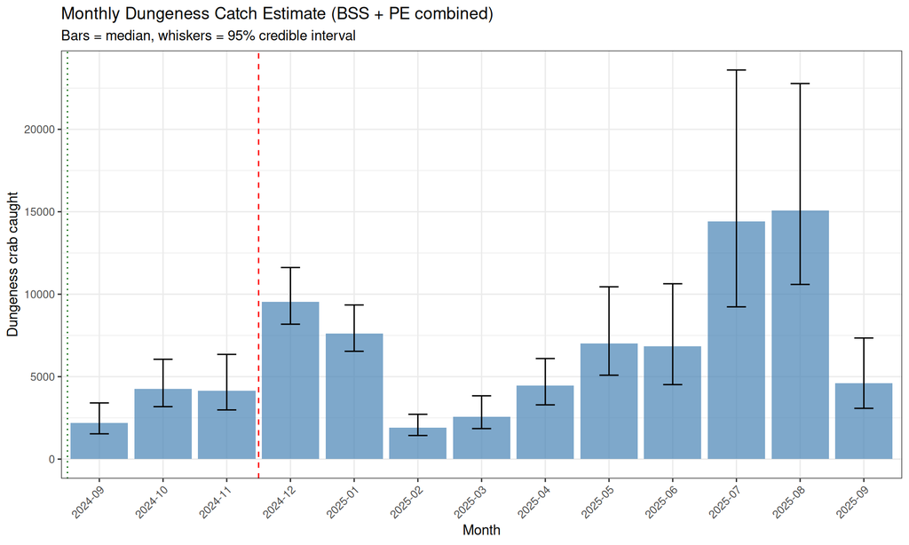

```r
write.csv(monthly_summary, file.path(output_dir, "monthly_estimates.csv"), row.names = FALSE)

# Monthly catch plot
p_monthly <- monthly_summary |>
  mutate(Month = factor(Month, levels = all_months)) |>
  ggplot(aes(x = Month)) +
  geom_col(aes(y = BSS_Catch_median), fill = "steelblue", alpha = 0.7) +
  geom_errorbar(aes(ymin = BSS_Catch_lo95, ymax = BSS_Catch_hi95), width = 0.3) +
  geom_vline(xintercept = which(all_months == format(as.Date(params$pot_closure_start %||% params$est_date_start), "%Y-%m")) - 0.5,
             linetype = "dotted", color = "darkgreen") +
  geom_vline(xintercept = which(all_months == format(as.Date(params$pot_open_date), "%Y-%m")) - 0.5,
             linetype = "dashed", color = "red") +
  labs(title = "Monthly Dungeness Catch Estimate (BSS + PE combined)",
       subtitle = "Bars = median, whiskers = 95% credible interval",
       x = "Month", y = "Dungeness crab caught") +
  theme_bw() +
  theme(axis.text.x = element_text(angle = 45, hjust = 1))
ggsave(file.path(output_dir, "plot_monthly_catch.png"), p_monthly, width = 12, height = 6)
print(p_monthly)
```

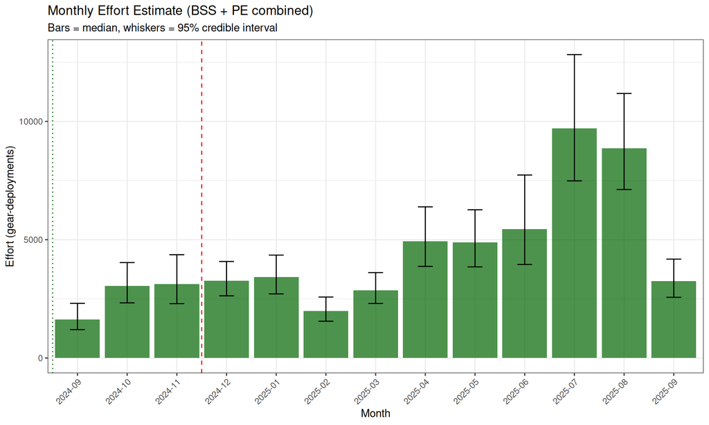

```r
# Monthly effort plot
p_monthly_eff <- monthly_summary |>
  mutate(Month = factor(Month, levels = all_months)) |>
  ggplot(aes(x = Month)) +
  geom_col(aes(y = BSS_Effort_median), fill = "darkgreen", alpha = 0.7) +
  geom_errorbar(aes(ymin = BSS_Effort_lo95, ymax = BSS_Effort_hi95), width = 0.3) +
  geom_vline(xintercept = which(all_months == format(as.Date(params$pot_closure_start %||% params$est_date_start), "%Y-%m")) - 0.5,
             linetype = "dotted", color = "darkgreen") +
  geom_vline(xintercept = which(all_months == format(as.Date(params$pot_open_date), "%Y-%m")) - 0.5,
             linetype = "dashed", color = "red") +
  labs(title = "Monthly Effort Estimate (BSS + PE combined)",
       subtitle = "Bars = median, whiskers = 95% credible interval",
       x = "Month", y = "Effort (gear-deployments)") +
  theme_bw() +
  theme(axis.text.x = element_text(angle = 45, hjust = 1))
ggsave(file.path(output_dir, "plot_monthly_effort.png"), p_monthly_eff, width = 12, height = 6)
print(p_monthly_eff)
```

## 8. Catch by crabbing mode

```r
# ===========================================================================
# 7.9 CATCH BY CRABBING MODE
# ===========================================================================

message("\n", strrep("=",60), "\n CATCH BY CRABBING MODE\n", strrep("=",60), "\n")
```

```r
mode_table <- tibble(
  Mode = c("Shore (Dock/Jetty/Beach)", "Private Boat", "Commercial/Charter", "PORT TOTAL"),
  PE_Catch = c(
    pe_pop_sum("shore", "Dungeness_Kept"),
    pe_pop_sum("private_boat", "Dungeness_Kept"),
    pe_field("comm_charter", "Dungeness_Kept"),
    NA
  ),
  PE_Effort = c(
    pe_pop_sum("shore", "effort_total"),
    pe_pop_sum("private_boat", "effort_total"),
    pe_field("comm_charter", "effort_total"),
    NA
  )
)
mode_table$PE_Catch[4] <- sum(mode_table$PE_Catch[1:3], na.rm = TRUE)
mode_table$PE_Effort[4] <- sum(mode_table$PE_Effort[1:3], na.rm = TRUE)

report_table(mode_table |> mutate(across(where(is.numeric), round)), caption = "Catch by crabbing mode (PE)")
```

Catch by crabbing mode (PE)

| Mode | PE_Catch | PE_Effort |
| --- | --- | --- |
| Shore (Dock/Jetty/Beach) | 42,086 | 46,493 |
| Private Boat | 38,133 | 14,408 |
| Commercial/Charter | 8,538 | 198 |
| PORT TOTAL | 88,758 | 61,099 |

```r
write.csv(mode_table, file.path(output_dir, "catch_by_mode.csv"), row.names = FALSE)
```

## 9. Catch by gear type

```r
# ===========================================================================
# 7.10 BSS CATCH BY GEAR TYPE
# v5.1: PE fallback uses word-boundary regex consistent with BSS
# ===========================================================================

message("\n", strrep("=",60), "\n BSS CATCH BY GEAR TYPE\n", strrep("=",60), "\n")
```

```r
gear_results <- list()

for(pop in c("shore","private_boat")) {
  for(ss in subseasons) {
    label_cg <- paste0(pop, "_", ss$name, "_Dungeness_Kept")
    pe_label <- paste0(pop, "_", ss$name)
    b <- bss_all[[label_cg]]

    if(is.null(b)) next

    if(bss_use_pe_for(b)) {   # B1.8: PE if insufficient data OR failed the gate
      pe_catch_total <- pe_all[[pe_label]]$Dungeness_Kept %||% 0
      # v5.1: Word-boundary regex consistent with BSS classification
      int_ss <- dwg$interview |>
        filter(population == pop,
               between(event_date, ss$start, ss$end),
               dungeness_kept > 0) |>
        mutate(
          has_pot      = as.integer(str_detect(gear_type, "(?i)\\bpot\\b") &
                                    !str_detect(gear_type, "(?i)\\bslip\\s*ring\\b")),
          has_ring_net = as.integer(str_detect(gear_type, "(?i)\\bring\\s*net\\b")),
          has_trap     = as.integer(str_detect(gear_type, "(?i)\\b(trap|star)\\b")),
          has_snare    = as.integer(str_detect(gear_type, "(?i)\\bsnare\\b"))
        )
      # Apply regulatory exclusion consistent with BSS
      gear_exclude_ss <- ss$gear_exclude %||% character(0)
      if(length(gear_exclude_ss) > 0) {
        excl_cols <- c(Pot="has_pot", `Ring Net`="has_ring_net",
                       Trap="has_trap", Snare="has_snare")
        for(gt in gear_exclude_ss) {
          if(gt %in% names(excl_cols)) int_ss[[excl_cols[gt]]] <- 0L
        }
      }
      int_ss <- int_ss |>
        mutate(n_types = pmax(has_pot + has_ring_net + has_trap + has_snare, 1L))
      # Weighted allocation of catch across gear types
      gear_catch_alloc <- c(
        Pot = sum(int_ss$dungeness_kept * int_ss$has_pot / int_ss$n_types),
        `Ring Net` = sum(int_ss$dungeness_kept * int_ss$has_ring_net / int_ss$n_types),
        Trap = sum(int_ss$dungeness_kept * int_ss$has_trap / int_ss$n_types),
        Snare = sum(int_ss$dungeness_kept * int_ss$has_snare / int_ss$n_types)
      )
      gear_catch_alloc <- gear_catch_alloc[gear_catch_alloc > 0]
      total_alloc <- sum(gear_catch_alloc)
      if(total_alloc > 0) {
        props <- gear_catch_alloc / total_alloc
      } else {
        props <- c(Other = 1.0)
      }
      for(gt in names(props)) {
        gear_results[[length(gear_results)+1]] <- tibble(
          population=pop, subseason=ss$name, gear_type=gt,
          BSS_median=NA, BSS_lo95=NA, BSS_hi95=NA,
          PE_catch=round(pe_catch_total * props[gt]),
          method="PE (weighted proportional)"
        )
      }
    } else {
      labels <- b$gear_type_labels
      draws <- b$C_gear_draws
      for(gg in seq_along(labels)) {
        g_draws <- if(is.matrix(draws)) draws[,gg] else draws
        gear_results[[length(gear_results)+1]] <- tibble(
          population=pop, subseason=ss$name, gear_type=labels[gg],
          BSS_median=round(median(g_draws)),
          BSS_lo95=round(quantile(g_draws, 0.025)),
          BSS_hi95=round(quantile(g_draws, 0.975)),
          PE_catch=NA, method="BSS"
        )
      }
    }
  }
}

# Add commercial/charter as Pot
comm_catch <- pe_all$comm_charter$Dungeness_Kept %||% 0
gear_results[[length(gear_results)+1]] <- tibble(
  population="comm_charter", subseason="census", gear_type="Pot",
  BSS_median=NA, BSS_lo95=NA, BSS_hi95=NA,
  PE_catch=round(comm_catch),
  # B46 (2026-09-28): the label follows census_expansion (the shipped "none" is an exact
  # commercial census plus the charter roster expansion, not a day-type stratification)
  method = if (identical(params$census_expansion %||% "none", "none")) "Commercial census + charter expansion" else "Census (day-type stratified)"
)

gear_df <- bind_rows(gear_results)
message("\n--- Catch by Gear Type (BSS where available, PE fallback) ---\n")
```

```r
report_table(gear_df, caption = "Catch by gear type (BSS per-gear where resolved; PE-apportioned otherwise)")
```

Catch by gear type (BSS per-gear where resolved; PE-apportioned otherwise)

| population | subseason | gear_type | BSS_median | BSS_lo95 | BSS_hi95 | PE_catch | method |
| --- | --- | --- | --- | --- | --- | --- | --- |
| shore | ring_net_only | All | 9,276 | 7,011 | 12,293 | - | BSS |
| shore | all_gear | All | 31,093 | 24,592 | 39,660 | - | BSS |
| private_boat | ring_net_only | All | 1,268 | 504 | 4,582 | - | BSS |
| private_boat | all_gear | All | 35,312 | 25,442 | 50,174 | - | BSS |
| comm_charter | census | Pot | - | - | - | 8,538 | Commercial census + charter expansion |

```r
write.csv(gear_df, file.path(output_dir, "catch_by_gear_type_detail.csv"), row.names = FALSE)

# GR-7 reconciliation gate: per-gear BSS catches must sum to each population's all-gear
# total (identical draws in the Stan generated quantities). max_abs_draw_diff ~ 0 = valid.
reco_rows <- list()
for (pop in c("shore","private_boat")) for (ss in subseasons) {
  b <- bss_all[[paste0(pop, "_", ss$name, "_Dungeness_Kept")]]
  if (is.null(b) || bss_use_pe_for(b) || is.null(b$C_gear_draws)) next
  if (is.matrix(b$C_gear_draws) && ncol(b$C_gear_draws) > 1) {
    reco_rows[[length(reco_rows)+1]] <- tibble(
      fit = short_fit(paste0(pop, "_", ss$name, "_Dungeness_Kept")),
      G = ncol(b$C_gear_draws),
      C_sum_median = round(median(b$C_draws)),
      sum_gear_median = round(median(rowSums(b$C_gear_draws))),
      max_abs_draw_diff = signif(max(abs(rowSums(b$C_gear_draws) - b$C_draws)), 3))
  }
}
if (length(reco_rows) > 0) report_table(bind_rows(reco_rows),
  caption = "GR-7 reconciliation: per-gear catches sum to the all-gear total (max_abs_draw_diff ~ 0 = valid).")

# Port-level summary by gear type
gear_port <- gear_df |>
  mutate(best_catch = coalesce(BSS_median, PE_catch)) |>
  group_by(gear_type) |>
  summarise(
    catch = sum(best_catch, na.rm=TRUE),
    has_BSS = any(method == "BSS"),
    .groups = "drop"
  ) |>
  arrange(desc(catch)) |>
  mutate(proportion = round(catch / sum(catch), 3))

message("\n--- Port Total by Gear Type ---\n")
```

```r
report_table(gear_port, caption = "Port total by gear type")
```

Port total by gear type

| gear_type | catch | has_BSS | proportion |
| --- | --- | --- | --- |
| All | 76,949 | TRUE | 0.9 |
| Pot | 8,538 | FALSE | 0.1 |

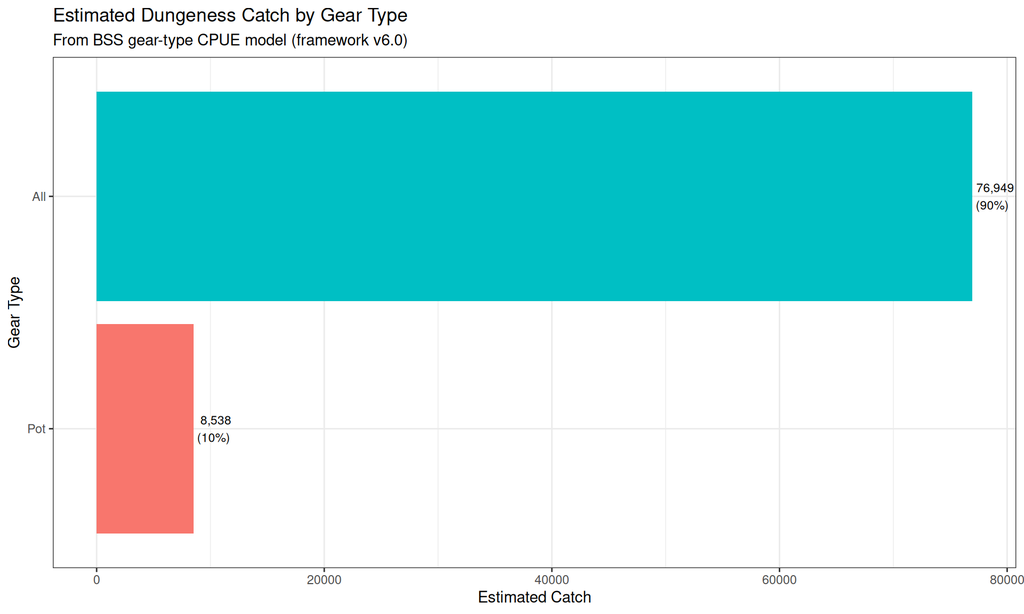

```r
write.csv(gear_port, file.path(output_dir, "catch_by_gear_type.csv"), row.names = FALSE)

# Gear type bar chart
p_gear <- gear_port |>
  mutate(gear_type = fct_reorder(gear_type, catch)) |>
  ggplot(aes(x = gear_type, y = catch, fill = gear_type)) +
  geom_col() +
  geom_text(aes(label = sprintf("%s\n(%.0f%%)", format(catch, big.mark=","), proportion*100)),
            hjust = -0.1, size = 3) +
  labs(title = "Estimated Dungeness Catch by Gear Type",
       subtitle = "From BSS gear-type CPUE model (framework v6.0)",
       x = "Gear Type", y = "Estimated Catch") +
  theme_bw() +
  theme(legend.position = "none") +
  coord_flip()
ggsave(file.path(output_dir, "plot_catch_by_gear_type.png"), p_gear, width = 10, height = 6)
print(p_gear)
```

```r
message("\n  Gear-type outputs saved.\n")
```

## 10. Convergence report

The per-fit diagnostic table behind the gate decision: R-hat and effective sample size for the summed effort and catch, the worst per-gear-type R-hat, the divergent fraction, and the pass/fail flag. **Healthy:** `pass_convergence` TRUE with R-hat near 1.00 and effective sample size well above 400 on every fit that had sufficient data.

```r
# ===========================================================================
# 7.11 CONVERGENCE REPORT
#
# v5.1: Extended diagnostics - checks C_sum_gear, r_C_gear, sigma_eps_C_gear
#        in addition to C_sum and E_sum (Issue 11)
# v5.2: Divergent transitions now included in pass/fail criterion.
#        Treedepth exceedance warnings added.
# ===========================================================================

message("\n", strrep("=",60), "\n CONVERGENCE REPORT\n", strrep("=",60), "\n")
```

```r
convergence_report <- list()
for(label in names(bss_all)) {
  b <- bss_all[[label]]
  if(!is.null(b$pe_fallback) && b$pe_fallback) {
    convergence_report[[label]] <- tibble(
      fit = label, divergences = NA, treedepth_pct = NA,
      C_sum_rhat = NA, E_sum_rhat = NA, C_sum_neff = NA, E_sum_neff = NA,
      max_gear_rhat = NA, min_gear_neff = NA,
      max_r_C_rhat = NA, max_sigma_C_rhat = NA,
      pass_convergence = FALSE, method_selected = "PE (insufficient data)"
    )
  } else {
    sp <- rstan::get_sampler_params(b$fit, inc_warmup = FALSE)
    n_divergent <- sum(sapply(sp, function(x) sum(x[,"divergent__"])))
    n_treedepth <- sum(sapply(sp, function(x) sum(x[,"treedepth__"] >=
      b$fit@stan_args[[1]]$control$max_treedepth)))
    n_total <- sum(sapply(sp, nrow))

    # Core diagnostics: C_sum and E_sum
    summ_core <- summary(b$fit, pars = c("C_sum","E_sum"))$summary
    rhat_C <- summ_core["C_sum","Rhat"]; rhat_E <- summ_core["E_sum","Rhat"]
    neff_C <- summ_core["C_sum","n_eff"]; neff_E <- summ_core["E_sum","n_eff"]

    # v5.1 Extended: Per-gear-type diagnostics
    summ_gear <- summary(b$fit, pars = "C_sum_gear")$summary
    summ_r_C <- summary(b$fit, pars = "r_C_gear_out")$summary
    summ_sig_C <- summary(b$fit, pars = "sigma_eps_C_gear_out")$summary

    max_gear_rhat <- max(summ_gear[,"Rhat"], na.rm=TRUE)
    min_gear_neff <- min(summ_gear[,"n_eff"], na.rm=TRUE)
    max_r_C_rhat <- max(summ_r_C[,"Rhat"], na.rm=TRUE)
    max_sigma_C_rhat <- max(summ_sig_C[,"Rhat"], na.rm=TRUE)

    # Convergence criteria: ALL monitored parameters must pass
    all_rhats <- c(rhat_C, rhat_E, summ_gear[,"Rhat"],
                   summ_r_C[,"Rhat"], summ_sig_C[,"Rhat"])
    all_neffs <- c(neff_C, neff_E, summ_gear[,"n_eff"])

    pass_rhat <- max(all_rhats, na.rm=TRUE) < 1.01  # v5.4: tightened from 1.05 (Vehtari et al. 2021)
    pass_neff <- min(all_neffs, na.rm=TRUE) > 400
    # B1.8: the PE/BSS decision is the scale-aware gate (bss_compute_gate),
    # already computed and stored on the fit. Use it here so the report's
    # pass_convergence / method_selected match what actually selected PE vs BSS.
    # The gear-type diagnostics above are retained for insight; the divergence
    # fraction and impact values that drove the decision are printed to the
    # console by the gate and stored in b$gate_info.
    gi <- b$gate_info
    pass <- isTRUE(gi$pass_convergence)

    # v5.2: Warn on treedepth exceedances
    if(n_treedepth / n_total > 0.05) {
      message(sprintf("  WARNING: %s - %.1f%% treedepth exceedances (consider increasing max_treedepth)\n",
                  label, n_treedepth / n_total * 100))
    }
    # v5.2: Warn on divergences even if within threshold
    if(n_divergent > 0) {
      message(sprintf("  WARNING: %s - %d divergent transitions detected\n", label, n_divergent))
    }

    convergence_report[[label]] <- tibble(
      fit = label,
      divergences = n_divergent,
      treedepth_pct = round(n_treedepth / n_total * 100, 1),
      C_sum_rhat = round(rhat_C, 4),
      E_sum_rhat = round(rhat_E, 4),
      C_sum_neff = round(neff_C),
      E_sum_neff = round(neff_E),
      max_gear_rhat = round(max_gear_rhat, 4),
      min_gear_neff = round(min_gear_neff),
      max_r_C_rhat = round(max_r_C_rhat, 4),
      max_sigma_C_rhat = round(max_sigma_C_rhat, 4),
      pass_convergence = pass,
      method_selected = if(pass) "BSS" else "PE (convergence fail)"
    )

    # Warn if gear-type parameters failed but aggregates passed
    if(!pass && max(c(rhat_C, rhat_E), na.rm=TRUE) < 1.01) {
      message(sprintf("  WARNING: %s - C_sum/E_sum converged but gear-type parameters did not.\n", label))
      message(sprintf("    max gear Rhat=%.3f, max r_C Rhat=%.3f, max sigma_C Rhat=%.3f\n",
                  max_gear_rhat, max_r_C_rhat, max_sigma_C_rhat))
    }
  }
}
```

```r
convergence_df <- bind_rows(convergence_report)

# F5: the scale-aware gate computed divergence_fraction, impact_C_sd, impact_E_sd
# and the four pass_* flags into b$gate_info, but the report above only carried
# `pass` and `method_selected`. Join the gate columns in so the CSV records WHY a
# component was routed to PE, matching the pooled driver's report.
gate_df <- bind_rows(lapply(names(bss_all), function(l) {
  gi <- bss_all[[l]]$gate_info
  if (is.null(gi)) return(NULL)
  gi |> select(any_of(c("fit","ar_resolution","divergence_fraction",
                        "impact_C_sd","impact_E_sd","distortion_C","distortion_E",
                        "pass_rhat","pass_neff","pass_div_fraction","pass_impact")))
}))
if (nrow(gate_df) > 0) {
  convergence_df <- convergence_df |>
    left_join(gate_df, by = "fit", suffix = c("", "_gate"))
}
message("\n")
```

```r
report_table(convergence_df, caption = "Convergence and gate report")
```

Convergence and gate report

| fit | divergences | treedepth_pct | C_sum_rhat | E_sum_rhat | C_sum_neff | E_sum_neff | max_gear_rhat | min_gear_neff | max_r_C_rhat | max_sigma_C_rhat | pass_convergence | method_selected | ar_resolution | divergence_fraction | impact_C_sd | impact_E_sd | distortion_C | distortion_E | pass_rhat | pass_neff | pass_div_fraction | pass_impact |
| --- | --- | --- | --- | --- | --- | --- | --- | --- | --- | --- | --- | --- | --- | --- | --- | --- | --- | --- | --- | --- | --- | --- |
| shore_ring_net_only_Dungeness_Kept | 21 | 0 | 1 | 1 | 10,058 | 10,025 | 1 | 10,058 | 1 | 1 | TRUE | BSS | biweekly | 0 | 0 | 0 | 0.01 | 0.01 | TRUE | TRUE | TRUE | TRUE |
| shore_all_gear_Dungeness_Kept | 7 | 0 | 1 | 1 | 9,214 | 9,160 | 1 | 9,214 | 1 | 1 | TRUE | BSS | weekly | 0 | 0 | 0 | 0.01 | 0.02 | TRUE | TRUE | TRUE | TRUE |
| private_boat_ring_net_only_Dungeness_Kept | 3 | 0 | 1 | 1 | 8,008 | 8,600 | 1 | 8,008 | 1 | 1 | TRUE | BSS | biweekly | 0 | 0 | 0 | 0.64 | 0.10 | TRUE | TRUE | TRUE | TRUE |
| private_boat_all_gear_Dungeness_Kept | 0 | 0 | 1 | 1 | 9,324 | 10,522 | 1 | 9,324 | 1 | 1 | TRUE | BSS | monthly | 0 | 0 | 0 | 0.00 | 0.00 | TRUE | TRUE | TRUE | TRUE |

```r
write.csv(convergence_df, file.path(output_dir, "convergence_report.csv"), row.names = FALSE)


# ===========================================================================
# 7.11b EXTENDED DIAGNOSTICS + PSIS-LOO
# Shared writers auto-sourced from 03_R_functions/:
#   write_bss_diagnostics()            structural params, divergence localization,
#                                      PPC calibration + PIT histogram
#   write_effort_overdispersion_diag()  Poisson / NB / latent variance decomposition
#   write_fit_extended_diagnostics()    O1-O9 (E-BFMI, AR paths, per-obs PIT,
#                                      prior-vs-posterior contraction, ...)
#   write_loo_diagnostics()             O13 PSIS-LOO + Pareto-k, from the
#                                      log_lik_gear/trailer/catch added to the
#                                      gear-resolved Stan model.
#
# These run for every fit that PRODUCED draws, including fits the convergence
# gate rejected. That is deliberate: a gate-failed fit reports PE in the totals,
# but its diagnostics are exactly what identify WHY it failed.
# ===========================================================================

message("\n", strrep("=",60), "\n EXTENDED DIAGNOSTICS\n", strrep("=",60), "\n")
```

```r
for(label in names(bss_all)) {
  b <- bss_all[[label]]
  if(is.null(b$fit)) next   # PE-only (insufficient data): no draws to diagnose

  message(sprintf("\n--- diagnostics: %s (%s) ---\n", label,
              if(isTRUE(b$use_bss)) "gate PASS" else "gate FAIL -> reporting PE"))

  # 2026-08-30: the gate verdict travels INTO the per-fit tables (see the pooled driver).
  write_bss_diagnostics(b$fit, b$bss_data, label, output_dir,
                        fit_method = b$gate_info$method_selected %||%
                          (if (isTRUE(b$use_bss)) "BSS" else "PE (convergence fail)"))
  # 2026-09-04: see the note at the same call in BSS-GH-pooled-CPUE-model.Rmd.
  if (isTRUE(params$save_ppc_draws) && !is.null(b$bss_data))
    save_bss_ppc_draws(b$fit, b$bss_data, label, output_dir,
                       max_draws = params$save_ppc_draws_max %||% NULL)
  write_effort_overdispersion_diag(b$fit, b$bss_data, label, output_dir)
  # 2026-08-27: pass the run seed so the diagnostic draw subsampling is reproducible
  # (see the note in save_run_diagnostics.R; the port total stays RNG-sensitive regardless).
  write_fit_extended_diagnostics(b$fit, b$bss_data, b$days_ss, label, output_dir,
                                 seed = params$bss_seed %||% 1L)
  write_loo_diagnostics(b$fit, b$bss_data, b$days_ss, label, output_dir)
  # 2026-09-26 (D31 -> B39): leave-one-WEEK-out PSIS block CV of the effort streams; writes
  # loo_block_<stream>_<label>.csv, tryCatch-wrapped, changes no estimate (bss_block_cv.R).
  write_block_cv_diagnostics(b$fit, b$bss_data, b$days_ss, label, output_dir)
  # F4: CPUE estimator triad, saturation exponent, and the E/h unit assertion.
  # 2026-09-28 (B46): wrapped, as on the pooled track. bss_assert_effort_units() stop()s by
  # design, and an unwrapped error here aborted the render AFTER every fit, losing the rest
  # of the report, run_parameters.txt, session_info.txt and the manifest.
  tryCatch(write_cpue_diagnostics(b, label, output_dir),
           error = function(e)
             message(sprintf("  CPUE diagnostics skipped for %s: %s", label, conditionMessage(e))))
}
```

```
##     [diag] shore_ring_net_only_Dungeness_Kept: 21/8000 divergent (0.3%); distortion C/E = 1.2%/1.1%
##     [diag] PPC coverage (nominal 50/95):
##       gear     50%=54%  95%=98%  (n=52)
##       catch    50%=44%  95%=98%  (n=628)
```

```
##     ppc draws saved: ppc_draws_shore_ring_net_only_Dungeness_Kept.rds (8000 draws, 10 pars, 6.3 MB)
##   shore_ring_net_only_Dungeness_Kept [gear]: n=52 | shares pois/NB/latent = 0.06/0.80/0.13 | pred VMR 13.33 (NB-only 11.81) | PPC cov50 0.54, pit_sd 0.265
##       -> observation NB over-dispersion dominates: lever is r_E / sigma_r_E prior (T1.5 5a; pair with T1.3)
```

```
##     block CV shore_ring_net_only_Dungeness_Kept/gear: 11 weeks, 9 reliable (k <= 0.7), held-out elpd -183.0; leave-out set gear
##   WARNING: shore_ring_net_only_Dungeness_Kept - model CPUE 1.2665 sits 48% of the way from
##            ratio-of-sums (1.2462) toward mean-of-ratios (1.2888).
##            The NB dispersion is pulling lambda_C off the rate scale;
##            check the saturation exponent before trusting the total.
##   WARNING: shore_ring_net_only_Dungeness_Kept - saturation exponent beta = 0.273 (SE 0.065).
##            The likelihood assumes beta = 1 (catch proportional to h).
##            Effort-hours is NOT a valid unit here; use deployments.
```

```
##     [diag] shore_all_gear_Dungeness_Kept: 7/8000 divergent (0.1%); distortion C/E = 0.8%/2.0%
##     [diag] PPC coverage (nominal 50/95):
##       gear     50%=42%  95%=87%  (n=311)
##       catch    50%=46%  95%=98%  (n=1652)
```

```
##     ppc draws saved: ppc_draws_shore_all_gear_Dungeness_Kept.rds (8000 draws, 10 pars, 28.1 MB)
##   shore_all_gear_Dungeness_Kept [gear]: n=311 | shares pois/NB/latent = 0.13/0.45/0.42 | pred VMR 5.70 (NB-only 3.48) | PPC cov50 0.42, pit_sd 0.321
##       -> observation NB over-dispersion dominates: lever is r_E / sigma_r_E prior (T1.5 5a; pair with T1.3)
```

```
##     block CV shore_all_gear_Dungeness_Kept/gear: 38 weeks, 0 reliable (k <= 0.7), held-out elpd 0.0; leave-out set gear
##   WARNING: shore_all_gear_Dungeness_Kept - saturation exponent beta = 0.220 (SE 0.048).
##            The likelihood assumes beta = 1 (catch proportional to h).
##            Effort-hours is NOT a valid unit here; use deployments.
```

```
##     [diag] private_boat_ring_net_only_Dungeness_Kept: 3/8000 divergent (0.0%); distortion C/E = 64.5%/10.4%
##     [diag] PPC coverage (nominal 50/95):
##       trailer  50%=57%  95%=100%  (n=44)
##       osp      50%=44%  95%=100%  (n=18)
##       catch    50%=44%  95%=100%  (n=18)
```

```
##     ppc draws saved: ppc_draws_private_boat_ring_net_only_Dungeness_Kept.rds (8000 draws, 9 pars, 6.4 MB)
##   private_boat_ring_net_only_Dungeness_Kept [trailer]: n=44 | shares pois/NB/latent = 0.37/0.49/0.14 | pred VMR 2.00 (NB-only 1.74) | PPC cov50 0.57, pit_sd 0.255
##       -> observation NB over-dispersion dominates: lever is r_E / sigma_r_E prior (T1.5 5a; pair with T1.3)
```

```
##     block CV private_boat_ring_net_only_Dungeness_Kept/trailer: 11 weeks, 9 reliable (k <= 0.7), held-out elpd -54.3; leave-out set trailer+osp
##     block CV private_boat_ring_net_only_Dungeness_Kept/osp: 5 weeks, 3 reliable (k <= 0.7), held-out elpd -32.4; leave-out set trailer+osp
##     block CV private_boat_ring_net_only_Dungeness_Kept/joint: 11 weeks, 9 reliable (k <= 0.7), held-out elpd -85.8; leave-out set trailer+osp
##   WARNING: private_boat_ring_net_only_Dungeness_Kept - model CPUE 2.4932 sits 360% of the way from
##            ratio-of-sums (2.1154) toward mean-of-ratios (2.2204).
##            The NB dispersion is pulling lambda_C off the rate scale;
##            check the saturation exponent before trusting the total.
```

```
##     [diag] private_boat_all_gear_Dungeness_Kept: 0/10000 divergent (0.0%); distortion C/E = NA/NA
##     [diag] PPC coverage (nominal 50/95):
##       trailer  50%=37%  95%=79%  (n=195)
##       osp      50%=50%  95%=98%  (n=130)
##       catch    50%=58%  95%=95%  (n=130)
```

```
##     ppc draws saved: ppc_draws_private_boat_all_gear_Dungeness_Kept.rds (10000 draws, 9 pars, 25.9 MB)
##   private_boat_all_gear_Dungeness_Kept [trailer]: n=195 | shares pois/NB/latent = 0.17/0.56/0.27 | pred VMR 2.87 (NB-only 2.26) | PPC cov50 0.37, pit_sd 0.335
##       -> observation NB over-dispersion dominates: lever is r_E / sigma_r_E prior (T1.5 5a; pair with T1.3)
```

```
##     block CV private_boat_all_gear_Dungeness_Kept/trailer: 37 weeks, 11 reliable (k <= 0.7), held-out elpd -62.8; leave-out set trailer+osp
##     block CV private_boat_all_gear_Dungeness_Kept/osp: 29 weeks, 8 reliable (k <= 0.7), held-out elpd -123.1; leave-out set trailer+osp
##     block CV private_boat_all_gear_Dungeness_Kept/joint: 42 weeks, 15 reliable (k <= 0.7), held-out elpd -185.7; leave-out set trailer+osp
##   WARNING: private_boat_all_gear_Dungeness_Kept - saturation exponent beta = 0.241 (SE 0.059).
##            The likelihood assumes beta = 1 (catch proportional to h).
##            Effort-hours is NOT a valid unit here; use deployments.
```

```r
# Run-level rollups (O10-O12). gear_props = NULL: the gear-resolved model carries
# gear composition via PE apportionment, not as a run-level Stan object, so O10
# is skipped for this track.
write_run_level_diagnostics(bss_all, pe_all, gear_props = NULL,
                            params = params, output_dir = output_dir)
```

```
##     [save:O7] skipped: no parameter C_expected
```

```r
# improvement-plan item 5.5 (2026-08-30): model ADEQUACY, reported beside the convergence
# gate rather than folded into it. The gate asks whether the sampler worked; this asks
# whether the model is carrying the data. It changes no selection. Runs after the per-fit
# LOO and PPC writers because it reads their output.
write_model_adequacy(bss_all, output_dir, params)
```

```
##
##   MODEL ADEQUACY (separate from the convergence gate; nothing here changes PE-vs-BSS selection):
##     shore_all_gear_Dungeness_Kept [BSS]: p_loo is 37% of n_obs on the gear stream; 46 Pareto k > 0.7, so the LOO estimate is unreliable
##     private_boat_ring_net_only_Dungeness_Kept [BSS]: 1 Pareto k > 0.7, so the LOO estimate is unreliable
##     private_boat_all_gear_Dungeness_Kept [BSS]: p_loo is 38% of n_obs on the trailer stream; 35 Pareto k > 0.7, so the LOO estimate is unreliable; PIT mean is 0.100 off nominal on the trailer stream
##     A fit can pass the gate and still be flagged here. The gate asks whether the
##     sampler worked; these ask whether the model is carrying the data.
```

## 11. Daily combined estimate

The daily catch and effort series assembled from the fitted components, the fine-grained trajectory underneath the monthly roll-up.

```r
# ===========================================================================
# 7.12 DAILY COMBINED ESTIMATE
# v5.1: Uses C_total instead of C[S][D,G]
# ===========================================================================

message("\n", strrep("=",60), "\n DAILY COMBINED ESTIMATE\n", strrep("=",60), "\n")
```

```r
daily_combined <- list()

for(pop in c("shore","private_boat")) {
  for(ss in subseasons) {
    label_cg <- paste0(pop, "_", ss$name, "_Dungeness_Kept")
    pe_label <- paste0(pop, "_", ss$name)
    b <- bss_all[[label_cg]]

    days_ss <- prep_days_crab(ss$start, ss$end, params, L_eff_model)
    summ_ss <- prep_population_summary(dwg, pop, ss$start, ss$end, params)

    # improvement 1 (2026-08-25): this block used the crabber-hours pipeline
    # (crabbers x day_length effort, catch per crabber-hour) for BOTH populations, left
    # over from before the v7.6/v7.7 gear-deployment move. For the boat it also used the
    # SHORE multiplier (crabbers_per_gear against a trailer count), which is meaningless.
    # It now mirrors run_pe_gear()'s effort basis and CPUE denominator exactly, so the
    # daily series a PE-fallback component contributes agrees with that component's own
    # PE total instead of contradicting it.
    .spec_dc <- bss_effort_spec(pop == "shore", days_ss, params)
    if (pop == "shore") {
      .mult_dc <- if (.spec_dc$effort_scale_gear == 1L) 1.0 else summ_ss$crabbers_per_gear
      .L_dc    <- if (identical(.spec_dc$unit, "gear-deployments"))
                    (params$tau_shore_prior_mu %||% bss_tau_fallback("shore", params)) else NA_real_
      .f_dc    <- rep(1, nrow(days_ss))
    } else {
      .ng_dc   <- suppressWarnings(as.numeric(summ_ss$interview$number_of_gear))
      .ng_dc   <- .ng_dc[is.finite(.ng_dc) & .ng_dc > 0]
      .mult_dc <- if (length(.ng_dc)) mean(.ng_dc) else (params$gear_per_group_default %||% 4.0)
      .L_dc    <- params$tau_boat_prior_mu %||% bss_tau_fallback("private_boat", params)
      .f_dc    <- crab_fraction_point_day(TRUE, days_ss, params)   # crab-directed, matching the PE
    }
    .h_dc <- .spec_dc$h_col

    pe_daily <- summ_ss$effort_index |>
      filter(count_sequence <= params$bss_max_count_seq) |>
      group_by(event_date) |>
      summarise(mean_count = mean(count_quantity), .groups = "drop") |>
      left_join(days_ss |> select(event_date, day_type, day_length), by = "event_date") |>
      left_join(tibble(event_date = days_ss$event_date, f_dc = .f_dc), by = "event_date") |>
      mutate(pe_effort_units = mean_count * .mult_dc *
                               (if (is.na(.L_dc)) day_length else .L_dc) * f_dc)

    # v5.2: Apply incomplete trip filter to PE CPUE in daily combined
    pe_cpue_int <- summ_ss$interview |>
      mutate(.hh = suppressWarnings(as.numeric(.data[[.h_dc]]))) |>
      filter(is.finite(.hh), .hh > 0)
    if(isTRUE(params$filter_incomplete_trips)) {
      pe_cpue_int <- pe_cpue_int |> filter(trip_status == "Complete" | is.na(trip_status))
    }
    pe_cpue <- pe_cpue_int |>
      group_by(event_date) |>
      summarise(catch = sum(Dungeness_Kept, na.rm=TRUE),
                hrs = sum(.hh, na.rm=TRUE), .groups="drop") |>
      mutate(pe_cpue = if_else(hrs > 0, catch/hrs, NA_real_))

    daily_pop <- days_ss |>
      select(event_date, day_type, day_length) |>
      mutate(population = pop, subseason = ss$name,
             effort_unit = .spec_dc$unit) |>
      left_join(pe_daily |> select(event_date, pe_effort_units), by = "event_date") |>
      left_join(pe_cpue |> select(event_date, pe_cpue), by = "event_date") |>
      mutate(pe_catch = pe_effort_units * pe_cpue)

    if(!is.null(b) && !bss_use_pe_for(b)) {   # B1.8: BSS only if it passed the gate
      E_bss <- rstan::extract(b$fit, "E")$E
      # v5.2: C_total is now expected value (smooth, no Poisson noise).
      # Good for daily trajectory plots. Season and monthly totals use it too (B44).
      C_total_bss <- rstan::extract(b$fit, "C_total")$C_total  # [draws, D]

      daily_pop$bss_effort_median <- apply(E_bss[,1,,1], 2, median)
      daily_pop$bss_effort_lo95  <- apply(E_bss[,1,,1], 2, quantile, 0.025)
      daily_pop$bss_effort_hi95  <- apply(E_bss[,1,,1], 2, quantile, 0.975)
      daily_pop$bss_catch_median <- apply(C_total_bss, 2, median)
      daily_pop$bss_catch_lo95   <- apply(C_total_bss, 2, quantile, 0.025)
      daily_pop$bss_catch_hi95   <- apply(C_total_bss, 2, quantile, 0.975)

      conv <- convergence_df |> filter(fit == label_cg)
      use_bss <- nrow(conv) > 0 && conv$pass_convergence[1]

      daily_pop$combined_effort <- if(use_bss) daily_pop$bss_effort_median else daily_pop$pe_effort_units
      daily_pop$combined_catch  <- if(use_bss) daily_pop$bss_catch_median  else daily_pop$pe_catch
      daily_pop$method <- if(use_bss) "BSS" else "PE"
    } else {
      daily_pop$bss_effort_median <- NA; daily_pop$bss_effort_lo95 <- NA; daily_pop$bss_effort_hi95 <- NA
      daily_pop$bss_catch_median <- NA; daily_pop$bss_catch_lo95 <- NA; daily_pop$bss_catch_hi95 <- NA
      daily_pop$combined_effort <- daily_pop$pe_effort_units
      daily_pop$combined_catch  <- daily_pop$pe_catch
      daily_pop$method <- "PE"
    }

    daily_combined[[length(daily_combined)+1]] <- daily_pop
  }
}
```

```
##
##   shore [2024-09-16 to 2024-11-30]: 52 effort obs, 871 interviews, crab/gear=0.76, R_G_empirical=1.32
##
##   shore [2024-12-01 to 2025-09-15]: 313 effort obs, 2860 interviews, crab/gear=0.79, R_G_empirical=1.27
##
##   private_boat [2024-09-16 to 2024-11-30]: 44 effort obs, 22 interviews, crab/gear=0.75, R_G_empirical=1.34
##
##   private_boat [2024-12-01 to 2025-09-15]: 196 effort obs, 158 interviews, crab/gear=0.80, R_G_empirical=1.26
```

```r
daily_combined_df <- bind_rows(daily_combined) |>
  mutate(across(where(is.numeric), ~round(., 1))) |>
  arrange(event_date, population)

message(sprintf("  Daily combined estimate: %d rows (%d days x %d populations)\n",
            nrow(daily_combined_df), n_distinct(daily_combined_df$event_date),
            n_distinct(daily_combined_df$population)))
```

```r
write.csv(daily_combined_df, file.path(output_dir, "daily_combined_estimate.csv"), row.names = FALSE)
```

## 12. Per-fit data coverage

How much observed data each fit rests on: latent days, effort observations, interviews, and the percent of days carrying any data. **Healthy:** read the thin-coverage fits (few interviews, low percent of days sampled) as the ones leaning hardest on the AR process and priors.

```r
# ===========================================================================
# 7.13 DATA COVERAGE TABLE
# ===========================================================================

message("\n", strrep("=",60), "\n DATA COVERAGE\n", strrep("=",60), "\n")
```

```r
coverage <- list()
for(pop in c("shore","private_boat")) {
  for(ss in subseasons) {
    days_ss <- prep_days_crab(ss$start, ss$end, params, L_eff_model)
    summ_ss <- prep_population_summary(dwg, pop, ss$start, ss$end, params)

    days_ss$month_label <- format(days_ss$event_date, "%Y-%m")

    total_days <- days_ss |> count(month_label, name = "total_days")

    effort_days <- summ_ss$effort_index |>
      mutate(month_label = format(event_date, "%Y-%m")) |>
      distinct(event_date, month_label) |>
      count(month_label, name = "effort_days")

    int_days <- summ_ss$interview |>
      mutate(month_label = format(event_date, "%Y-%m")) |>
      distinct(event_date, month_label) |>
      count(month_label, name = "interview_days")

    int_count <- summ_ss$interview |>
      mutate(month_label = format(event_date, "%Y-%m")) |>
      count(month_label, name = "n_interviews")

    cov <- total_days |>
      left_join(effort_days, by = "month_label") |>
      left_join(int_days, by = "month_label") |>
      left_join(int_count, by = "month_label") |>
      mutate(across(c(effort_days, interview_days, n_interviews), ~replace_na(., 0)),
             effort_coverage_pct = round(effort_days / total_days * 100, 0),
             population = pop, subseason = ss$name)

    coverage[[length(coverage)+1]] <- cov
  }
}
```

```
##
##   shore [2024-09-16 to 2024-11-30]: 52 effort obs, 871 interviews, crab/gear=0.76, R_G_empirical=1.32
##
##   shore [2024-12-01 to 2025-09-15]: 313 effort obs, 2860 interviews, crab/gear=0.79, R_G_empirical=1.27
##
##   private_boat [2024-09-16 to 2024-11-30]: 44 effort obs, 22 interviews, crab/gear=0.75, R_G_empirical=1.34
##
##   private_boat [2024-12-01 to 2025-09-15]: 196 effort obs, 158 interviews, crab/gear=0.80, R_G_empirical=1.26
```

```r
coverage_df <- bind_rows(coverage) |>
  select(population, subseason, month_label, total_days, effort_days, effort_coverage_pct,
         interview_days, n_interviews) |>
  arrange(population, month_label)

message("\n")
```

```r
report_table(coverage_df, caption = "Per-fit data coverage")
```

Per-fit data coverage

| population | subseason | month_label | total_days | effort_days | effort_coverage_pct | interview_days | n_interviews |
| --- | --- | --- | --- | --- | --- | --- | --- |
| private_boat | ring_net_only | 2024-09 | 15 | 7 | 47 | 3 | 3 |
| private_boat | ring_net_only | 2024-10 | 31 | 21 | 68 | 9 | 15 |
| private_boat | ring_net_only | 2024-11 | 30 | 15 | 50 | 3 | 4 |
| private_boat | all_gear | 2024-12 | 31 | 22 | 71 | 17 | 42 |
| private_boat | all_gear | 2025-01 | 31 | 21 | 68 | 16 | 36 |
| private_boat | all_gear | 2025-02 | 28 | 17 | 61 | 4 | 4 |
| private_boat | all_gear | 2025-03 | 31 | 18 | 58 | 2 | 6 |
| private_boat | all_gear | 2025-04 | 30 | 14 | 47 | 9 | 15 |
| private_boat | all_gear | 2025-05 | 31 | 14 | 45 | 8 | 11 |
| private_boat | all_gear | 2025-06 | 30 | 6 | 20 | 4 | 7 |
| private_boat | all_gear | 2025-07 | 31 | 9 | 29 | 4 | 11 |
| private_boat | all_gear | 2025-08 | 31 | 14 | 45 | 7 | 19 |
| private_boat | all_gear | 2025-09 | 15 | 8 | 53 | 5 | 7 |
| shore | ring_net_only | 2024-09 | 15 | 9 | 60 | 9 | 151 |
| shore | ring_net_only | 2024-10 | 31 | 23 | 74 | 23 | 352 |
| shore | ring_net_only | 2024-11 | 30 | 20 | 67 | 19 | 368 |
| shore | all_gear | 2024-12 | 31 | 22 | 71 | 23 | 381 |
| shore | all_gear | 2025-01 | 31 | 21 | 68 | 21 | 326 |
| shore | all_gear | 2025-02 | 28 | 17 | 61 | 17 | 190 |
| shore | all_gear | 2025-03 | 31 | 19 | 61 | 19 | 268 |
| shore | all_gear | 2025-04 | 30 | 14 | 47 | 14 | 364 |
| shore | all_gear | 2025-05 | 31 | 14 | 45 | 14 | 300 |
| shore | all_gear | 2025-06 | 30 | 6 | 20 | 6 | 142 |
| shore | all_gear | 2025-07 | 31 | 9 | 29 | 9 | 228 |
| shore | all_gear | 2025-08 | 31 | 14 | 45 | 14 | 435 |
| shore | all_gear | 2025-09 | 15 | 9 | 60 | 9 | 226 |

```r
write.csv(coverage_df, file.path(output_dir, "data_coverage.csv"), row.names = FALSE)
```

## 13. Effort and CPUE multipliers

The fitted structural quantities that shape the daily series: the weekend effort effect (B1), the holiday effort effect (B2), and the interview CPUE summary by month and population.

```r
# ===========================================================================
# 7.14 EFFORT MULTIPLIER SUMMARY (B1, B2)
# ===========================================================================

message("\n", strrep("=",60), "\n EFFORT MULTIPLIERS (B1, B2)\n", strrep("=",60), "\n")
```

```r
multiplier_results <- list()
for(label in names(bss_all)) {
  b <- bss_all[[label]]
  if(is.null(b$pe_fallback) || !b$pe_fallback) {
    B1_draws <- rstan::extract(b$fit, "B1")$B1
    B2_draws <- rstan::extract(b$fit, "B2")$B2

    weekend_mult <- exp(B1_draws)
    holiday_mult <- exp(B1_draws + B2_draws)

    multiplier_results[[label]] <- tibble(
      fit = label,
      B1_median = round(median(B1_draws), 3),
      B1_lo95 = round(quantile(B1_draws, 0.025), 3),
      B1_hi95 = round(quantile(B1_draws, 0.975), 3),
      weekend_multiplier = sprintf("%.1fx (%.1f-%.1f)",
        median(weekend_mult), quantile(weekend_mult, 0.025), quantile(weekend_mult, 0.975)),
      B2_median = round(median(B2_draws), 3),
      B2_lo95 = round(quantile(B2_draws, 0.025), 3),
      B2_hi95 = round(quantile(B2_draws, 0.975), 3),
      holiday_multiplier = sprintf("%.1fx (%.1f-%.1f)",
        median(holiday_mult), quantile(holiday_mult, 0.025), quantile(holiday_mult, 0.975))
    )
  }
}
if(length(multiplier_results) > 0) {
  multiplier_df <- bind_rows(multiplier_results)
  message("\n  Effort multipliers relative to weekdays:\n")
  for(i in 1:nrow(multiplier_df)) {
    message(sprintf("    %s:\n      Weekends: %s\n      Holidays: %s\n",
                multiplier_df$fit[i],
                multiplier_df$weekend_multiplier[i],
                multiplier_df$holiday_multiplier[i]))
  }
  write.csv(multiplier_df, file.path(output_dir, "effort_multipliers.csv"), row.names = FALSE)
}
```

```r
# ===========================================================================
# 7.15 INTERVIEW CPUE SUMMARY BY MONTH x POPULATION
# ===========================================================================

message("\n", strrep("=",60), "\n INTERVIEW CPUE SUMMARY\n", strrep("=",60), "\n")
```

```r
cpue_summary <- dwg$interview |>
  filter(fishing_time_total > 0, population %in% c("shore","private_boat")) |>
  mutate(
    month_label = format(event_date, "%Y-%m"),
    cpue = dungeness_kept / fishing_time_total
  ) |>
  group_by(population, month_label) |>
  summarise(
    n_interviews = n(),
    mean_cpue = round(mean(cpue, na.rm=TRUE), 3),
    sd_cpue = round(sd(cpue, na.rm=TRUE), 3),
    se_cpue = round(sd(cpue, na.rm=TRUE) / sqrt(n()), 3),
    median_cpue = round(median(cpue, na.rm=TRUE), 3),
    mean_dungeness = round(mean(dungeness_kept, na.rm=TRUE), 1),
    mean_hours = round(mean(fishing_time_total, na.rm=TRUE), 1),
    .groups = "drop"
  ) |>
  arrange(population, month_label)

message("\n")
```

```r
report_table(cpue_summary, caption = "Interview CPUE summary by month")
```

Interview CPUE summary by month

| population | month_label | n_interviews | mean_cpue | sd_cpue | se_cpue | median_cpue | mean_dungeness | mean_hours |
| --- | --- | --- | --- | --- | --- | --- | --- | --- |
| private_boat | 2024-09 | 3 | 0.33 | 0.58 | 0.33 | 0.00 | 2.0 | 6.0 |
| private_boat | 2024-10 | 15 | 0.90 | 1.01 | 0.26 | 0.75 | 4.5 | 4.4 |
| private_boat | 2024-11 | 4 | 2.75 | 2.50 | 1.25 | 2.50 | 9.0 | 3.8 |
| private_boat | 2024-12 | 42 | 1.37 | 1.72 | 0.26 | 0.50 | 15.4 | 42.5 |
| private_boat | 2025-01 | 36 | 1.49 | 1.46 | 0.24 | 1.20 | 13.6 | 56.6 |
| private_boat | 2025-02 | 4 | 0.98 | 1.42 | 0.71 | 0.47 | 5.0 | 7.9 |
| private_boat | 2025-03 | 6 | 0.43 | 0.59 | 0.24 | 0.17 | 4.8 | 9.7 |
| private_boat | 2025-04 | 15 | 1.06 | 1.28 | 0.33 | 0.53 | 3.7 | 4.9 |
| private_boat | 2025-05 | 11 | 0.51 | 0.59 | 0.18 | 0.30 | 9.5 | 88.9 |
| private_boat | 2025-06 | 7 | 0.40 | 0.72 | 0.27 | 0.12 | 4.6 | 37.9 |
| private_boat | 2025-07 | 11 | 0.38 | 0.61 | 0.18 | 0.00 | 4.0 | 51.1 |
| private_boat | 2025-08 | 19 | 0.54 | 0.74 | 0.17 | 0.18 | 6.6 | 34.5 |
| private_boat | 2025-09 | 7 | 0.31 | 0.33 | 0.13 | 0.20 | 3.1 | 19.1 |
| shore | 2024-09 | 151 | 0.65 | 1.73 | 0.14 | 0.33 | 3.1 | 7.4 |
| shore | 2024-10 | 352 | 0.57 | 0.70 | 0.04 | 0.42 | 3.4 | 7.1 |
| shore | 2024-11 | 368 | 0.64 | 0.74 | 0.04 | 0.46 | 3.4 | 6.2 |
| shore | 2024-12 | 381 | 0.57 | 0.76 | 0.04 | 0.33 | 3.1 | 6.4 |
| shore | 2025-01 | 326 | 0.24 | 0.41 | 0.02 | 0.00 | 1.5 | 6.8 |
| shore | 2025-02 | 190 | 0.25 | 0.46 | 0.03 | 0.00 | 1.3 | 6.7 |
| shore | 2025-03 | 268 | 0.27 | 0.52 | 0.03 | 0.06 | 1.4 | 6.4 |
| shore | 2025-04 | 364 | 0.27 | 0.44 | 0.02 | 0.12 | 2.1 | 11.0 |
| shore | 2025-05 | 300 | 0.42 | 0.64 | 0.04 | 0.17 | 2.3 | 7.8 |
| shore | 2025-06 | 142 | 0.35 | 0.47 | 0.04 | 0.16 | 2.6 | 9.8 |
| shore | 2025-07 | 228 | 0.28 | 0.43 | 0.03 | 0.04 | 2.1 | 8.8 |
| shore | 2025-08 | 435 | 0.34 | 0.53 | 0.03 | 0.08 | 2.3 | 8.0 |
| shore | 2025-09 | 226 | 0.45 | 0.63 | 0.04 | 0.20 | 3.0 | 8.1 |

```r
write.csv(cpue_summary, file.path(output_dir, "interview_cpue_summary.csv"), row.names = FALSE)
```

### 13.1 Effort day covariates as fitted

Every fit’s day-covariate block (`K_open`): which columns it carries, on how many of its days each column is set, and the fitted effect on the latent effort (`B_open_out`, with its rate ratio). Under the method of record (CHANGE_REGISTER A30) the private-boat all-gear fit carries the NWS Small-Craft-Advisory flag `nws_sca_any` and every other fit carries nothing (`marine_hazard_gear_regimes`, B42). Written to `effort_day_covariates.csv`; the same table as the pooled report’s section 12.2, so the cross-check compares like with like.

```r
# 2026-09-28 (B43): the fitted day covariates per fit, from bss_all (bss_day_covariate_report.R).
day_cov_df <- tryCatch(bss_day_covariate_table(bss_all, params), error = function(e) {
  message("  effort day covariates: table not built: ", conditionMessage(e)); NULL })
if (!is.null(day_cov_df) && nrow(day_cov_df) > 0)
  write.csv(day_cov_df, file.path(output_dir, "effort_day_covariates.csv"), row.names = FALSE)
# the table must be the chunk's LAST, top-level, visible value, or knitr shows the code and no table
if (!is.null(day_cov_df) && nrow(day_cov_df) > 0)
  report_table(day_cov_df[, c("fit", "covariate", "source", "days_flagged", "column_sum", "fit_days", "coef_median", "coef_lo95", "coef_hi95", "rate_ratio")],
               caption = "Effort day covariates as fitted: per fit, the columns of the K_open block, the days each flags (column_sum is the column's total, which differs for an imputed fractional column), and the posterior of its coefficient (rate ratio = exp(coefficient)).")
```

Effort day covariates as fitted: per fit, the columns of the K_open block, the days each flags (column_sum is the column’s total, which differs for an imputed fractional column), and the posterior of its coefficient (rate ratio = exp(coefficient)).

| fit | covariate | source | days_flagged | column_sum | fit_days | coef_median | coef_lo95 | coef_hi95 | rate_ratio |
| --- | --- | --- | --- | --- | --- | --- | --- | --- | --- |
| shore_ring_net_only_Dungeness_Kept | (none) | - | - | - | 76 | - | - | - | - |
| shore_all_gear_Dungeness_Kept | (none) | - | - | - | 289 | - | - | - | - |
| private_boat_ring_net_only_Dungeness_Kept | (none) | - | - | - | 76 | - | - | - | - |
| private_boat_all_gear_Dungeness_Kept | nws_sca_any | marine hazard | 102 | 102 | 289 | -1.15 | -1.45 | -0.84 | 0.32 (0.24-0.43) |

## 14. Expansion ratios (R_G and R_G_boat)

The gear-per-crabber ratio (shore) and gear-per-boat-group ratio (boat) that carry effort onto the gear-deployment scale. **Healthy:** the shore R_G is data-identified (a tight interval near ~1.3 gear per crabber); the boat R_G is prior-driven (no gear counts in boat fits), so read its wide interval as expected, not a failure.

```r
# ===========================================================================
# 7.16 R_G AND R_G_boat POSTERIOR SUMMARIES
# v5.3: Stan model now exposes R_G_boat (gear per boat group) in place of
#       R_T (trailers per group). For shore fits R_G_boat is sampled from
#       its prior but has no data attached, so it is reported only for
#       boat fits. For boat fits R_G is fixed at params$R_G_fixed_boat.
# v5.1: Notes R_G behavior for boat vs shore fits
# ===========================================================================

message("\n", strrep("=",60), "\n EXPANSION RATIO POSTERIORS (R_G, R_G_boat)\n", strrep("=",60), "\n")
```

```r
expansion_results <- list()
for(label in names(bss_all)) {
  b <- bss_all[[label]]
  if(is.null(b$pe_fallback) || !b$pe_fallback) {
    R_G_draws <- rstan::extract(b$fit, "R_G")$R_G

    # R_G_boat is only data-informed for boat fits; report it there.
    # F5: R_G is NEVER fixed. estimate_R_G and R_G_fixed are not declared in the
    # Stan model (rstan ignores them), so R_G is always a parameter. In a boat fit
    # Gear_n = 0, so R_G has no likelihood and simply samples its lognormal prior.
    # The old label said "fixed at 1.30", which was false.
    is_shore_fit <- grepl("^shore_", label)
    R_G_status <- if(is_shore_fit) "estimated (gear counts)" else "prior-only (no gear counts in boat fits)"

    if(!is_shore_fit) {
      R_G_boat_draws <- rstan::extract(b$fit, "R_G_boat")$R_G_boat
      R_G_boat_median <- round(median(R_G_boat_draws), 3)
      R_G_boat_lo95   <- round(quantile(R_G_boat_draws, 0.025), 3)
      R_G_boat_hi95   <- round(quantile(R_G_boat_draws, 0.975), 3)
      R_G_boat_interp <- sprintf("%.2f gear per boat group (%.2f-%.2f)",
        R_G_boat_median, R_G_boat_lo95, R_G_boat_hi95)
    } else {
      R_G_boat_median <- NA_real_
      R_G_boat_lo95   <- NA_real_
      R_G_boat_hi95   <- NA_real_
      R_G_boat_interp <- "not applicable (shore fit)"
    }

    expansion_results[[label]] <- tibble(
      fit = label,
      R_G_median = round(median(R_G_draws), 3),
      R_G_lo95 = round(quantile(R_G_draws, 0.025), 3),
      R_G_hi95 = round(quantile(R_G_draws, 0.975), 3),
      R_G_status = R_G_status,
      R_G_interpretation = sprintf("%.2f gear per crabber (%.2f-%.2f) [%s]",
        median(R_G_draws), quantile(R_G_draws, 0.025), quantile(R_G_draws, 0.975), R_G_status),
      R_G_boat_median = R_G_boat_median,
      R_G_boat_lo95 = R_G_boat_lo95,
      R_G_boat_hi95 = R_G_boat_hi95,
      R_G_boat_interpretation = R_G_boat_interp
    )
  }
}
if(length(expansion_results) > 0) {
  expansion_df <- bind_rows(expansion_results)
  message("\n")
  for(i in 1:nrow(expansion_df)) {
    message(sprintf("  %s:\n    R_G:      %s\n    R_G_boat: %s\n",
                expansion_df$fit[i],
                expansion_df$R_G_interpretation[i],
                expansion_df$R_G_boat_interpretation[i]))
  }
  write.csv(expansion_df, file.path(output_dir, "expansion_ratios.csv"), row.names = FALSE)
}
```

## 15. PE vs BSS comparison

Side by side, the design-based PE and the Bayesian BSS for each component. **How to read it:** close agreement is reassuring; a large gap on a component means the two methods disagree there, usually because that component is data-thin, and the BSS interval width tells you how well-identified it is. Since both run on the same effort unit, a remaining gap is a genuine model disagreement, not a unit artifact.

```r
# ===========================================================================
# 7.17 PE VS BSS COMPARISON TABLE
# ===========================================================================

message("\n", strrep("=",60), "\n PE VS BSS COMPARISON (by component)\n", strrep("=",60), "\n")
```

```r
comparison <- list()
for(pop in c("shore","private_boat")) {
  for(ss in subseasons) {
    label_cg <- paste0(pop, "_", ss$name, "_Dungeness_Kept")
    pe_label <- paste0(pop, "_", ss$name)
    b <- bss_all[[label_cg]]

    pe_catch <- pe_all[[pe_label]]$Dungeness_Kept %||% 0
    pe_effort <- pe_all[[pe_label]]$effort_total %||% 0

    if(!is.null(b) && (is.null(b$pe_fallback) || !b$pe_fallback)) {
      bss_catch <- b$C_expected_sum["50%"]   # B44: expected catch, as the pooled track
      bss_effort <- b$E_sum["50%"]
      # 2026-10-18 (D27): the columns are named for their direction, (BSS - PE) / PE; they were
      # effort_diff_pct / catch_diff_pct, unlabelled, until then (the narrative states PE relative to BSS).
      bss_vs_pe_catch_pct <- round((bss_catch - pe_catch) / pe_catch * 100, 1)
      bss_vs_pe_effort_pct <- round((bss_effort - pe_effort) / pe_effort * 100, 1)

      conv <- convergence_df |> filter(fit == label_cg)
      method <- if(nrow(conv) > 0 && conv$pass_convergence[1]) "BSS" else "PE"
    } else {
      bss_catch <- NA; bss_effort <- NA
      bss_vs_pe_catch_pct <- NA; bss_vs_pe_effort_pct <- NA
      method <- "PE"
    }

    comparison[[length(comparison)+1]] <- tibble(
      component = paste0(pop, " (", ss$display_name, ")"),
      PE_effort = round(pe_effort),
      BSS_effort = round(bss_effort),
      bss_vs_pe_effort_pct = bss_vs_pe_effort_pct,
      PE_catch = round(pe_catch),
      BSS_catch = round(bss_catch),
      bss_vs_pe_catch_pct = bss_vs_pe_catch_pct,
      method_selected = method
    )
  }
}

comparison[[length(comparison)+1]] <- tibble(
  component = "comm_charter (census)",
  PE_effort = round(pe_all$comm_charter$effort_total),
  BSS_effort = NA, bss_vs_pe_effort_pct = NA,
  PE_catch = round(pe_all$comm_charter$Dungeness_Kept),
  BSS_catch = NA, bss_vs_pe_catch_pct = NA,
  # 2026-09-11: the two populations, two estimators
  method_selected = local({ .c <- pe_all$comm_charter; sprintf(
    "Commercial CENSUS %s (%s crab) + Charter EXPANSION (%s frame, %s; %.0f trips, %d interviewed, %s crab, SE %s); carried SE %s ('%s')",
    if (identical(.c$census_expansion %||% "none", "none")) "(exact over the tally days)" else "(day-type stratified)",
    format(round(.c$commercial_dung %||% NA), big.mark = ","), .c$charter_frame %||% "tally", .c$charter_expansion %||% "pooled",
    .c$charter_trips %||% NA, .c$charter_interviews %||% NA, format(round(.c$charter_dung %||% NA), big.mark = ","),
    format(round(.c$charter_se %||% NA), big.mark = ","), format(round(.c$carried_se %||% 0), big.mark = ","),
    .c$census_uncertainty %||% "charter") })
)

comparison_df <- bind_rows(comparison)
message("\n")
```

```r
report_table(comparison_df, caption = "PE vs BSS by component")
```

PE vs BSS by component

| component | PE_effort | BSS_effort | bss_vs_pe_effort_pct | PE_catch | BSS_catch | bss_vs_pe_catch_pct | method_selected |
| --- | --- | --- | --- | --- | --- | --- | --- |
| shore (Pot closure) | 7,328 | 7,328 | 0.0 | 9,126 | 9,282 | 1.7 | BSS |
| shore (All gear) | 39,165 | 36,683 | -6.3 | 32,960 | 31,075 | -5.7 | BSS |
| private_boat (Pot closure) | 457 | 508 | 11.1 | 1,192 | 1,266 | 6.2 | BSS |
| private_boat (All gear) | 13,951 | 12,012 | -13.9 | 36,941 | 35,350 | -4.3 | BSS |
| comm_charter (census) | 198 | - | - | 8,538 | - | - | Commercial CENSUS (exact over the tally days) (6,405 crab) + Charter EXPANSION (roster frame, vessel; 34 trips, 20 interviewed, 2,133 crab, SE 73); carried SE 73 (‘charter’) |

```r
# 2026-08-30: say explicitly whether the BSS column was USED.
# `method_selected` already recorded the gate verdict, but a rejected fit still leaves its
# BSS_catch sitting in the adjacent column with nothing marking it as unused. The
# 2026-08-29 gear run is the worked example: BSS_catch = 32,689 for private_boat (All gear)
# beside method_selected = "PE", while the port total correctly substituted the PE. A reader
# scanning the BSS column has no way to know. bss_reported answers it in one field.
comparison_df$bss_reported <- comparison_df$method_selected == "BSS"
write.csv(comparison_df, file.path(output_dir, "pe_vs_bss_comparison.csv"), row.names = FALSE)
```

## 16. Season summary

Run-level metadata: the season window, sampling coverage, interview count, how many fits passed the gate, and the mode split, a one-page header for the run.

```r
# ===========================================================================
# 7.18 SEASON SUMMARY ONE-PAGER
# ===========================================================================

message("\n", strrep("=",60), "\n SEASON SUMMARY\n", strrep("=",60), "\n")
```

```r
port_total_cg <- "Dungeness_Kept"
pt_file <- file.path(output_dir, paste0("port_total_", port_total_cg, ".csv"))
if(file.exists(pt_file)) {
  port_total <- read.csv(pt_file)
} else {
  port_total <- tibble(Estimate = c("Effort","Expected_Catch","Predictive_Catch"), PE = NA, BSS_median = NA, BSS_lo95 = NA, BSS_hi95 = NA)
}

mode_catch <- c(
  Shore = round(pe_pop_sum("shore", "Dungeness_Kept")),
  `Private Boat` = round(pe_pop_sum("private_boat", "Dungeness_Kept")),
  `Commercial/Charter` = round(pe_all$comm_charter$Dungeness_Kept %||% 0)
)
mode_pct <- round(mode_catch / sum(mode_catch) * 100, 1)

monthly_file <- file.path(output_dir, "monthly_estimates.csv")
top_months <- if(file.exists(monthly_file)) {
  read.csv(monthly_file) |>
    arrange(desc(BSS_Catch_median)) |>
    head(5) |>
    mutate(label = sprintf("%s: %s crab", Month, format(BSS_Catch_median, big.mark=","))) |>
    pull(label)
} else { "Monthly estimates not available" }

n_bss_fits <- sum(!sapply(bss_all, function(b) !is.null(b$pe_fallback) && b$pe_fallback))
n_pass <- sum(convergence_df$pass_convergence, na.rm=TRUE)

total_effort_days <- n_distinct(c(dwg$shore_effort$event_date, dwg$boat_effort$event_date))
total_interview_n <- nrow(dwg$interview)
season_days <- as.integer(as.Date(params$est_date_end) - as.Date(params$est_date_start) + 1)

message("\n  ╔══════════════════════════════════════════════════════╗\n")
```

```r
message(sprintf("  ║  SEASON SUMMARY: %-36s║\n", paste(paste(params$season_filter, collapse = " + "), "GRAYS HARBOR")))
```

```r
message("  ╠══════════════════════════════════════════════════════╣\n")
```

```r
message(sprintf("  ║  Season: %s to %s (%d days)   ║\n",
            params$est_date_start, params$est_date_end, season_days))
```

```r
message("  ╠══════════════════════════════════════════════════════╣\n")
```

```r
message("  ║  PORT TOTAL (Dungeness Kept)                        ║\n")
```

```r
if(nrow(port_total) >= 2) {
  message(sprintf("  ║    PE:  %s crab                              ║\n",
              format(port_total$PE[2], big.mark=",")))
  if(!is.na(port_total$BSS_median[2])) {
    message(sprintf("  ║    BSS: %s crab (%s - %s)        ║\n",
                format(port_total$BSS_median[2], big.mark=","),
                format(port_total$BSS_lo95[2], big.mark=","),
                format(port_total$BSS_hi95[2], big.mark=",")))
  }
}
```

```r
message("  ╠══════════════════════════════════════════════════════╣\n")
```

```r
message("  ║  HARVEST BY MODE                                    ║\n")
```

```r
for(nm in names(mode_catch)) {
  message(sprintf("  ║    %-20s %6s (%4.1f%%)             ║\n",
              nm, format(mode_catch[nm], big.mark=","), mode_pct[nm]))
}
```

```r
message("  ╠══════════════════════════════════════════════════════╣\n")
```

```r
message("  ║  TOP HARVEST MONTHS                                 ║\n")
```

```r
for(m in top_months[1:min(5, length(top_months))]) {
  message(sprintf("  ║    %s\n", m))
}
```

```r
message("  ╠══════════════════════════════════════════════════════╣\n")
```

```r
message("  ║  DATA QUALITY                                       ║\n")
```

```r
message(sprintf("  ║    Effort sampling: %d of %d days (%d%%)            ║\n",
            total_effort_days, season_days, round(total_effort_days/season_days*100)))
```

```r
message(sprintf("  ║    Interviews: %s total                        ║\n",
            format(total_interview_n, big.mark=",")))
```

```r
message(sprintf("  ║    BSS convergence: %d of %d fits passed          ║\n",
            n_pass, n_bss_fits))
```

```r
message("  ╚══════════════════════════════════════════════════════╝\n")
```

```r
season_summary <- tibble(
  metric = c("Season start", "Season end", "Season days",
             "PE total catch", "BSS total catch (median)", "BSS 95% CI lower", "BSS 95% CI upper",
             paste("Catch (PE):", names(mode_catch)), paste("Catch % (PE):", names(mode_catch)),
             "Effort days sampled", "Total interviews",
             "BSS fits attempted", "BSS fits passed convergence"),
  value = c(params$est_date_start, params$est_date_end, as.character(season_days),
            if(nrow(port_total)>=2) as.character(c(port_total$PE[2], port_total$BSS_median[2],
              port_total$BSS_lo95[2], port_total$BSS_hi95[2])) else rep(NA, 4),
            as.character(mode_catch), as.character(mode_pct),
            as.character(total_effort_days), as.character(total_interview_n),
            as.character(n_bss_fits), as.character(n_pass))
)
write.csv(season_summary, file.path(output_dir, "season_summary.csv"), row.names = FALSE)

report_table(season_summary,
  caption = "Season summary. The headline is the BSS gated total; the by-mode Catch (PE) rows are design-based Point Estimates and sum to the PE total, not the BSS total.")
```

Season summary. The headline is the BSS gated total; the by-mode Catch (PE) rows are design-based Point Estimates and sum to the PE total, not the BSS total.

| metric | value |
| --- | --- |
| Season start | 2024-09-16 |
| Season end | 2025-09-15 |
| Season days | 365 |
| PE total catch | 88758 |
| BSS total catch (median) | 86285 |
| BSS 95% CI lower | 72656 |
| BSS 95% CI upper | 104152 |
| Catch (PE): Shore | 42086 |
| Catch (PE): Private Boat | 38133 |
| Catch (PE): Commercial/Charter | 8538 |
| Catch % (PE): Shore | 47.4 |
| Catch % (PE): Private Boat | 43 |
| Catch % (PE): Commercial/Charter | 9.6 |
| Effort days sampled | 200 |
| Total interviews | 4076 |
| BSS fits attempted | 4 |
| BSS fits passed convergence | 4 |

```r
message("\n  New output tables saved.\n")
```

## 17. Incomplete-trip treatment diagnostic (improvement 5)

Four treatments of the incomplete trips, run through the fast design-based PE. **This section changes no reported number**; production remains `exclude`. The arms and the reasoning behind each are documented in `03_R_functions/diagnose_incomplete_trips.R` and rendered identically in the pooled report.

The structural point that bounds what any treatment can do: effort here comes from the gear and trailer counts, not from interviews. Interviews supply only the catch **rate** and the gear **ratios**, so every arm moves the estimate through one of those two and nothing else. `gear_only` is the arm with real content, because the pipeline does not currently use an incomplete trip’s fully-observed gear count for `R_G` / `R_G_boat` at all. **Healthy:** dropping incomplete trips raises the estimate (soaking gear reads low mid-trip); a component that moves the other way is worth a second look.

```r
# ===========================================================================
# 7.19 INCOMPLETE-TRIP TREATMENT DIAGNOSTIC (improvement 5, 2026-08-25)
#
# Replaces the two-arm (all trips vs complete only) comparison with the shared four-arm
# diagnostic, so both tracks report the same table from one implementation. The gear-type
# CPUE comparison below is retained: it is the evidence that the bias is a soak-time
# effect (pot/trap/snare read low, ring nets do not) rather than a sampling artifact.
# DIAGNOSTIC ONLY; the production estimator is unchanged.
# ===========================================================================

timer_start("7_sensitivity")
message("\n", strrep("=",60), "\n INCOMPLETE-TRIP TREATMENT DIAGNOSTIC\n", strrep("=",60), "\n")
```

```r
sensitivity_df <- NULL
if (isTRUE(params$diagnose_incomplete_trips %||% TRUE)) {
  sensitivity_df <- tryCatch(
    diagnose_incomplete_trips(dwg, subseasons, params, L_eff_model, pe_fun = run_pe_gear),
    error = function(e) { message("  Incomplete-trip diagnostic skipped: ", conditionMessage(e)); NULL })
}
```

```
##
##   shore [2024-09-16 to 2024-11-30]: 52 effort obs, 871 interviews, crab/gear=0.76, R_G_empirical=1.32
##   PE shore_ring_net_only [exclude] strata: 1 of 24 cells unsampled (1 of 76 days, 1.3%), 10 cells with ONE sampled day (19 days); fill 'local_day_type', variance 'impute_aware'.
##     imputed effort 154 of 7,328 (2.1%); SE 650 (8.9%) against 244 (3.3%) on the sampled-only arithmetic.
##   PE check [shore_ring_net_only [exclude] / Dungeness_Kept]: implied CPUE 1.2454 vs interview ratio-of-sums 1.2462 (1.00x) [gear-deployments]
##   PE shore_ring_net_only [exclude]: Effort=7,328 gear-deployments, Dung=9,126
##   PE shore_ring_net_only [gear_only] strata: 1 of 24 cells unsampled (1 of 76 days, 1.3%), 10 cells with ONE sampled day (19 days); fill 'local_day_type', variance 'impute_aware'.
##     imputed effort 154 of 7,328 (2.1%); SE 650 (8.9%) against 244 (3.3%) on the sampled-only arithmetic.
##   PE check [shore_ring_net_only [gear_only] / Dungeness_Kept]: implied CPUE 1.2454 vs interview ratio-of-sums 1.2462 (1.00x) [gear-deployments]
##   PE shore_ring_net_only [gear_only]: Effort=7,328 gear-deployments, Dung=9,126
##   PE shore_ring_net_only [impute_mean_cpue] strata: 1 of 24 cells unsampled (1 of 76 days, 1.3%), 10 cells with ONE sampled day (19 days); fill 'local_day_type', variance 'impute_aware'.
##     imputed effort 154 of 7,328 (2.1%); SE 650 (8.9%) against 244 (3.3%) on the sampled-only arithmetic.
##   PE check [shore_ring_net_only [impute_mean_cpue] / Dungeness_Kept]: implied CPUE 1.2389 vs interview ratio-of-sums 1.2462 (0.99x) [gear-deployments]
##   PE shore_ring_net_only [impute_mean_cpue]: Effort=7,328 gear-deployments, Dung=9,078
##   PE shore_ring_net_only [keep] strata: 1 of 24 cells unsampled (1 of 76 days, 1.3%), 10 cells with ONE sampled day (19 days); fill 'local_day_type', variance 'impute_aware'.
##     imputed effort 154 of 7,328 (2.1%); SE 650 (8.9%) against 244 (3.3%) on the sampled-only arithmetic.
##   PE check [shore_ring_net_only [keep] / Dungeness_Kept]: implied CPUE 1.1365 vs interview ratio-of-sums 1.1430 (0.99x) [gear-deployments]
##   PE shore_ring_net_only [keep]: Effort=7,328 gear-deployments, Dung=8,328
##
##   shore [2024-12-01 to 2025-09-15]: 313 effort obs, 2860 interviews, crab/gear=0.79, R_G_empirical=1.27
##   PE shore_all_gear [exclude] strata: 20 of 91 cells unsampled (44 of 289 days, 15.2%), 35 cells with ONE sampled day (80 days); fill 'local_day_type', variance 'impute_aware'.
##     imputed effort 8,935 of 39,165 (22.8%); SE 1,753 (4.5%) against 471 (1.2%) on the sampled-only arithmetic.
##   PE check [shore_all_gear [exclude] / Dungeness_Kept]: implied CPUE 0.8416 vs interview ratio-of-sums 0.8696 (0.97x) [gear-deployments]
##   PE shore_all_gear [exclude]: Effort=39,165 gear-deployments, Dung=32,960
##   PE shore_all_gear [gear_only] strata: 20 of 91 cells unsampled (44 of 289 days, 15.2%), 35 cells with ONE sampled day (80 days); fill 'local_day_type', variance 'impute_aware'.
##     imputed effort 8,935 of 39,165 (22.8%); SE 1,753 (4.5%) against 471 (1.2%) on the sampled-only arithmetic.
##   PE check [shore_all_gear [gear_only] / Dungeness_Kept]: implied CPUE 0.8416 vs interview ratio-of-sums 0.8696 (0.97x) [gear-deployments]
##   PE shore_all_gear [gear_only]: Effort=39,165 gear-deployments, Dung=32,960
##   PE shore_all_gear [impute_mean_cpue] strata: 20 of 91 cells unsampled (44 of 289 days, 15.2%), 35 cells with ONE sampled day (80 days); fill 'local_day_type', variance 'impute_aware'.
##     imputed effort 8,935 of 39,165 (22.8%); SE 1,753 (4.5%) against 471 (1.2%) on the sampled-only arithmetic.
##   PE check [shore_all_gear [impute_mean_cpue] / Dungeness_Kept]: implied CPUE 0.8556 vs interview ratio-of-sums 0.8696 (0.98x) [gear-deployments]
##   PE shore_all_gear [impute_mean_cpue]: Effort=39,165 gear-deployments, Dung=33,508
##   PE shore_all_gear [keep] strata: 20 of 91 cells unsampled (44 of 289 days, 15.2%), 35 cells with ONE sampled day (80 days); fill 'local_day_type', variance 'impute_aware'.
##     imputed effort 8,935 of 39,165 (22.8%); SE 1,753 (4.5%) against 471 (1.2%) on the sampled-only arithmetic.
##   PE check [shore_all_gear [keep] / Dungeness_Kept]: implied CPUE 0.7463 vs interview ratio-of-sums 0.7459 (1.00x) [gear-deployments]
##   PE shore_all_gear [keep]: Effort=39,165 gear-deployments, Dung=29,229
##
##   private_boat [2024-09-16 to 2024-11-30]: 44 effort obs, 22 interviews, crab/gear=0.75, R_G_empirical=1.34
##   PE boat scale: gear_per_group=2.89, tau=3.03, mean f=0.301 (deployments, crab-directed)
##   PE private_boat_ring_net_only [exclude] strata: 6 of 24 cells unsampled (11 of 76 days, 14.5%), 7 cells with ONE sampled day (14 days); fill 'local_day_type', variance 'impute_aware'.
```

[output cut: 25 more lines]

```
##   PE boat scale: gear_per_group=3.52, tau=3.03, mean f=0.584 (deployments, crab-directed)
##   PE private_boat_all_gear [gear_only] strata: 22 of 91 cells unsampled (47 of 289 days, 16.3%), 32 cells with ONE sampled day (75 days); fill 'local_day_type', variance 'impute_aware'.
##     imputed effort 3,428 of 13,784 (24.9%); SE 1,583 (11.5%) against 566 (4.1%) on the sampled-only arithmetic.
##   PE check [private_boat_all_gear [gear_only] / Dungeness_Kept]: implied CPUE 2.6480 vs interview ratio-of-sums 3.2765 (0.81x) [gear-deployments]
##   PE private_boat_all_gear [gear_only]: Effort=13,784 gear-deployments, Dung=36,500
##   PE boat scale: gear_per_group=3.52, tau=3.03, mean f=0.584 (deployments, crab-directed)
##   PE private_boat_all_gear [impute_mean_cpue] strata: 22 of 91 cells unsampled (47 of 289 days, 16.3%), 32 cells with ONE sampled day (75 days); fill 'local_day_type', variance 'impute_aware'.
##     imputed effort 3,428 of 13,784 (24.9%); SE 1,583 (11.5%) against 566 (4.1%) on the sampled-only arithmetic.
##   PE check [private_boat_all_gear [impute_mean_cpue] / Dungeness_Kept]: implied CPUE 2.9248 vs interview ratio-of-sums 3.2765 (0.89x) [gear-deployments]
##   PE private_boat_all_gear [impute_mean_cpue]: Effort=13,784 gear-deployments, Dung=40,315
##   PE boat scale: gear_per_group=3.52, tau=3.03, mean f=0.584 (deployments, crab-directed)
##   PE private_boat_all_gear [keep] strata: 22 of 91 cells unsampled (47 of 289 days, 16.3%), 32 cells with ONE sampled day (75 days); fill 'local_day_type', variance 'impute_aware'.
##     imputed effort 3,428 of 13,784 (24.9%); SE 1,583 (11.5%) against 566 (4.1%) on the sampled-only arithmetic.
##   PE check [private_boat_all_gear [keep] / Dungeness_Kept]: implied CPUE 2.2959 vs interview ratio-of-sums 2.8255 (0.81x) [gear-deployments]
##   PE private_boat_all_gear [keep]: Effort=13,784 gear-deployments, Dung=31,647
```

```r
if (!is.null(sensitivity_df) && nrow(sensitivity_df) > 0) {
  report_table(
    dplyr::transmute(sensitivity_df,
      Component = component_disp, Arm = arm,
      `Interviews used` = n_cpue_used, `Incomplete (%)` = pct_incomplete,
      `Gear ratio` = gear_ratio, `Gear vs exclude (%)` = gear_vs_exclude_pct,
      `PE effort` = PE_effort, `PE catch` = PE_catch,
      `Catch vs exclude (%)` = catch_vs_exclude_pct),
    caption = paste("Incomplete-trip treatment arms (improvement 5), design-based PE. Production is",
                    "'exclude' and is the reference for the two '% vs exclude' columns. For shore on",
                    "gear-deployments the gear ratio affects only the BSS (through R_G), not the PE,",
                    "so a flat shore PE across arms is expected. DIAGNOSTIC ONLY."))
  write.csv(sensitivity_df, file.path(output_dir, "sensitivity_incomplete_trips.csv"), row.names = FALSE)
}

# Gear-type-specific CPUE comparison (shore only, all sub-seasons combined).
# improvement 1 (2026-08-25): the per-gear bias is now measured in the PRODUCTION unit,
# gear-deployments, and the old crabber-hour figure is reported alongside it. This closes
# the standing caveat that the by-gear bias magnitudes had only ever been measured in the
# denominator this pipeline's own linearity diagnostic rejects (beta_h 0.57 against 1.05).
# The SIGN was never in doubt; the magnitudes are what move.
message("\n--- Gear-Type CPUE: Complete vs Incomplete (Shore) ---\n")
```

```r
shore_int <- dwg$interview |>
  filter(population == "shore",
         between(event_date, as.Date(params$est_date_start), as.Date(params$est_date_end)),
         fishing_time_total >= 0.5) |>
  mutate(
    .ng  = suppressWarnings(as.numeric(number_of_gear)),
    cpue = if_else(is.finite(.ng) & .ng > 0, dungeness_kept / .ng, NA_real_),
    cpue_crabber_hours = dungeness_kept / fishing_time_total,
    has_pot      = as.integer(str_detect(gear_type, "(?i)\\bpot\\b") &
                              !str_detect(gear_type, "(?i)\\bslip\\s*ring\\b")),
    has_ring_net = as.integer(str_detect(gear_type, "(?i)\\bring\\s*net\\b")),
    has_trap     = as.integer(str_detect(gear_type, "(?i)\\b(trap|star)\\b")),
    has_snare    = as.integer(str_detect(gear_type, "(?i)\\bsnare\\b")),
    n_gear_types = pmax(has_pot + has_ring_net + has_trap + has_snare, 1L)
  )

gear_sensitivity <- list()
for(gname in c("Pot","Ring Net","Trap","Snare")) {
  gcol <- c(Pot="has_pot", `Ring Net`="has_ring_net", Trap="has_trap", Snare="has_snare")[gname]
  gdata <- shore_int |> filter(.data[[gcol]] == 1, n_gear_types == 1)  # single-gear only
  if(nrow(gdata) < 10) next
  by_status <- gdata |>
    group_by(trip_status) |>
    summarise(mean_cpue = mean(cpue, na.rm = TRUE),
              mean_cpue_hrs = mean(cpue_crabber_hours, na.rm = TRUE),
              n = sum(is.finite(cpue)), .groups = "drop")
  cpue_c <- by_status |> filter(trip_status == "Complete") |> pull(mean_cpue)
  cpue_i <- by_status |> filter(trip_status == "Incomplete") |> pull(mean_cpue)
  hrs_c  <- by_status |> filter(trip_status == "Complete") |> pull(mean_cpue_hrs)
  hrs_i  <- by_status |> filter(trip_status == "Incomplete") |> pull(mean_cpue_hrs)
  n_c <- by_status |> filter(trip_status == "Complete") |> pull(n)
  n_i <- by_status |> filter(trip_status == "Incomplete") |> pull(n)
  if(length(cpue_c) > 0 && length(cpue_i) > 0 && is.finite(cpue_c) && cpue_c > 0) {
    bias     <- (cpue_i - cpue_c) / cpue_c * 100
    bias_hrs <- if (length(hrs_c) && is.finite(hrs_c) && hrs_c > 0)
                  (hrs_i - hrs_c) / hrs_c * 100 else NA_real_
    message(sprintf("  %10s: Complete=%.3f (n=%d), Incomplete=%.3f (n=%d), Bias=%+.1f%% [deployments]; %+.1f%% [crabber-hours, legacy]\n",
                gname, cpue_c, n_c, cpue_i, n_i, bias, bias_hrs))
    gear_sensitivity[[length(gear_sensitivity)+1]] <- tibble(
      gear_type = gname, cpue_unit = "gear-deployments",
      cpue_complete = round(cpue_c, 3), n_complete = n_c,
      cpue_incomplete = round(cpue_i, 3), n_incomplete = n_i,
      bias_pct = round(bias, 1),
      bias_pct_crabber_hours_legacy = round(bias_hrs, 1)
    )
  }
}
```

```r
if(length(gear_sensitivity) > 0) {
  gear_sens_df <- bind_rows(gear_sensitivity)
  write.csv(gear_sens_df, file.path(output_dir, "sensitivity_incomplete_by_gear.csv"), row.names = FALSE)
}
timer_stop("7_sensitivity")
```

```
##   [TIMER] 7_sensitivity: 0.1 min
```

```r
# ---- 7.20 SAVE PARAMETERS ----
timer_stop("6_outputs")
```

```
##   [TIMER] 6_outputs: 1.5 min
```

```r
# 2026-09-04 DEFECT FIX. This was `str(params)` with its defaults, and str() truncates a
# list at list.len = 99 entries with a "[list output truncated]" line. run_config carries 120
# keys, so EVERY run_parameters.txt in this repo before this date is missing about 21 of
# them, silently. That file is not decoration: config_delta() in the batch runners compares
# two runs key by key from it, and annotate_decoupled_run.R reads run flags out of it. A
# truncated dump gives that machinery false POSITIVES (a key that scrolled off one side of a
# comparison reads as "differs") and, far worse, false NEGATIVES (a key that genuinely
# differs but sits past entry 99 in both dumps is never compared at all). The 2026-09-03 Z0
# stage reported 9 UNEXPECTED config keys on a run whose config was in fact correct; all 9
# were keys that crossed the truncation boundary when new keys were added above them.
# list.len is set well above the key count and nchar.max is raised so long vectors are not
# elided either.
writeLines(capture.output(str(params, list.len = 1000, nchar.max = 2000, vec.len = 100)),
           file.path(output_dir, "run_parameters.txt"))

# 2026-09-28 (B46): session and version capture, as the pooled driver (B1.6). A gear run
# wrote neither, so its package and Stan versions were recorded nowhere but a manifest.
writeLines(capture.output(sessionInfo()), file.path(output_dir, "session_info.txt"))
cat(sprintf("\nrstan %s; StanHeaders %s; bss_seed %s\n",
            utils::packageVersion("rstan"),
            utils::packageVersion("StanHeaders"),
            params$bss_seed),
    file = file.path(output_dir, "session_info.txt"), append = TRUE)

message(sprintf("\nAll outputs saved to: %s\n", output_dir))
```

```r
message(paste(" ", list.files(output_dir), collapse="\n"), "\n")
```

```r
# ---- TIMING SUMMARY ----
run_total <- difftime(Sys.time(), run_start_time, units = "mins")
message("\n", strrep("=",60), "\n TIMING SUMMARY\n", strrep("=",60), "\n")
```

```r
timing_df <- tibble(
  Section = names(bss_timer_log()),
  Minutes = sapply(bss_timer_log(), function(x) round(as.numeric(x$elapsed), 1))
)
report_table(timing_df, caption = "Run timing summary")
```

Run timing summary

| Section | Minutes |
| --- | --- |
| 1_load_data | 0.1 |
| 2_diagnostic_plots | 0.1 |
| 3_PE_estimates | 0.1 |
| 4_commercial_charter | 0.0 |
| 5_BSS_model_runs | 69.9 |
| BSS_shore_ring_net_only_Dungeness_Kept_att1 | 2.8 |
| BSS_shore_all_gear_Dungeness_Kept_att1 | 15.4 |
| BSS_private_boat_ring_net_only_Dungeness_Kept_att1 | 1.9 |
| BSS_private_boat_all_gear_Dungeness_Kept_att1 | 47.9 |
| 6_outputs | 1.5 |
| 7_sensitivity | 0.1 |

```r
# 2026-09-05: persist it, as the pooled driver now does; see the note there.
utils::write.csv(timing_df, file.path(output_dir, "run_timings.csv"), row.names = FALSE)
message(sprintf("\n  TOTAL RUNTIME: %.1f minutes (%.1f hours)\n",
            as.numeric(run_total), as.numeric(run_total)/60))
```

## Model diagnostics (tables)

Per-fit diagnostic tables, surfaced on the page so the gear-resolved report matches the pooled driver’s HTML output. Each table reads a CSV the run already wrote via the shared writers in `03_R_functions/` (during the driver chunk above); a missing file renders nothing rather than interrupting the report. These are display-only and change no estimate.

### Per-fit convergence summary

Per-fit convergence summary (key gate columns; full detail in convergence_report.csv). Div frac is the divergent-transition fraction (backstop 0.05); Impact C/E (SD) is the scale-aware gating criterion (threshold 0.10); max gear R-hat is the worst per-gear-type R-hat (gear-resolved only); Method is what the totals actually use. Healthy: R-hat near 1.00, min n_eff above 400, Pass = TRUE.

| Fit | AR | Div | Div frac | R-hat C | R-hat E | max gear R-hat | min n_eff | Impact C (SD) | Impact E (SD) | Pass | Method |
| --- | --- | --- | --- | --- | --- | --- | --- | --- | --- | --- | --- |
| shore pot-closure | biweekly | 21 | 0.003 | 1 | 1 | 1 | 10,025 | 0 | 0.001 | TRUE | BSS |
| shore all-gear | weekly | 7 | 0.001 | 1 | 1 | 1 | 9,160 | 0 | 0.000 | TRUE | BSS |
| boat pot-closure | biweekly | 3 | 0.000 | 1 | 1 | 1 | 8,008 | 0 | 0.000 | TRUE | BSS |
| boat all-gear | monthly | 0 | 0.000 | 1 | 1 | 1 | 9,324 | 0 | 0.000 | TRUE | BSS |

### Posterior-predictive calibration

Posterior-predictive coverage and PIT for each fit and data stream, written per fit during the run.

| Fit | Stream | Cover 50% | Cover 95% | PIT mean | PIT sd | n |
| --- | --- | --- | --- | --- | --- | --- |
| boat all-gear | trailer | 0.37 | 0.79 | 0.40 | 0.34 | 195 |
| boat all-gear | osp | 0.50 | 0.98 | 0.49 | 0.28 | 130 |
| boat all-gear | catch | 0.58 | 0.95 | 0.51 | 0.27 | 130 |
| boat pot-closure | trailer | 0.57 | 1.00 | 0.51 | 0.25 | 44 |
| boat pot-closure | osp | 0.44 | 1.00 | 0.51 | 0.28 | 18 |
| boat pot-closure | catch | 0.44 | 1.00 | 0.54 | 0.29 | 18 |
| shore all-gear | gear | 0.42 | 0.87 | 0.47 | 0.32 | 311 |
| shore all-gear | catch | 0.46 | 0.98 | 0.50 | 0.28 | 1,652 |
| shore pot-closure | gear | 0.54 | 0.98 | 0.52 | 0.26 | 52 |
| shore pot-closure | catch | 0.44 | 0.98 | 0.51 | 0.29 | 628 |

### Effort over-dispersion decomposition

Splits each effort-count predictive variance into its Poisson floor, negative-binomial observation over-dispersion, and latent-process parts, per fit.

Effort-count predictive variance decomposition (shares sum to 1): Poisson floor, negative-binomial observation over-dispersion, and latent AR-process variance. The dominant share is the lever to tune if the effort predictive is too wide.

| Fit | Stream | Poisson | NB overdisp | Latent AR | Cover 50% |
| --- | --- | --- | --- | --- | --- |
| boat all-gear | trailer | 0.17 | 0.56 | 0.27 | 0.37 |
| boat pot-closure | trailer | 0.37 | 0.49 | 0.14 | 0.57 |
| shore all-gear | gear | 0.13 | 0.45 | 0.42 | 0.42 |
| shore pot-closure | gear | 0.06 | 0.80 | 0.13 | 0.54 |

### Extended per-fit outputs and PSIS-LOO

CPUE effort-unit validity, per-fit data coverage, and PSIS-LOO cross-validation, read back from the CSVs written during the run.

CPUE effort-unit validity. beta_h is the catch-vs-effort elasticity (harvest- unbiased when it covers 1, shown as ‘linear? = ok’); the model CPUE should track the design-based ratio-of-sums (RoS). ‘sat? = FLAG’ (catch sub-linear in soak time) is expected for pots and is the reason the unit is deployments, not hours.

| Fit | Unit | n | CPUE RoS | CPUE model | beta_h | linear? | sat beta | sat? |
| --- | --- | --- | --- | --- | --- | --- | --- | --- |
| boat all-gear | gear-deployments | 130 | 3.28 | 2.94 | 0.77 | ok | 0.24 | FLAG |
| boat pot-closure | gear-deployments | 18 | 2.12 | 2.49 | - | - | - | - |
| shore all-gear | gear-deployments | 1,652 | 0.87 | 0.85 | 1.04 | ok | 0.22 | FLAG |
| shore pot-closure | gear-deployments | 628 | 1.25 | 1.27 | 0.90 | ok | 0.27 | FLAG |

Per-fit data coverage: latent days, effort observations, interviews, and I/E observations, with the percent of days carrying any effort/interview data. Thin coverage is where the BSS leans hardest on the AR process and priors.

| Fit | Method | AR | Days | Eff obs | Interviews | I/E obs | % days eff | % days int |
| --- | --- | --- | --- | --- | --- | --- | --- | --- |
| shore pot-closure | BSS | biweekly | 76 | 52 | 628 | 0 | 68 | 67 |
| shore all-gear | BSS | weekly | 289 | 311 | 1,652 | 4 | 50 | 50 |
| boat pot-closure | BSS | biweekly | 76 | 44 | 18 | 0 | 57 | 18 |
| boat all-gear | BSS | monthly | 289 | 195 | 130 | 0 | 50 | 23 |

PSIS-LOO by data stream. p_loo is the effective number of parameters; a large ‘Pareto k>0.7’ count means LOO is unreliable for that stream (the model is near- saturated there), so read its elpd_loo with caution.

| Fit | Stream | n | elpd_loo | p_loo | Pareto k>0.7 |
| --- | --- | --- | --- | --- | --- |
| boat all-gear | trailer | 195 | -483.4 | 74.3 | 34 |
| boat all-gear | osp | 130 | -580.6 | 14.0 | 1 |
| boat all-gear | catch | 130 | -446.3 | 9.4 | 1 |
| boat pot-closure | trailer | 44 | -78.4 | 5.9 | 0 |
| boat pot-closure | osp | 18 | -64.9 | 3.5 | 1 |
| boat pot-closure | catch | 18 | -55.1 | 3.5 | 1 |
| shore all-gear | gear | 311 | -1,267.4 | 115.3 | 46 |
| shore all-gear | catch | 1,652 | -3,156.2 | 26.3 | 0 |
| shore pot-closure | gear | 52 | -226.4 | 6.2 | 0 |
| shore pot-closure | catch | 628 | -1,438.8 | 7.0 | 0 |

### Summer-extrapolation transparency

How much of each fitted component’s BSS catch falls on days with **no interview**, where the CPUE is imputed by the AR process and priors rather than observed. A high extrapolated share means that component’s harvest rests on the model filling unsampled time; read it as a coverage diagnostic, not a re-estimate of the total.

Share of each fitted component’s BSS catch on days with no interview (CPUE imputed by the AR process). Across the fitted components, 62.8% of the summed BSS catch falls on extrapolated days. A high ‘% catch extrapolated’ flags a component whose harvest rests on the model filling unsampled time; shares use summed daily medians, so read as a coverage diagnostic, not a re-estimate of the total.

| Fit | days total | days sampled | catch total | catch extrapolated | % days sampled | % catch extrapolated |
| --- | --- | --- | --- | --- | --- | --- |
| boat all-gear | 289 | 67 | 33,626 | 26,061 | 23 | 77.5 |
| boat pot-closure | 76 | 14 | 1,034 | 753 | 18 | 72.8 |
| shore all-gear | 289 | 145 | 29,501 | 16,159 | 50 | 54.8 |
| shore pot-closure | 76 | 51 | 8,938 | 2,917 | 67 | 32.6 |

## Run warnings and notes

Every warning, fallback and note this run recorded (the structured log from `bss_warn()` and every R warning or message a step raised), each listed once with a count. Written to `run_warnings.csv`.

Run warnings and notes.

| Severity | Source | Message | Times |
| --- | --- | --- | --- |
| warning | R warning (chunk gear-sec10-convreport) | Relative effective sample sizes (‘r_eff’ argument) not specified. For models fit with MCMC, the reported PSIS effective sample sizes and MCSE estimates will be over-optimistic. | 10 |
| warning | R warning (chunk gear-sec10-convreport) | Some Pareto k diagnostic values are slightly high. See help(‘pareto-k-diagnostic’) for details. | 2 |
| warning | R warning (chunk gear-sec10-convreport) | Some Pareto k diagnostic values are too high. See help(‘pareto-k-diagnostic’) for details. | 6 |
| warning | R warning (chunk gear-sec4-bss) | Examine the pairs() plot to diagnose sampling problems | 3 |
| warning | R warning (chunk gear-sec4-bss) | There were 21 divergent transitions after warmup. See https://mc-stan.org/misc/warnings.html#divergent-transitions-after-warmup to find out why this is a problem and how to eliminate them. | 1 |
| warning | R warning (chunk gear-sec4-bss) | There were 3 divergent transitions after warmup. See https://mc-stan.org/misc/warnings.html#divergent-transitions-after-warmup to find out why this is a problem and how to eliminate them. | 1 |
| warning | R warning (chunk gear-sec4-bss) | There were 7 divergent transitions after warmup. See https://mc-stan.org/misc/warnings.html#divergent-transitions-after-warmup to find out why this is a problem and how to eliminate them. | 1 |
| note | R message (chunk gear-sec10-convreport) | WARNING: private_boat_ring_net_only_Dungeness_Kept - 3 divergent transitions detected | 1 |
| note | R message (chunk gear-sec10-convreport) | WARNING: shore_all_gear_Dungeness_Kept - 7 divergent transitions detected | 1 |
| note | R message (chunk gear-sec10-convreport) | WARNING: shore_ring_net_only_Dungeness_Kept - 21 divergent transitions detected | 1 |
| note | R message (chunk gear-sec17-sensitivity) | ar_escalation_log.csv bss_ar_path_private_boat_all_gear_Dungeness_Kept.csv bss_ar_path_private_boat_ring_net_only_Dungeness_Kept.csv bss_ar_path_shore_all_gear_Dungeness_Kept.csv bss_ar_path_shore_rin… | 1 |
| note | R message (chunk gear-sec9-geartype) | — Catch by Gear Type (BSS where available, PE fallback) — | 1 |
| note | census | FRAMES DISAGREE on 6 tally day(s): the vessel tally and the charter roster give different trip counts. The larger of the two is used. See roster_reconciliation in census_roster_reconciliation.csv. | 1 |
| note | census | ROSTER-ONLY DAYS: 8 charter trip(s) on 8 day(s) with no vessel tally. They are in the frame because charter_frame = ‘roster’ unions the roster with the tally; a tally-only frame would carry 0 crab on … | 1 |
| note | census | UNSAMPLED DAYS TREATED AS NO OPERATION: 23 calendar day(s) in the census window have no tally row, and census_expansion = ‘none’ records them as days on which no vessel operated rather than imputing t… | 1 |
| note | crabbing fraction | Volume term (D40): 3 of 82 contact day(s) have no observed boat volume (no OSP total, no trailer count) and are read at their stratum’s central volume. | 1 |
| note | effort day effect | private_boat/pot_closure: the per-day effort effect is OFF for this fit: 1 sampled day(s) carry repeat counts, below effort_day_effect_min_repeat_days = 5 (A40); the fit is the model without the term,… | 1 |
| note | effort day effect | shore/pot_closure: the per-day effort effect is OFF for this fit: 0 sampled day(s) carry repeat counts, below effort_day_effect_min_repeat_days = 5 (A40); the fit is the model without the term, bit fo… | 1 |